# Limited evidence for unique viral tolerance in bats - Hierarchical Models

### Joint results plots (reservoir match x order interaction)

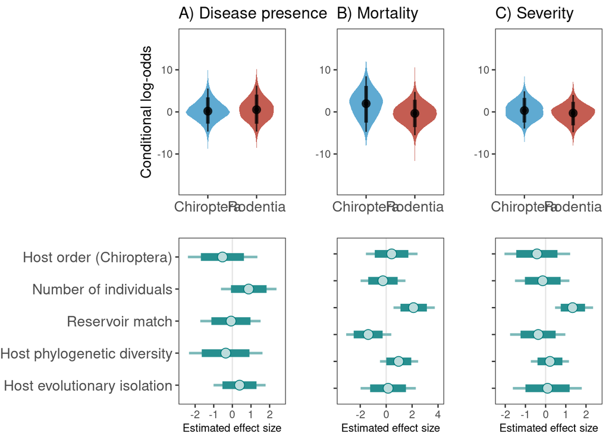

```r
## Joint plot
global_ylim <-  scale_y_continuous(lim=c(-18,18))
padding <- theme(plot.margin = unit(c(t=0, r=-3, b=0, l=0), "cm"))

joint_plot <- joint_conditionals_intervals(p1,p2,p3,global_ylim,padding,ar1,ar2,ar3)
```

```r
ggsave("../plots_tables/spec_level_conditionals_intervals_resMatch_inter.pdf", joint_plot, width=10.5, height=5.5)
```

## Species level models (excluding Lyssaviruses)

### Presence of disease (excluding Lyssaviruses)

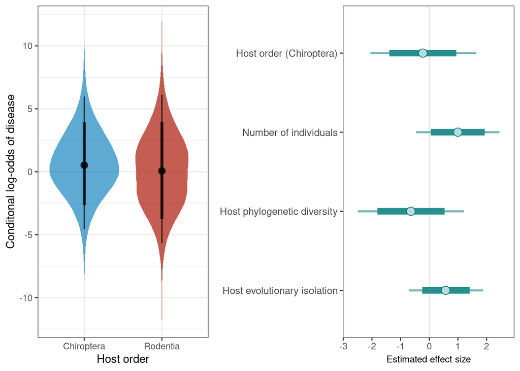

```r
lyssaviruses <- viruses$Virus_ICTV[viruses$genus=="Lyssavirus"] %>% unique()
spec_nolys <- spec[!spec$Virus_ICTV%in%lyssaviruses,]

if (!file.exists("../fit_models/spec_disease_nolys.rds")) {

  spec_disease_nolys <- brm(Disease_YN ~ Host_order + n_individuals +
                      ses_pd + EvoIso +
                      (1|PaperID) +
                      (1|Host_name) + (1|Virus_name) +
                      (1|Host_Upham) + (1|Virus_ICTV),
    data=spec_nolys, family=bernoulli(link = "logit"),
    prior=custom_prior,
    iter=5000, thin=1, cov_ranef = list(Host_Upham = host_cov, Virus_ICTV=virus_cov),
    control=list(adapt_delta=0.90, max_treedepth=12), cores=4,
    save_pars=save_pars(all=TRUE))

  saveRDS(spec_disease_nolys, "../fit_models/spec_disease_nolys.rds")

} else { spec_disease_nolys <- readRDS("../fit_models/spec_disease_nolys.rds")}

model <- spec_disease_nolys
# summary(model, prob=0.9)

# # save memory
rm(spec_disease_nolys)

# # pp <- brms::posterior_predict(model)
# # ppc_dens_overlay(y=model$data$Disease_YN, pp[1:500, ])

# param_tab(model)

p1 <- cond_eff_plot(model) + scale_y_continuous(lim=c(-12,12)) + ylab("Conditonal log-odds of disease") +
      scale_x_discrete(limits = c("Chiroptera","Rodentia"))

ar1 <- intervals_plot(model)

plot_grid(p1, ar1, align="h", rel_widths =c(0.7,1))
```

```r
# ggsave("../plots_tables/species_level_disease_nolys.pdf", width=8, height=3)
```

Sample size: 148

### Mortality (excluding Lyssaviruses)

```r
if (!file.exists("../fit_models/spec_mort_nolys.rds")) {

  spec_mort_nolys <- brm(Mortality_YN ~ Host_order + n_individuals +
                      ses_pd + EvoIso +
                      (1|PaperID) +
                      (1|Host_name) + (1|Virus_name) +
                      (1|Host_Upham) + (1|Virus_ICTV),
    data=spec_nolys, family=bernoulli(link = "logit"),
    prior=custom_prior,
    iter=5000, thin=1, cov_ranef = list(Host_Upham = host_cov, Virus_ICTV=virus_cov),
    control=list(adapt_delta=0.90, max_treedepth=12), cores=4,
    save_pars=save_pars(all=TRUE))

  saveRDS(spec_mort_nolys, "../fit_models/spec_mort_nolys.rds")

} else { spec_mort_nolys <- readRDS("../fit_models/spec_mort_nolys.rds")}

model <- spec_mort_nolys
# summary(model, prob=0.9)

# save memory
rm(spec_mort_nolys)

# pp <- brms::posterior_predict(model)
# ppc_dens_overlay(y=model$data$Mortality_YN, pp[1:500, ])

param_tab(model)
```

| Parameter | Effects | Mean | CI | CI_low | CI_high | Rhat | Group |
| --- | --- | --- | --- | --- | --- | --- | --- |
| b_Intercept | fixed | 0.14 | 0.90 | -0.93 | 1.25 | 1.00 |  |
| b_Host_orderChiroptera | fixed | -0.11 | 0.90 | -1.67 | 1.46 | 1.00 |  |
| b_n_individuals | fixed | 1.81 | 0.90 | 0.41 | 3.23 | 1.00 |  |
| b_ses_pd | fixed | -1.62 | 0.90 | -3.17 | -0.10 | 1.00 |  |
| b_EvoIso | fixed | 1.36 | 0.90 | 0.17 | 2.60 | 1.00 |  |
| sd_Host_name__Intercept | random | 0.67 | 0.90 | 0.06 | 1.56 | 1.00 | Host_name |
| sd_Host_Upham__Intercept | random | 0.76 | 0.90 | 0.06 | 1.75 | 1.00 | Host_Upham |
| sd_PaperID__Intercept | random | 1.44 | 0.90 | 0.54 | 2.37 | 1.00 | PaperID |
| sd_Virus_ICTV__Intercept | random | 0.66 | 0.90 | 0.05 | 1.70 | 1.00 | Virus_ICTV |
| sd_Virus_name__Intercept | random | 0.75 | 0.90 | 0.06 | 1.76 | 1.00 | Virus_name |

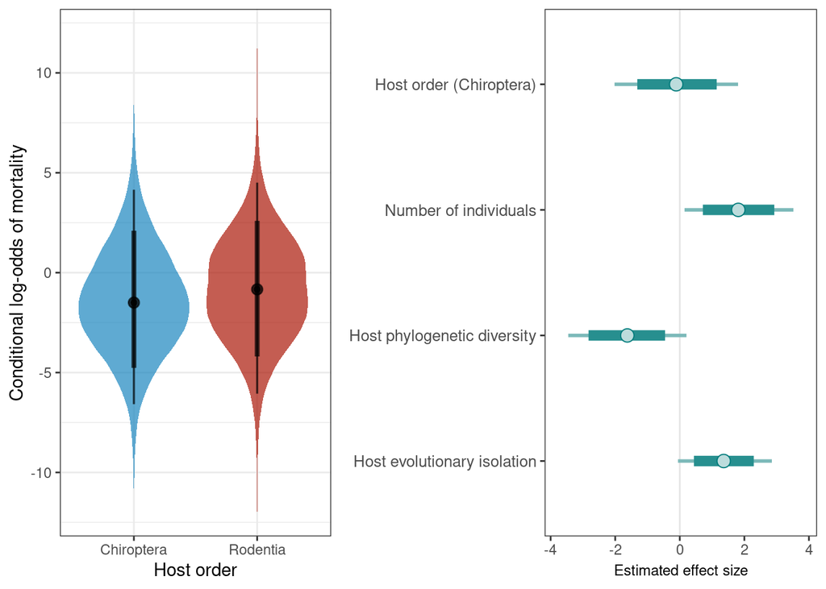

```r
p2 <- cond_eff_plot(model) + scale_y_continuous(lim=c(-12,12)) + ylab("Conditional log-odds of mortality") +
      scale_x_discrete(limits = c("Chiroptera","Rodentia"))

ar2 <- intervals_plot(model)

plot_grid(p2, ar2, align="h", rel_widths =c(0.7,1))
```

```r
# ggsave("../plots_tables/species_level_mortality_nolys_comboplot.pdf", width=8, height=3)
```

Sample size: 113

### Severity (excluding Lyssaviruses)

```r
if (!file.exists("../fit_models/spec_severity_nolys.rds")) {

  spec_severity_nolys <- brm(severity_rank ~ Host_order + n_individuals +
                      ses_pd + EvoIso +
                      (1|PaperID) +
                      (1|Host_name) + (1|Virus_name) +
                      (1|Host_Upham) + (1|Virus_ICTV),
    data=spec_nolys, family=cumulative(probit),
    prior=custom_prior,
    iter=5000, thin=1, cov_ranef = list(Host_Upham = host_cov, Virus_ICTV=virus_cov),
    control=list(adapt_delta=0.98, max_treedepth=12), cores=4,
    save_pars=save_pars(all=TRUE))

  saveRDS(spec_severity_nolys, "../fit_models/spec_severity_nolys.rds")

} else { spec_severity_nolys <- readRDS("../fit_models/spec_severity_nolys.rds")}

model <- spec_severity_nolys
# summary(model, prob=0.9)

# save memory
rm(spec_severity_nolys)

# pp <- brms::posterior_predict(model)
# ppc_dens_overlay(y=model$data$severity_rank, pp[1:500, ])

param_tab(model)
```

| Parameter | Effects | Mean | CI | CI_low | CI_high | Rhat | Group |
| --- | --- | --- | --- | --- | --- | --- | --- |
| b_Intercept[1] | fixed | -1.05 | 0.90 | -1.90 | -0.23 | 1.00 |  |
| b_Intercept[2] | fixed | -0.56 | 0.90 | -1.39 | 0.24 | 1.00 |  |
| b_Intercept[3] | fixed | -0.27 | 0.90 | -1.08 | 0.54 | 1.00 |  |
| b_Intercept[4] | fixed | 0.38 | 0.90 | -0.44 | 1.21 | 1.00 |  |
| b_Host_orderChiroptera | fixed | -0.40 | 0.90 | -1.69 | 0.92 | 1.00 |  |
| b_n_individuals | fixed | 1.12 | 0.90 | 0.36 | 1.92 | 1.00 |  |
| b_ses_pd | fixed | -1.06 | 0.90 | -2.17 | 0.03 | 1.00 |  |
| b_EvoIso | fixed | 0.47 | 0.90 | -0.22 | 1.19 | 1.00 |  |
| sd_Host_name__Intercept | random | 0.58 | 0.90 | 0.05 | 1.40 | 1.00 | Host_name |
| sd_Host_Upham__Intercept | random | 0.90 | 0.90 | 0.11 | 1.78 | 1.00 | Host_Upham |
| sd_PaperID__Intercept | random | 0.96 | 0.90 | 0.51 | 1.48 | 1.00 | PaperID |
| sd_Virus_ICTV__Intercept | random | 0.47 | 0.90 | 0.04 | 1.21 | 1.00 | Virus_ICTV |
| sd_Virus_name__Intercept | random | 0.87 | 0.90 | 0.17 | 1.55 | 1.00 | Virus_name |

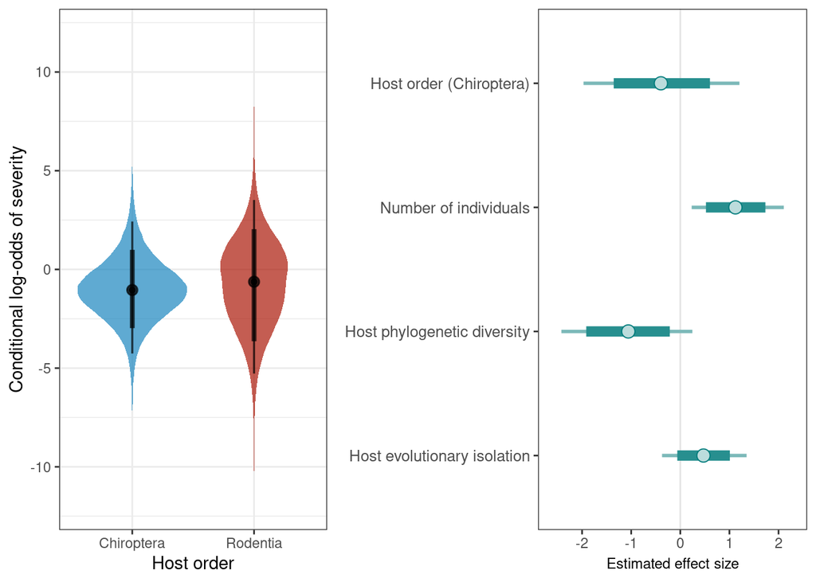

```r
p3 <- cond_eff_plot(model) + scale_y_continuous(lim=c(-12,12)) + ylab("Conditional log-odds of severity") +
      scale_x_discrete(limits = c("Chiroptera","Rodentia"))

ar3 <- intervals_plot(model)

plot_grid(p3, ar3, align="h", rel_widths =c(0.7,1))
```

```r
# ggsave("../plots_tables/species_level_severity_nolys_comboplot.pdf", width=8, height=3)
```

Sample size: 148

### Joint results plots (excluding Lyssaviruses)

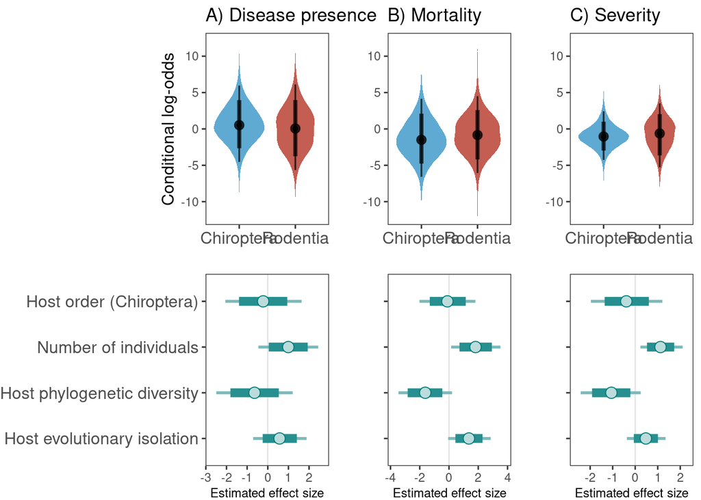

```r
## Joint plot
global_ylim <-  scale_y_continuous(lim=c(-12,12))
padding <- theme(plot.margin = unit(c(t=0, r=-3, b=0, l=0), "cm"))

joint_plot <- joint_conditionals_intervals(p1,p2,p3,global_ylim,padding,ar1,ar2,ar3)
```

```r
ggsave("../plots_tables/species_level_conditionals_intervals_nolys.pdf", joint_plot, width=10.5, height=5.5)
```

## Species level models (only heterologous hosts)

### Presence of disease (heterologous hosts)

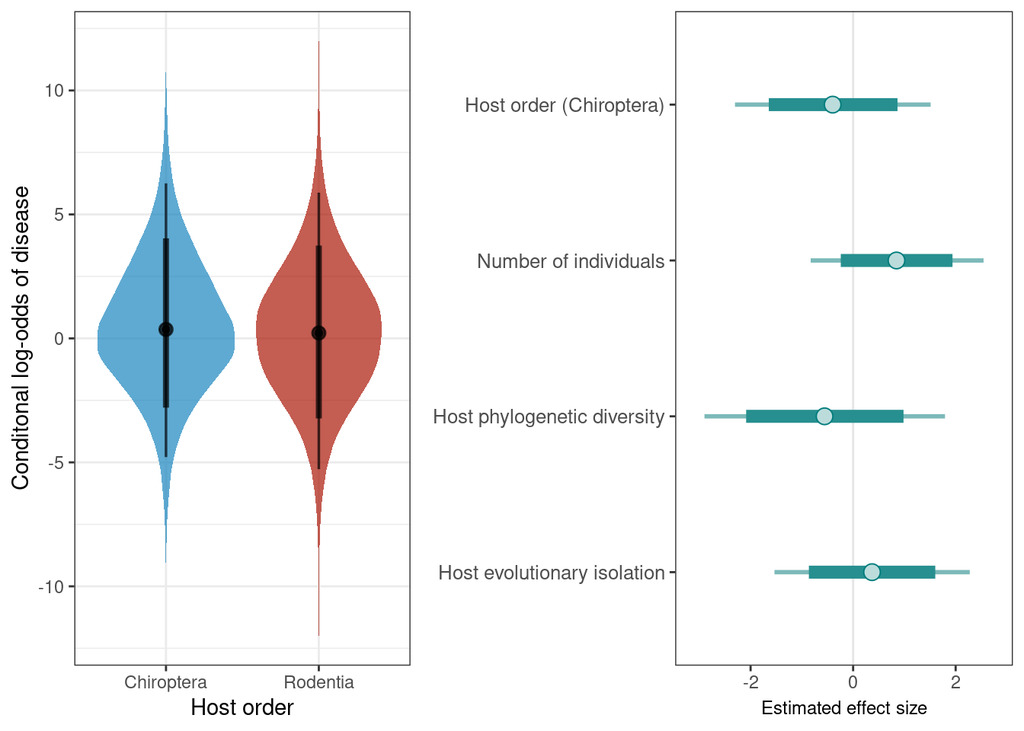

```r
spec_heteros <- spec[spec$Reservoir_match%in%0,]

if (!file.exists("../fit_models/spec_disease_heteroHosts.rds")) {

  spec_disease_heteros <- brm(Disease_YN ~ Host_order + n_individuals +
                      ses_pd + EvoIso +
                      (1|PaperID) +
                      (1|Host_name) + (1|Virus_name) +
                      (1|Host_Upham) + (1|Virus_ICTV),
    data=spec_heteros, family=bernoulli(link = "logit"),
    prior=custom_prior,
    iter=5000, thin=1, cov_ranef = list(Host_Upham = host_cov, Virus_ICTV=virus_cov),
    control=list(adapt_delta=0.90, max_treedepth=10), cores=4,
    save_pars=save_pars(all=TRUE))

  saveRDS(spec_disease_heteros, "../fit_models/spec_disease_heteroHosts.rds")

} else { spec_disease_heteros <- readRDS("../fit_models/spec_disease_heteroHosts.rds")}

model <- spec_disease_heteros
# summary(model, prob=0.9)

# # save memory
rm(spec_disease_heteros)

# pp <- brms::posterior_predict(model)
# ppc_dens_overlay(y=model$data$Disease_YN, pp[1:500, ])

# param_tab(model)

p1 <- cond_eff_plot(model) + scale_y_continuous(lim=c(-12,12)) + ylab("Conditonal log-odds of disease") +
      scale_x_discrete(limits = c("Chiroptera","Rodentia"))

ar1 <- intervals_plot(model)

plot_grid(p1, ar1, align="h", rel_widths =c(0.7,1))
```

```r
# ggsave("../plots_tables/species_level_disease_heteroHosts_comboplot.pdf", width=8, height=3)
```

Sample size: 81

### Mortality (heterologous hosts)

```r
if (!file.exists("../fit_models/spec_mort_heteroHosts.rds")) {

  spec_mort_heteros <- brm(Mortality_YN ~ Host_order + n_individuals +
                      ses_pd + EvoIso +
                      (1|PaperID) +
                      (1|Host_name) + (1|Virus_name) +
                      (1|Host_Upham) + (1|Virus_ICTV),
    data=spec_heteros, family=bernoulli(link = "logit"),
    prior=custom_prior,
    iter=5000, thin=1, cov_ranef = list(Host_Upham = host_cov, Virus_ICTV=virus_cov),
    control=list(adapt_delta=0.90, max_treedepth=10), cores=4,
    save_pars=save_pars(all=TRUE))

  saveRDS(spec_mort_heteros, "../fit_models/spec_mort_heteroHosts.rds")

} else { spec_mort_heteros <- readRDS("../fit_models/spec_mort_heteroHosts.rds")}

model <- spec_mort_heteros
# summary(model, prob=0.9)

# save memory
rm(spec_mort_heteros)

# pp <- brms::posterior_predict(model)
# ppc_dens_overlay(y=model$data$Mortality_YN, pp[1:500, ])

param_tab(model)
```

| Parameter | Effects | Mean | CI | CI_low | CI_high | Rhat | Group |
| --- | --- | --- | --- | --- | --- | --- | --- |
| b_Intercept | fixed | 0.36 | 0.90 | -0.93 | 1.63 | 1.00 |  |
| b_Host_orderChiroptera | fixed | 0.20 | 0.90 | -1.48 | 1.88 | 1.00 |  |
| b_n_individuals | fixed | 1.98 | 0.90 | 0.42 | 3.55 | 1.00 |  |
| b_ses_pd | fixed | -0.85 | 0.90 | -2.74 | 1.02 | 1.00 |  |
| b_EvoIso | fixed | 0.29 | 0.90 | -1.24 | 1.83 | 1.00 |  |
| sd_Host_name__Intercept | random | 0.94 | 0.90 | 0.08 | 2.14 | 1.00 | Host_name |
| sd_Host_Upham__Intercept | random | 0.71 | 0.90 | 0.05 | 1.72 | 1.00 | Host_Upham |
| sd_PaperID__Intercept | random | 0.96 | 0.90 | 0.09 | 2.10 | 1.00 | PaperID |
| sd_Virus_ICTV__Intercept | random | 0.64 | 0.90 | 0.05 | 1.63 | 1.00 | Virus_ICTV |
| sd_Virus_name__Intercept | random | 0.92 | 0.90 | 0.09 | 2.04 | 1.00 | Virus_name |

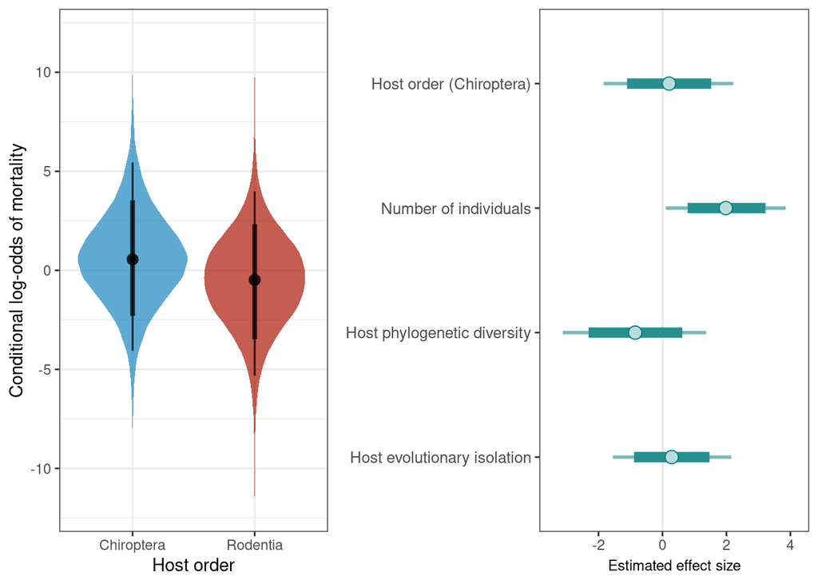

```r
p2 <- cond_eff_plot(model) + scale_y_continuous(lim=c(-12,12)) + ylab("Conditional log-odds of mortality") +
      scale_x_discrete(limits = c("Chiroptera","Rodentia"))

ar2 <- intervals_plot(model)

plot_grid(p2, ar2, align="h", rel_widths =c(0.7,1))
```

```r
# ggsave("../plots_tables/species_level_mortality_heteroHosts_comboplot.pdf", width=8, height=3)
```

Sample size: 61

### Severity (heterologous hosts)

```r
if (!file.exists("../fit_models/spec_severity_heteroHosts.rds")) {

  spec_severity_heteros <- brm(severity_rank ~ Host_order + n_individuals +
                      ses_pd + EvoIso +
                      (1|PaperID) +
                      (1|Host_name) + (1|Virus_name) +
                      (1|Host_Upham) + (1|Virus_ICTV),
    data=spec_heteros, family=cumulative(probit),
    prior=custom_prior,
    iter=5000, thin=1, cov_ranef = list(Host_Upham = host_cov, Virus_ICTV=virus_cov),
    control=list(adapt_delta=0.90, max_treedepth=10), cores=4,
    save_pars=save_pars(all=TRUE))

  saveRDS(spec_severity_heteros, "../fit_models/spec_severity_heteroHosts.rds")

} else { spec_severity_heteros <- readRDS("../fit_models/spec_severity_heteroHosts.rds")}

# pairs(spec_severity_heteros)
model <- spec_severity_heteros
# summary(model, prob=0.9)

# save memory
rm(spec_severity_heteros)

# pp <- brms::posterior_predict(model)
# ppc_dens_overlay(y=model$data$severity_rank, pp[1:500, ])

param_tab(model)
```

| Parameter | Effects | Mean | CI | CI_low | CI_high | Rhat | Group |
| --- | --- | --- | --- | --- | --- | --- | --- |
| b_Intercept[1] | fixed | -1.12 | 0.90 | -2.16 | -0.12 | 1.00 |  |
| b_Intercept[2] | fixed | -0.97 | 0.90 | -2.00 | 0.01 | 1.00 |  |
| b_Intercept[3] | fixed | -0.53 | 0.90 | -1.53 | 0.46 | 1.00 |  |
| b_Intercept[4] | fixed | 0.28 | 0.90 | -0.72 | 1.29 | 1.00 |  |
| b_Host_orderChiroptera | fixed | -0.39 | 0.90 | -1.76 | 0.98 | 1.00 |  |
| b_n_individuals | fixed | 1.52 | 0.90 | 0.40 | 2.74 | 1.00 |  |
| b_ses_pd | fixed | -1.05 | 0.90 | -2.77 | 0.64 | 1.00 |  |
| b_EvoIso | fixed | 0.08 | 0.90 | -1.20 | 1.40 | 1.00 |  |
| sd_Host_name__Intercept | random | 1.44 | 0.90 | 0.44 | 2.42 | 1.00 | Host_name |
| sd_Host_Upham__Intercept | random | 0.57 | 0.90 | 0.05 | 1.42 | 1.00 | Host_Upham |
| sd_PaperID__Intercept | random | 0.63 | 0.90 | 0.06 | 1.38 | 1.00 | PaperID |
| sd_Virus_ICTV__Intercept | random | 0.71 | 0.90 | 0.05 | 1.79 | 1.00 | Virus_ICTV |
| sd_Virus_name__Intercept | random | 1.34 | 0.90 | 0.38 | 2.31 | 1.00 | Virus_name |

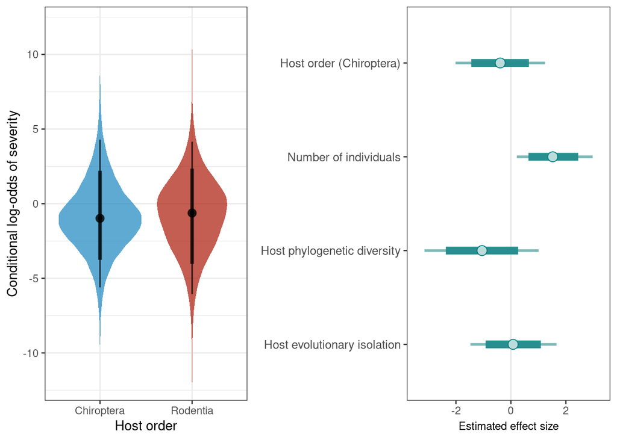

```r
p3 <- cond_eff_plot(model) + scale_y_continuous(lim=c(-12,12)) + ylab("Conditional log-odds of severity") +
      scale_x_discrete(limits = c("Chiroptera","Rodentia"))

ar3 <- intervals_plot(model)

plot_grid(p3, ar3, align="h", rel_widths =c(0.7,1))
```

```r
# ggsave("../plots_tables/species_level_severity_heteroHosts_comboplot.pdf", width=8, height=3)
```

Sample size: 81

### Joint results plots (heterologous hosts)

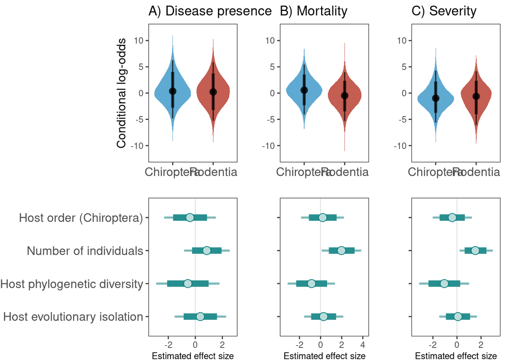

```r
## Joint plot
global_ylim <-  scale_y_continuous(lim=c(-12,12))
padding <- theme(plot.margin = unit(c(t=0, r=-3, b=0, l=0), "cm"))

joint_plot <- joint_conditionals_intervals(p1,p2,p3,global_ylim,padding,ar1,ar2,ar3)
```

```r
ggsave("../plots_tables/species_level_conditionals_intervals_heteroHosts.pdf", joint_plot, width=10.5, height=5.5)
```

Sample size: 81

## Species level models (only homologous hosts)

### Presence of disease (homologous hosts)

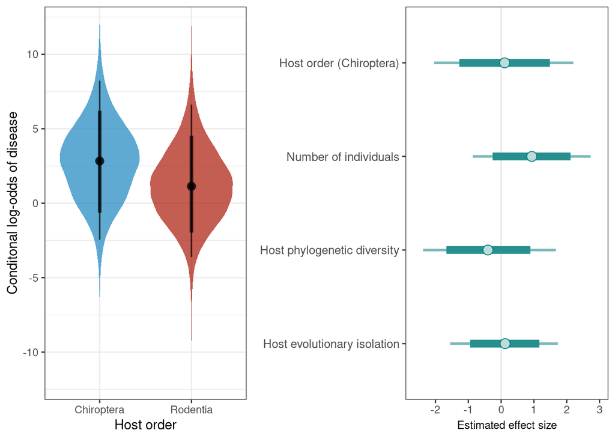

```r
spec_homos <- spec[spec$Reservoir_match%in%1,]

if (!file.exists("../fit_models/spec_disease_homoHosts.rds")) {

  spec_disease_homos <- brm(Disease_YN ~ Host_order + n_individuals +
                      ses_pd + EvoIso +
                      (1|PaperID) +
                      (1|Host_name) + (1|Virus_name) +
                      (1|Host_Upham) + (1|Virus_ICTV),
    data=spec_homos, family=bernoulli(link = "logit"),
    prior=custom_prior,
    iter=5000, thin=1, cov_ranef = list(Host_Upham = host_cov, Virus_ICTV=virus_cov),
    control=list(adapt_delta=0.90, max_treedepth=10), cores=4,
    save_pars=save_pars(all=TRUE))

  saveRDS(spec_disease_homos, "../fit_models/spec_disease_homoHosts.rds")

} else { spec_disease_homos <- readRDS("../fit_models/spec_disease_homoHosts.rds")}

model <- spec_disease_homos
# summary(model, prob=0.9)

# # save memory
rm(spec_disease_homos)

# pp <- brms::posterior_predict(model)
# ppc_dens_overlay(y=model$data$Disease_YN, pp[1:500, ])

# param_tab(model)

p1 <- cond_eff_plot(model) + scale_y_continuous(lim=c(-12,12)) + ylab("Conditonal log-odds of disease") +
      scale_x_discrete(limits = c("Chiroptera","Rodentia"))

ar1 <- intervals_plot(model)

plot_grid(p1, ar1, align="h", rel_widths =c(0.7,1))
```

```r
# ggsave("../plots_tables/species_level_disease_homoHosts_comboplot.pdf", width=8, height=3)
```

Sample size: 95

### Mortality (homologous hosts)

```r
if (!file.exists("../fit_models/spec_mort_homoHosts.rds")) {

  spec_mort_homos <- brm(Mortality_YN ~ Host_order + n_individuals +
                      ses_pd + EvoIso +
                      (1|PaperID) +
                      (1|Host_name) + (1|Virus_name) +
                      (1|Host_Upham) + (1|Virus_ICTV),
    data=spec_homos, family=bernoulli(link = "logit"),
    prior=custom_prior,
    iter=5000, thin=1, cov_ranef = list(Host_Upham = host_cov, Virus_ICTV=virus_cov),
    control=list(adapt_delta=0.90, max_treedepth=10), cores=4,
    save_pars=save_pars(all=TRUE))

  saveRDS(spec_mort_homos, "../fit_models/spec_mort_homoHosts.rds")

} else { spec_mort_homos <- readRDS("../fit_models/spec_mort_homoHosts.rds")}

model <- spec_mort_homos
# summary(model, prob=0.9)

# save memory
rm(spec_mort_homos)

# pp <- brms::posterior_predict(model)
# ppc_dens_overlay(y=model$data$Mortality_YN, pp[1:500, ])

param_tab(model)
```

| Parameter | Effects | Mean | CI | CI_low | CI_high | Rhat | Group |
| --- | --- | --- | --- | --- | --- | --- | --- |
| b_Intercept | fixed | -0.19 | 0.90 | -1.81 | 1.40 | 1.00 |  |
| b_Host_orderChiroptera | fixed | 0.45 | 0.90 | -1.42 | 2.28 | 1.00 |  |
| b_n_individuals | fixed | 1.35 | 0.90 | -0.25 | 2.98 | 1.00 |  |
| b_ses_pd | fixed | -1.26 | 0.90 | -2.91 | 0.42 | 1.00 |  |
| b_EvoIso | fixed | 1.21 | 0.90 | -0.32 | 2.77 | 1.00 |  |
| sd_Host_name__Intercept | random | 0.78 | 0.90 | 0.06 | 1.86 | 1.00 | Host_name |
| sd_Host_Upham__Intercept | random | 0.96 | 0.90 | 0.10 | 2.09 | 1.00 | Host_Upham |
| sd_PaperID__Intercept | random | 1.17 | 0.90 | 0.20 | 2.20 | 1.00 | PaperID |
| sd_Virus_ICTV__Intercept | random | 1.06 | 0.90 | 0.10 | 2.32 | 1.00 | Virus_ICTV |
| sd_Virus_name__Intercept | random | 0.93 | 0.90 | 0.07 | 2.14 | 1.00 | Virus_name |

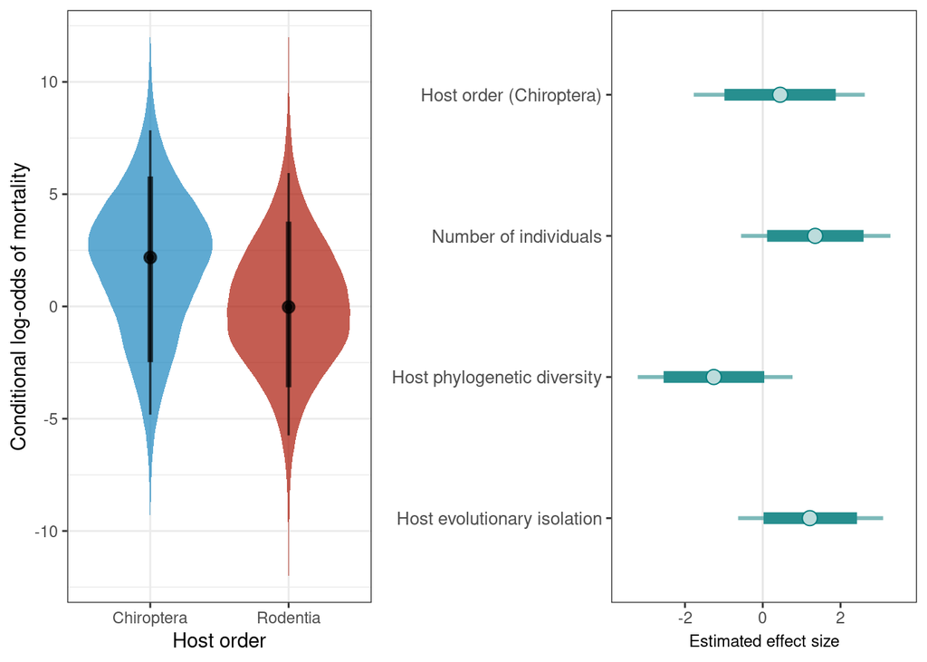

```r
p2 <- cond_eff_plot(model) + scale_y_continuous(lim=c(-12,12)) + ylab("Conditional log-odds of mortality") +
      scale_x_discrete(limits = c("Chiroptera","Rodentia"))

ar2 <- intervals_plot(model)

plot_grid(p2, ar2, align="h", rel_widths =c(0.7,1))
```

```r
# ggsave("../plots_tables/species_level_mortality_homoHosts_comboplot.pdf", width=8, height=3)
```

Sample size: 78

### Severity (homologous hosts)

```r
if (!file.exists("../fit_models/spec_severity_homoHosts.rds")) {

  spec_severity_homos <- brm(severity_rank ~ Host_order + n_individuals +
                      ses_pd + EvoIso +
                      (1|PaperID) +
                      (1|Host_name) + (1|Virus_name) +
                      (1|Host_Upham) + (1|Virus_ICTV),
    data=spec_homos, family=cumulative(probit),
    prior=custom_prior,
    iter=5000, thin=1, cov_ranef = list(Host_Upham = host_cov, Virus_ICTV=virus_cov),
    control=list(adapt_delta=0.92, max_treedepth=10), cores=4,
    save_pars=save_pars(all=TRUE))

  saveRDS(spec_severity_homos, "../fit_models/spec_severity_homoHosts.rds")

} else { spec_severity_homos <- readRDS("../fit_models/spec_severity_homoHosts.rds")}

# pairs(spec_severity_homos)
model <- spec_severity_homos
# summary(model, prob=0.9)

# save memory
rm(spec_severity_homos)

# pp <- brms::posterior_predict(model)
# ppc_dens_overlay(y=model$data$severity_rank, pp[1:500, ])

param_tab(model)
```

| Parameter | Effects | Mean | CI | CI_low | CI_high | Rhat | Group |
| --- | --- | --- | --- | --- | --- | --- | --- |
| b_Intercept[1] | fixed | -1.21 | 0.90 | -2.69 | 0.24 | 1.00 |  |
| b_Intercept[2] | fixed | -0.34 | 0.90 | -1.76 | 1.09 | 1.00 |  |
| b_Intercept[3] | fixed | 0.05 | 0.90 | -1.35 | 1.49 | 1.00 |  |
| b_Intercept[4] | fixed | 1.15 | 0.90 | -0.31 | 2.64 | 1.00 |  |
| b_Host_orderChiroptera | fixed | -0.13 | 0.90 | -1.83 | 1.60 | 1.00 |  |
| b_n_individuals | fixed | 1.42 | 0.90 | 0.31 | 2.63 | 1.00 |  |
| b_ses_pd | fixed | -0.23 | 0.90 | -1.65 | 1.19 | 1.00 |  |
| b_EvoIso | fixed | 0.46 | 0.90 | -0.73 | 1.68 | 1.00 |  |
| sd_Host_name__Intercept | random | 1.16 | 0.90 | 0.13 | 2.34 | 1.00 | Host_name |
| sd_Host_Upham__Intercept | random | 0.94 | 0.90 | 0.09 | 2.08 | 1.00 | Host_Upham |
| sd_PaperID__Intercept | random | 1.27 | 0.90 | 0.55 | 2.06 | 1.00 | PaperID |
| sd_Virus_ICTV__Intercept | random | 1.43 | 0.90 | 0.26 | 2.59 | 1.00 | Virus_ICTV |
| sd_Virus_name__Intercept | random | 0.84 | 0.90 | 0.07 | 1.96 | 1.00 | Virus_name |

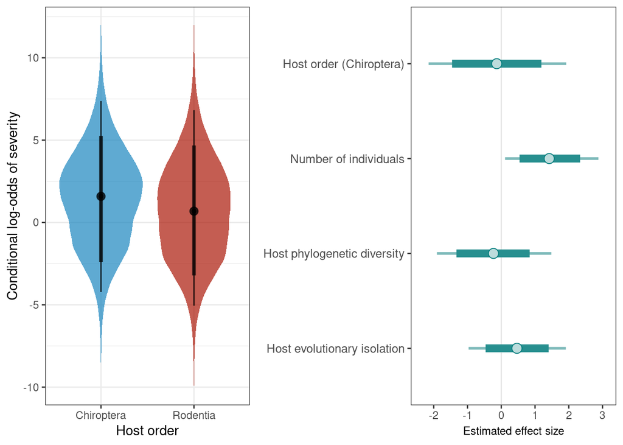

```r
p3 <- cond_eff_plot(model) + scale_y_continuous(lim=c(-10,12)) + ylab("Conditional log-odds of severity") +
      scale_x_discrete(limits = c("Chiroptera","Rodentia"))

ar3 <- intervals_plot(model)

plot_grid(p3, ar3, align="h", rel_widths =c(0.7,1))
```

```r
# ggsave("../plots_tables/species_level_severity_homoHosts_comboplot.pdf", width=8, height=3)
```

Sample size: 95

### Joint results plots (homologous hosts)

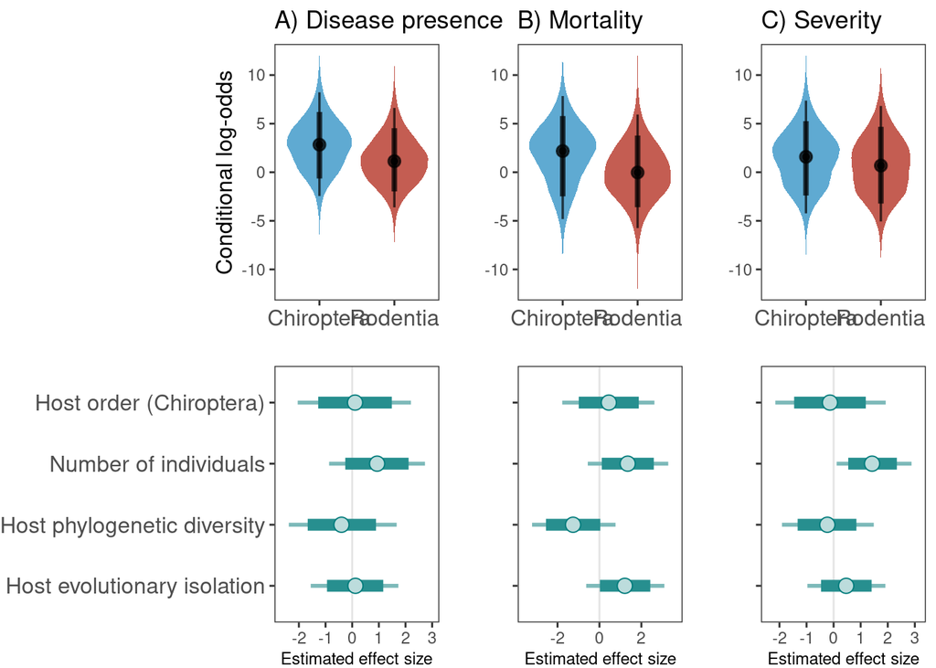

```r
## Joint plot
global_ylim <-  scale_y_continuous(lim=c(-12,12))
padding <- theme(plot.margin = unit(c(t=0, r=-3, b=0, l=0), "cm"))

joint_plot <- joint_conditionals_intervals(p1,p2,p3,global_ylim,padding,ar1,ar2,ar3)
```

```r
ggsave("../plots_tables/species_level_conditionals_intervals_homoHosts.pdf", joint_plot, width=10.5, height=5.5)
```

Sample size: 95

# Individual level models

## Modelling dose differences between bats and rodents

| Parameter | Effects | Component | Mean | CI | CI_low | CI_high | Rhat | Group |
| --- | --- | --- | --- | --- | --- | --- | --- | --- |
| b_Intercept | fixed | conditional | 1.87 | 0.90 | -0.06 | 3.71 | 1.00 |  |
| b_Host_orderChiroptera | fixed | conditional | 0.25 | 0.90 | -1.65 | 2.12 | 1.00 |  |
| sd_Dose_unit__Intercept | random | conditional | 0.99 | 0.90 | 0.09 | 2.23 | 1.00 | Dose_unit |
| sd_Host_name__Intercept | random | conditional | 0.58 | 0.90 | 0.07 | 1.14 | 1.00 | Host_name |
| sd_Host_Upham__Intercept | random | conditional | 1.85 | 0.90 | 1.15 | 2.54 | 1.00 | Host_Upham |
| sd_PaperID__Intercept | random | conditional | 2.58 | 0.90 | 2.16 | 3.05 | 1.00 | PaperID |
| sd_Route_type__Intercept | random | conditional | 1.34 | 0.90 | 0.75 | 2.20 | 1.00 | Route_type |
| sd_Virus_ICTV__Intercept | random | conditional | 0.82 | 0.90 | 0.07 | 1.89 | 1.00 | Virus_ICTV |
| sd_Virus_name__Intercept | random | conditional | 0.89 | 0.90 | 0.31 | 1.52 | 1.00 | Virus_name |
| sigma | fixed | sigma | 1.42 | 0.90 | 1.39 | 1.46 | 1.00 |  |

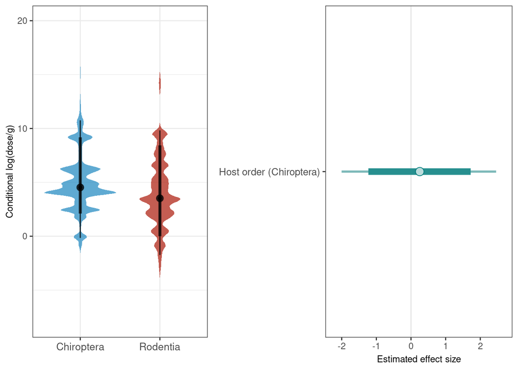

| Parameter | Effects | Component | Mean | CI | CI_low | CI_high | Rhat | Group |
| --- | --- | --- | --- | --- | --- | --- | --- | --- |
| b_Intercept | fixed | conditional | 2.52 | 0.90 | 0.61 | 4.46 | 1.00 |  |
| b_Host_orderChiroptera | fixed | conditional | -0.33 | 0.90 | -1.80 | 1.00 | 1.00 |  |
| b_adult_mass_g | fixed | conditional | 0.19 | 0.90 | -0.51 | 0.91 | 1.00 |  |
| sd_Dose_unit__Intercept | random | conditional | 2.51 | 0.90 | 1.30 | 3.85 | 1.00 | Dose_unit |
| sd_Host_name__Intercept | random | conditional | 1.96 | 0.90 | 1.56 | 2.37 | 1.00 | Host_name |
| sd_Host_Upham__Intercept | random | conditional | 0.79 | 0.90 | 0.06 | 2.09 | 1.01 | Host_Upham |
| sd_Route_type__Intercept | random | conditional | 1.55 | 0.90 | 0.85 | 2.62 | 1.00 | Route_type |
| sd_Virus_ICTV__Intercept | random | conditional | 2.33 | 0.90 | 0.86 | 3.74 | 1.00 | Virus_ICTV |
| sd_Virus_name__Intercept | random | conditional | 2.09 | 0.90 | 1.49 | 2.71 | 1.00 | Virus_name |
| sigma | fixed | sigma | 1.80 | 0.90 | 1.75 | 1.85 | 1.00 |  |

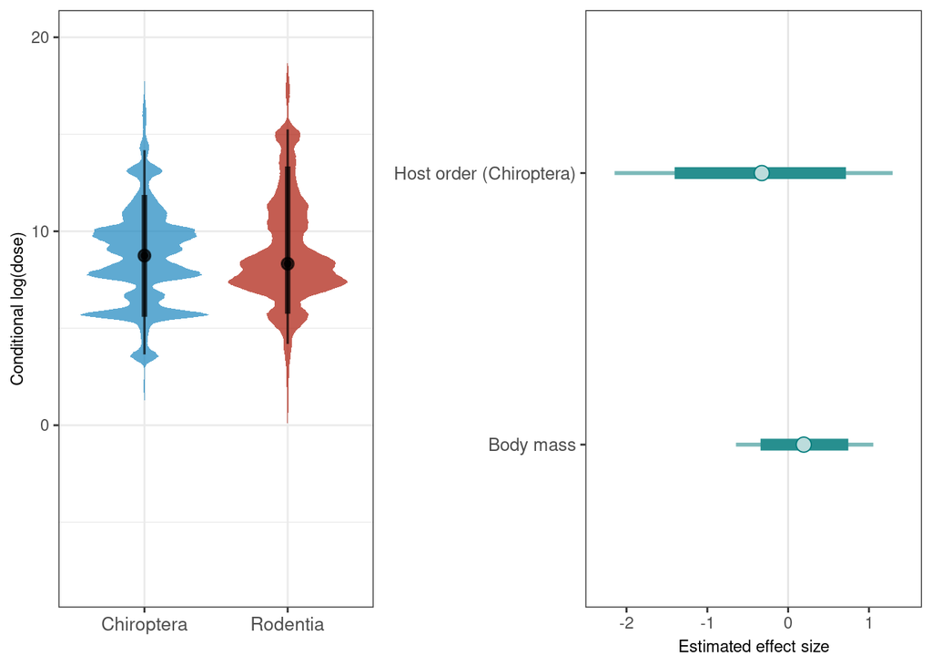

| Parameter | Effects | Component | Mean | CI | CI_low | CI_high | Rhat | Group |
| --- | --- | --- | --- | --- | --- | --- | --- | --- |
| b_Intercept | fixed | conditional | 3.01 | 0.90 | 0.93 | 5.13 | 1.00 |  |
| b_Host_orderChiroptera | fixed | conditional | -0.44 | 0.90 | -2.18 | 1.24 | 1.00 |  |
| sd_Dose_unit__Intercept | random | conditional | 1.94 | 0.90 | 0.26 | 3.64 | 1.00 | Dose_unit |
| sd_Host_name__Intercept | random | conditional | 0.43 | 0.90 | 0.04 | 0.92 | 1.00 | Host_name |
| sd_Host_Upham__Intercept | random | conditional | 1.09 | 0.90 | 0.23 | 1.81 | 1.00 | Host_Upham |
| sd_PaperID__Intercept | random | conditional | 2.53 | 0.90 | 2.11 | 2.98 | 1.00 | PaperID |
| sd_Route_type__Intercept | random | conditional | 1.79 | 0.90 | 0.83 | 3.47 | 1.00 | Route_type |
| sd_Virus_ICTV__Intercept | random | conditional | 1.71 | 0.90 | 0.21 | 3.32 | 1.00 | Virus_ICTV |
| sd_Virus_name__Intercept | random | conditional | 0.81 | 0.90 | 0.10 | 1.54 | 1.00 | Virus_name |
| sigma | fixed | sigma | 1.42 | 0.90 | 1.39 | 1.46 | 1.00 |  |

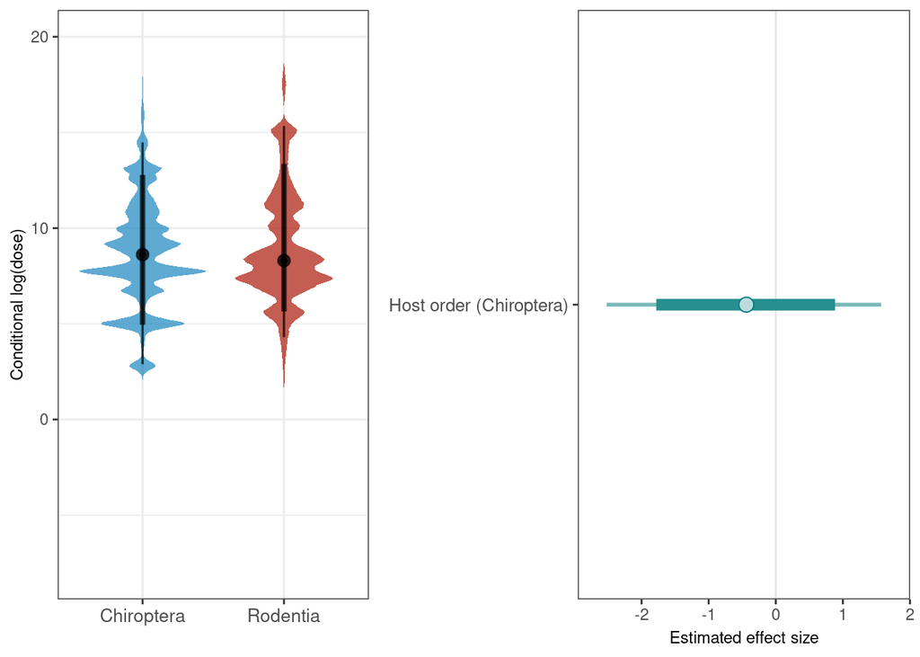

## Presence of disease

### Presence of disease - base model

```r
if (!file.exists("../fit_models/indiv_disease_base.rds")) {

  disease_m0 <- brm(Disease_YN ~ Host_order +
                      (1|PaperID),
    data=dat_dis, family=bernoulli(link = "logit"),
    prior=c(prior(normal(0, 1), class = Intercept),
                  prior(normal(0, 1.5), class = b)),
    iter=4000, thin=1,
    control=list(adapt_delta=0.8, max_treedepth=10), cores=4,
    save_pars=save_pars(all=TRUE))

  saveRDS(disease_m0, "../fit_models/indiv_disease_base.rds")

} else { disease_m0 <- readRDS("../fit_models/indiv_disease_base.rds")}

model <- disease_m0
# summary(model, prob=0.9)

# save memory
rm(disease_m0)

# pp <- brms::posterior_predict(model)
# ppc_dens_overlay(y=model$data$Disease_YN, pp[1:500, ])

param_tab(model)
```

| Parameter | Effects | Mean | CI | CI_low | CI_high | Rhat | Group |
| --- | --- | --- | --- | --- | --- | --- | --- |
| b_Intercept | fixed | 1.07 | 0.90 | -0.21 | 2.36 | 1.01 |  |
| b_Host_orderChiroptera | fixed | -0.09 | 0.90 | -1.61 | 1.40 | 1.01 |  |
| sd_PaperID__Intercept | random | 5.04 | 0.90 | 4.06 | 6.23 | 1.00 | PaperID |

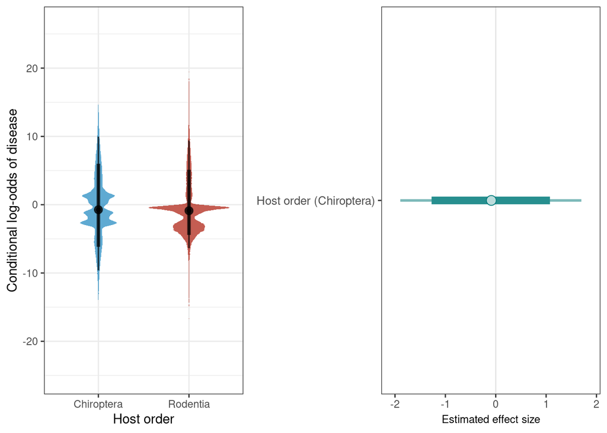

```r
p1 <- cond_eff_plot(model) + ylab("Conditional log-odds of disease") +
      scale_x_discrete(limits = c("Chiroptera","Rodentia"))
ar1 <- intervals_plot(model)

plot_grid(p1, ar1, align="h", rel_widths =c(0.7,1))
```

Sample size: 2444

### Presence of disease - base model + phylogenetic effects

```r
if (!file.exists("../fit_models/indiv_disease_base_phylo.rds")) {

  disease_m1 <- brm(Disease_YN ~ Host_order +
                    (1|PaperID) +
                    (1|Host_name) + (1|Virus_name) +
                    (1|Host_Upham) + (1|Virus_ICTV),
    data=dat_dis, family=bernoulli(link = "logit"),
    prior=custom_prior,
    iter=5000, thin=1, cov_ranef = list(Host_Upham = host_cov, Virus_ICTV=virus_cov),
    control=list(adapt_delta=0.99, max_treedepth=12), cores=4,
    save_pars=save_pars(all=TRUE))

  saveRDS(disease_m1, "../fit_models/indiv_disease_base_phylo.rds")

} else { disease_m1 <- readRDS("../fit_models/indiv_disease_base_phylo.rds")}

model <- disease_m1
# summary(model, prob=0.9)

# save memory
rm(disease_m1)

# pp <- brms::posterior_predict(model)
# ppc_dens_overlay(y=model$data$Disease_YN, pp[1:500, ])

param_tab(model)
```

| Parameter | Effects | Mean | CI | CI_low | CI_high | Rhat | Group |
| --- | --- | --- | --- | --- | --- | --- | --- |
| b_Intercept | fixed | 0.81 | 0.90 | -0.86 | 2.51 | 1.00 |  |
| b_Host_orderChiroptera | fixed | -0.45 | 0.90 | -2.19 | 1.28 | 1.00 |  |
| sd_Host_name__Intercept | random | 2.56 | 0.90 | 1.81 | 3.34 | 1.00 | Host_name |
| sd_Host_Upham__Intercept | random | 1.10 | 0.90 | 0.09 | 2.49 | 1.00 | Host_Upham |
| sd_PaperID__Intercept | random | 3.48 | 0.90 | 2.80 | 4.22 | 1.00 | PaperID |
| sd_Virus_ICTV__Intercept | random | 1.71 | 0.90 | 0.60 | 2.74 | 1.00 | Virus_ICTV |
| sd_Virus_name__Intercept | random | 0.81 | 0.90 | 0.07 | 1.94 | 1.00 | Virus_name |

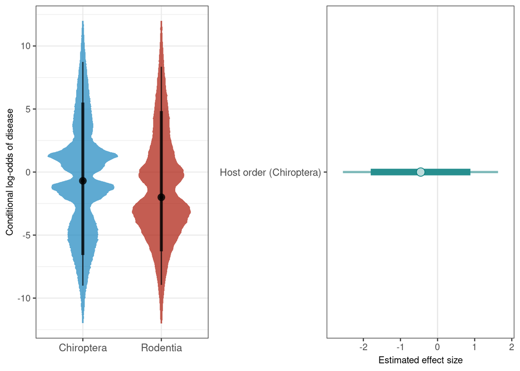

```r
p1 <- cond_eff_plot(model) + scale_y_continuous(lim=c(-12,12)) +
      ylab("Conditional log-odds of disease") + xlab("") +
      theme(axis.title=element_text(size=9),axis.text.x=element_text(size=10)) +
      scale_x_discrete(limits = c("Chiroptera","Rodentia"))
ar1 <- intervals_plot(model)

plot_grid(p1, ar1, align="h", rel_widths =c(0.7,1))
```

```r
# ggsave("../plots_tables/individual_level_disease_base_phylo_comboplot.pdf", width=8, height=3)
```

Sample size: 2444

### Presence of disease - Full model

Full model adjusts for evolutionary predictors, dose/g, and inoculation route

```r
if (!file.exists("../fit_models/indiv_disease_full.rds")) {

  disease_full <- brm(Disease_YN ~ Host_order +
                      ses_pd + EvoIso +
                       Dose_mass + (1|Dose_unit) +
                      (1|PaperID) +
                      (1|Host_name) + (1|Virus_name) +
                      (1|Host_Upham) + (1|Virus_ICTV) +
                      (1|Route_type),
    data=dat_dis, family=bernoulli(link = "logit"),
    prior=custom_prior,
    iter=5000, thin=1, cov_ranef = list(Host_Upham = host_cov, Virus_ICTV=virus_cov),
    control=list(adapt_delta=0.98, max_treedepth=12), cores=4,
    save_pars=save_pars(all=TRUE))

  saveRDS(disease_full, "../fit_models/indiv_disease_full.rds")

} else { disease_full <- readRDS("../fit_models/indiv_disease_full.rds")}

model <- disease_full
# summary(model, prob=0.9)

# save memory
rm(disease_full)

# pp <- brms::posterior_predict(model)
# ppc_dens_overlay(y=model$data$Disease_YN, pp[1:500, ])

param_tab(model)
```

| Parameter | Effects | Mean | CI | CI_low | CI_high | Rhat | Group |
| --- | --- | --- | --- | --- | --- | --- | --- |
| b_Intercept | fixed | 0.19 | 0.90 | -1.74 | 2.09 | 1.00 |  |
| b_Host_orderChiroptera | fixed | -0.41 | 0.90 | -2.27 | 1.45 | 1.00 |  |
| b_ses_pd | fixed | -0.93 | 0.90 | -2.41 | 0.56 | 1.00 |  |
| b_EvoIso | fixed | 0.17 | 0.90 | -1.08 | 1.43 | 1.00 |  |
| b_Dose_mass | fixed | 0.70 | 0.90 | 0.13 | 1.28 | 1.00 |  |
| sd_Dose_unit__Intercept | random | 1.23 | 0.90 | 0.14 | 2.51 | 1.00 | Dose_unit |
| sd_Host_name__Intercept | random | 2.70 | 0.90 | 2.00 | 3.45 | 1.00 | Host_name |
| sd_Host_Upham__Intercept | random | 0.83 | 0.90 | 0.07 | 2.06 | 1.00 | Host_Upham |
| sd_PaperID__Intercept | random | 3.53 | 0.90 | 2.74 | 4.38 | 1.00 | PaperID |
| sd_Route_type__Intercept | random | 1.87 | 0.90 | 1.21 | 2.67 | 1.00 | Route_type |
| sd_Virus_ICTV__Intercept | random | 1.07 | 0.90 | 0.09 | 2.36 | 1.00 | Virus_ICTV |
| sd_Virus_name__Intercept | random | 0.71 | 0.90 | 0.05 | 1.83 | 1.00 | Virus_name |

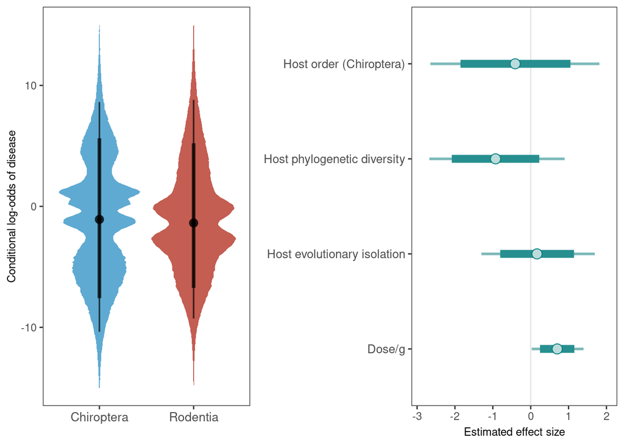

```r
p1 <- cond_eff_plot(model) + scale_y_continuous(lim=c(-15,15)) +
      ylab("Conditional log-odds of disease") + xlab("") +
      theme(axis.title=element_text(size=9),axis.text.x=element_text(size=10),
            panel.grid.major = element_blank(),
            panel.grid.minor = element_blank()) +
      scale_x_discrete(limits = c("Chiroptera","Rodentia"))

ar1 <- intervals_plot(model)

plot_grid(p1, ar1, align="h", rel_widths =c(0.7,1))
```

```r
# ggsave("../plots_tables/individual_level_disease_full_comboplot.pdf", width=8, height=3)
```

Sample size: 1999

## Mortality - Full model

```r
dat_mort <- dat
dat_mort <- dat_mort[dat_mort$Susceptible_YN==1,]
dat_mort <- dat_mort[!is.na(dat_mort$Susceptible_YN),]

dat_mort <- dat_mort[!is.na(dat_mort$Mortality_YN),]

dat_mort$ses_pd <- scale_half(dat_mort$ses_pd)
dat_mort$EvoIso <- scale_half(dat_mort$EvoIso)
dat_mort$adult_mass_g <- scale_half(log(dat_mort$adult_mass_g))

dat_mort <- dat_mort %>% group_by(Dose_unit) %>% mutate(Dose_mass = scale_half(log(Dose_mass)))
dat_mort <- dat_mort %>% group_by(Dose_unit) %>% mutate(Dose_amount = scale_half(log(Dose_amount)))

dat_mort$Host_name <- dat_mort$Host_Upham
dat_mort$Virus_name <- dat_mort$Virus_ICTV
```

```r
if (!file.exists("../fit_models/indiv_mort_full.rds")) {

  mort_full <- brm(Mortality_YN ~ Host_order +
                      ses_pd + EvoIso +
                       Dose_mass + (1|Dose_unit) +
                      (1|PaperID) +
                      (1|Host_name) + (1|Virus_name) +
                      (1|Host_Upham) + (1|Virus_ICTV) +
                      (1|Route_type),
    data=dat_mort, family=bernoulli(link = "logit"),
    prior=custom_prior,
    iter=5000, thin=1,
    cov_ranef = list(Host_Upham = host_cov, Virus_ICTV=virus_cov),
    control=list(adapt_delta=0.98, max_treedepth=12), cores=4,
    save_pars=save_pars(all=TRUE))

  saveRDS(mort_full, "../fit_models/indiv_mort_full.rds")

} else { mort_full <- readRDS("../fit_models/indiv_mort_full.rds")}

model <- mort_full
# summary(model, prob=0.9)

# save memory
rm(mort_full)

# pp <- brms::posterior_predict(model)
# ppc_dens_overlay(y=model$data$Disease_YN, pp[1:500, ])

param_tab(model)
```

| Parameter | Effects | Mean | CI | CI_low | CI_high | Rhat | Group |
| --- | --- | --- | --- | --- | --- | --- | --- |
| b_Intercept | fixed | -1.06 | 0.90 | -2.77 | 0.65 | 1.00 |  |
| b_Host_orderChiroptera | fixed | 0.36 | 0.90 | -1.40 | 2.15 | 1.00 |  |
| b_ses_pd | fixed | -1.84 | 0.90 | -3.33 | -0.32 | 1.00 |  |
| b_EvoIso | fixed | 0.48 | 0.90 | -0.92 | 1.94 | 1.00 |  |
| b_Dose_mass | fixed | 0.73 | 0.90 | 0.08 | 1.38 | 1.00 |  |
| sd_Dose_unit__Intercept | random | 1.23 | 0.90 | 0.22 | 2.34 | 1.00 | Dose_unit |
| sd_Host_name__Intercept | random | 1.80 | 0.90 | 1.15 | 2.50 | 1.00 | Host_name |
| sd_Host_Upham__Intercept | random | 0.72 | 0.90 | 0.05 | 1.79 | 1.00 | Host_Upham |
| sd_PaperID__Intercept | random | 2.42 | 0.90 | 1.67 | 3.23 | 1.00 | PaperID |
| sd_Route_type__Intercept | random | 1.70 | 0.90 | 1.05 | 2.52 | 1.00 | Route_type |
| sd_Virus_ICTV__Intercept | random | 0.73 | 0.90 | 0.06 | 1.78 | 1.00 | Virus_ICTV |
| sd_Virus_name__Intercept | random | 0.61 | 0.90 | 0.05 | 1.52 | 1.00 | Virus_name |

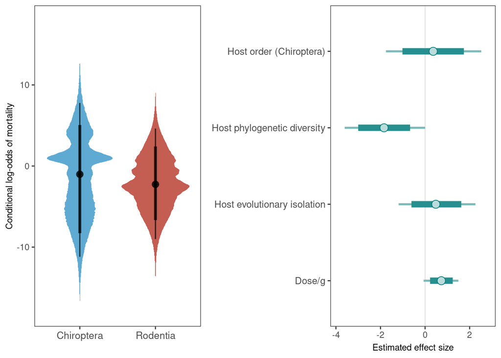

```r
p2 <- cond_eff_plot(model) + scale_y_continuous(lim=c(-18,18)) +
      ylab("Conditional log-odds of mortality") + xlab("") +
      theme(axis.title=element_text(size=9),axis.text.x=element_text(size=10),
            panel.grid.major = element_blank(),
            panel.grid.minor = element_blank())+
      scale_x_discrete(limits = c("Chiroptera","Rodentia"))

ar2 <- intervals_plot(model)

plot_grid(p2, ar2, align="h", rel_widths =c(0.7,1))
```

```r
# ggsave("../plots_tables/individual_level_mortality_full_comboplot.pdf", width=8, height=3)
```

Sample size: 1134

## Severity - Full model

Fitting an ordinal regression (a.k.a. cumulative link) model for disease severity

```r
dat_severity <- dat
dat_severity <- dat_severity[dat_severity$Susceptible_YN==1,]
dat_severity <- dat_severity[!is.na(dat_severity$Susceptible_YN),]

dat_severity <- dat_severity[!is.na(dat_severity$severity_rank),]

dat_severity$ses_pd <- scale_half(dat_severity$ses_pd)
dat_severity$EvoIso <- scale_half(dat_severity$EvoIso)
dat_severity$adult_mass_g <- scale_half(log(dat_severity$adult_mass_g))

dat_severity <- dat_severity %>% group_by(Dose_unit) %>% mutate(Dose_mass = scale_half(log(Dose_mass)))
dat_severity <- dat_severity %>% group_by(Dose_unit) %>% mutate(Dose_amount = scale_half(log(Dose_amount)))

dat_severity$Host_name <- dat_severity$Host_Upham
dat_severity$Virus_name <- dat_severity$Virus_ICTV
```

```r
if (!file.exists("../fit_models/indiv_severity_full.rds")) {

  severity_full <- brm(severity_rank ~ Host_order +
                      ses_pd + EvoIso +
                       Dose_mass + (1|Dose_unit) +
                      (1|PaperID) +
                      (1|Host_name) + (1|Virus_name) +
                      (1|Host_Upham) + (1|Virus_ICTV) +
                      (1|Route_type),
    data=dat_severity, family=cumulative(probit),
    prior=custom_prior,
    iter=5000, thin=1, cov_ranef = list(Host_Upham = host_cov, Virus_ICTV=virus_cov),
    control=list(adapt_delta=0.98, max_treedepth=12), cores=4,
    save_pars=save_pars(all=TRUE))

  saveRDS(severity_full, "../fit_models/indiv_severity_full.rds")

} else { severity_full <- readRDS("../fit_models/indiv_severity_full.rds")}

model <- severity_full
# summary(model, prob=0.9)

# save memory
rm(severity_full)

# pp <- brms::posterior_predict(model)
# ppc_dens_overlay(y=model$data$severity_rank, pp[1:500, ])

param_tab(model)
```

| Parameter | Effects | Mean | CI | CI_low | CI_high | Rhat | Group |
| --- | --- | --- | --- | --- | --- | --- | --- |
| b_Intercept[1] | fixed | -0.30 | 0.90 | -1.52 | 0.93 | 1.00 |  |
| b_Intercept[2] | fixed | 0.19 | 0.90 | -1.03 | 1.42 | 1.00 |  |
| b_Intercept[3] | fixed | 0.58 | 0.90 | -0.64 | 1.80 | 1.00 |  |
| b_Intercept[4] | fixed | 1.06 | 0.90 | -0.16 | 2.27 | 1.00 |  |
| b_Host_orderChiroptera | fixed | 0.08 | 0.90 | -1.27 | 1.49 | 1.00 |  |
| b_ses_pd | fixed | -0.79 | 0.90 | -1.55 | -0.03 | 1.00 |  |
| b_EvoIso | fixed | 0.01 | 0.90 | -0.53 | 0.55 | 1.00 |  |
| b_Dose_mass | fixed | 0.55 | 0.90 | 0.32 | 0.79 | 1.00 |  |
| sd_Dose_unit__Intercept | random | 0.96 | 0.90 | 0.12 | 2.04 | 1.00 | Dose_unit |
| sd_Host_name__Intercept | random | 1.53 | 0.90 | 1.07 | 2.02 | 1.00 | Host_name |
| sd_Host_Upham__Intercept | random | 0.74 | 0.90 | 0.06 | 1.78 | 1.01 | Host_Upham |
| sd_PaperID__Intercept | random | 1.71 | 0.90 | 1.31 | 2.16 | 1.00 | PaperID |
| sd_Route_type__Intercept | random | 1.05 | 0.90 | 0.59 | 1.70 | 1.00 | Route_type |
| sd_Virus_ICTV__Intercept | random | 0.62 | 0.90 | 0.06 | 1.36 | 1.00 | Virus_ICTV |
| sd_Virus_name__Intercept | random | 0.23 | 0.90 | 0.02 | 0.60 | 1.00 | Virus_name |

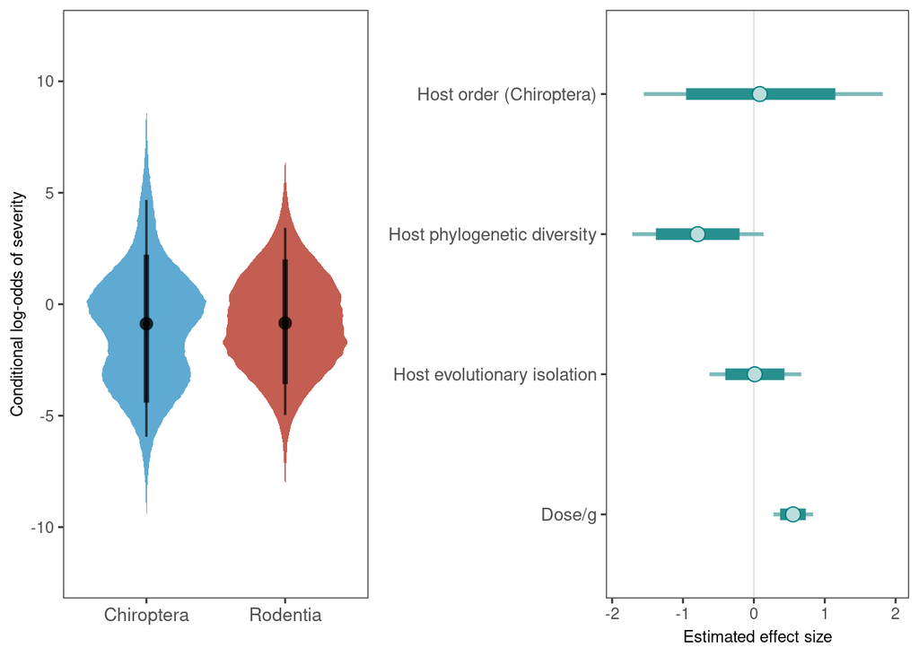

```r
p3 <- cond_eff_plot(model) + scale_y_continuous(lim=c(-12,12)) +
      ylab("Conditional log-odds of severity") + xlab("") +
      theme(axis.title=element_text(size=9),axis.text.x=element_text(size=10),
            panel.grid.major = element_blank(),
            panel.grid.minor = element_blank())+
      scale_x_discrete(limits = c("Chiroptera","Rodentia"))

ar3 <- intervals_plot(model)

plot_grid(p3, ar3, align="h", rel_widths =c(0.7,1))
```

```r
# ggsave("../plots_tables/individual_level_severity_full_comboplot.pdf", width=8, height=3)
```

## Joint results plots (individual level models)

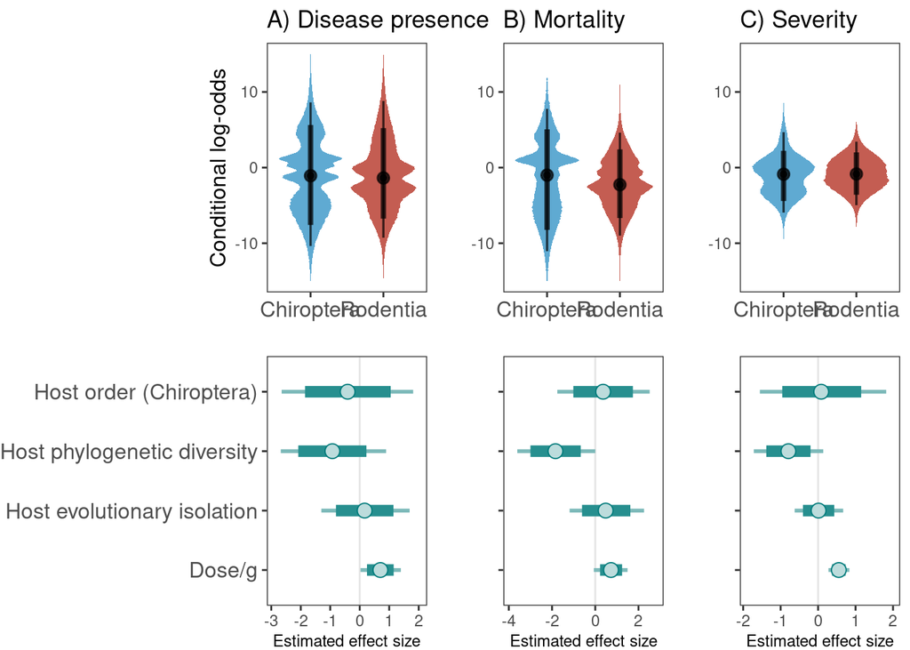

```r
## Joint plot
global_ylim <-  scale_y_continuous(lim=c(-15,15))
padding <- theme(plot.margin = unit(c(t=0, r=-3, b=0, l=0), "cm"))

joint_plot <- joint_conditionals_intervals(p1,p2,p3,global_ylim,padding,ar1,ar2,ar3)
```

```r
ggsave("../plots_tables/individual_level_conditionals_intervals_full.pdf", joint_plot, width=10.5, height=5.5)
```

## Hierarchical effects plots

### Individual level presence of disease full model

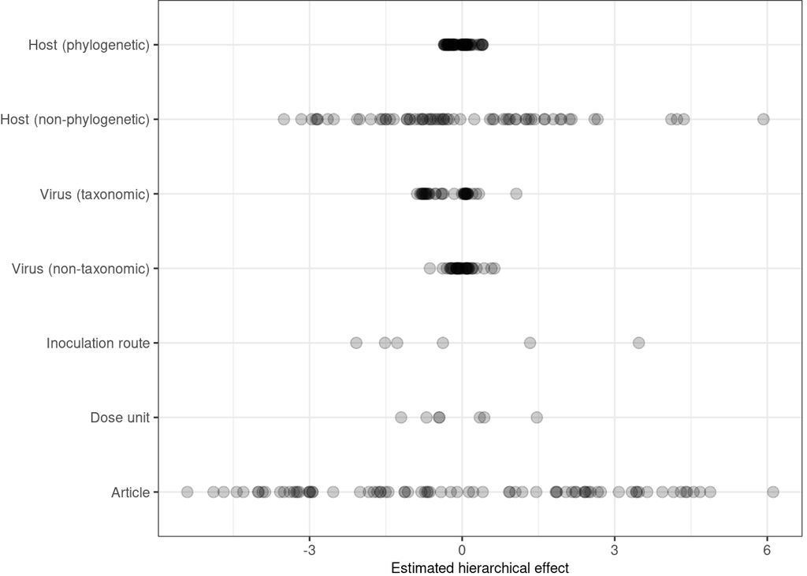

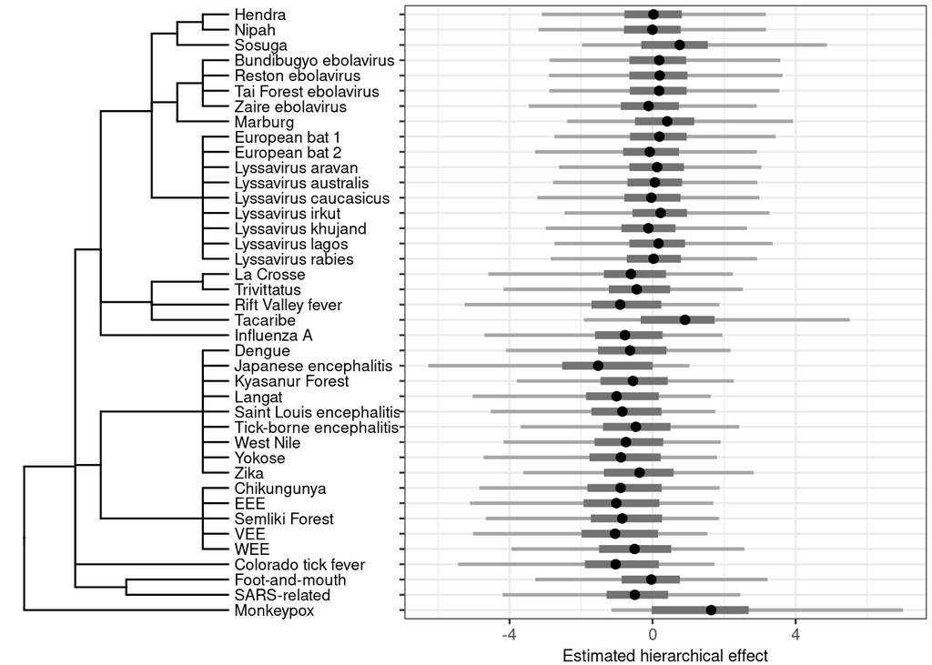

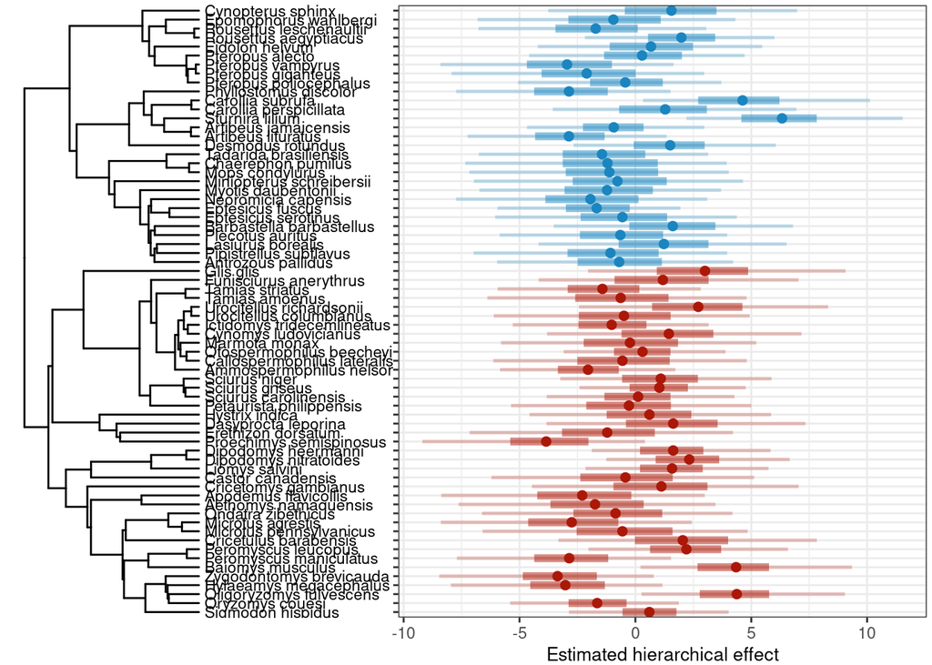

### Individual level mortality full model

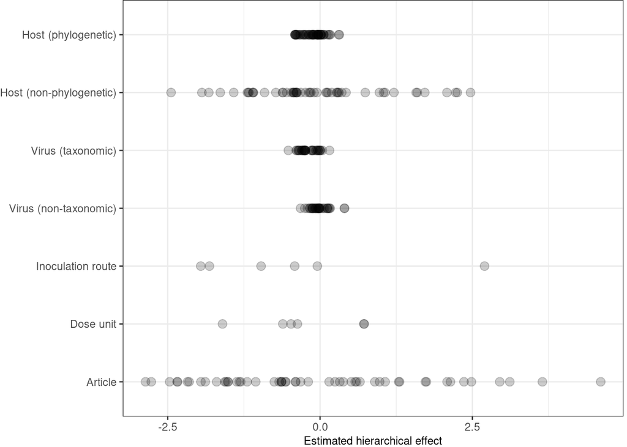

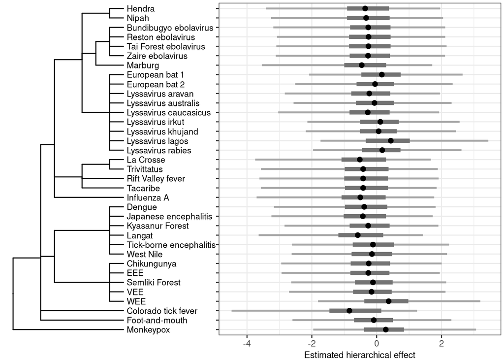

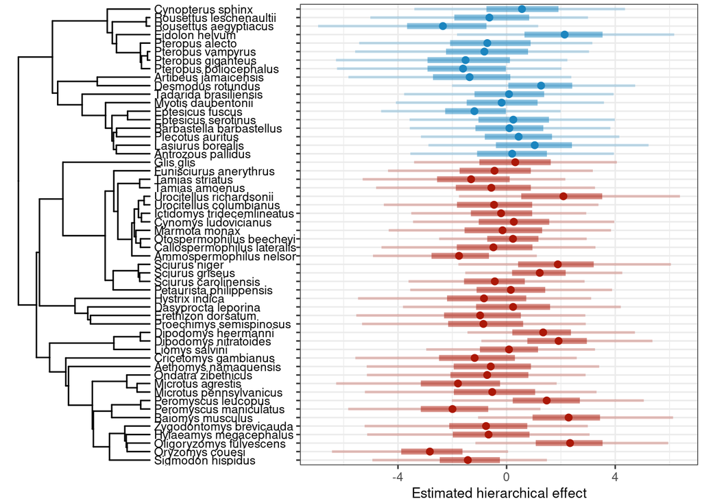

### Individual level severity full model

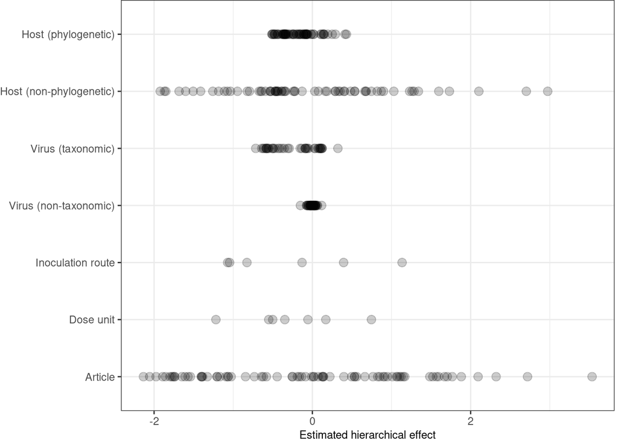

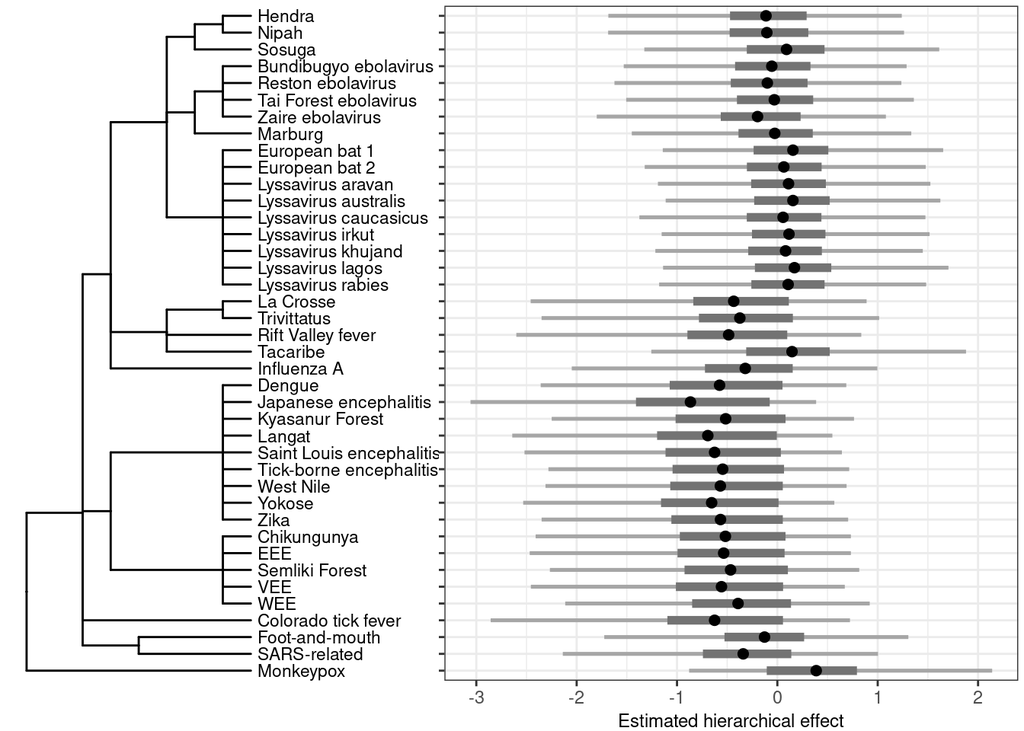

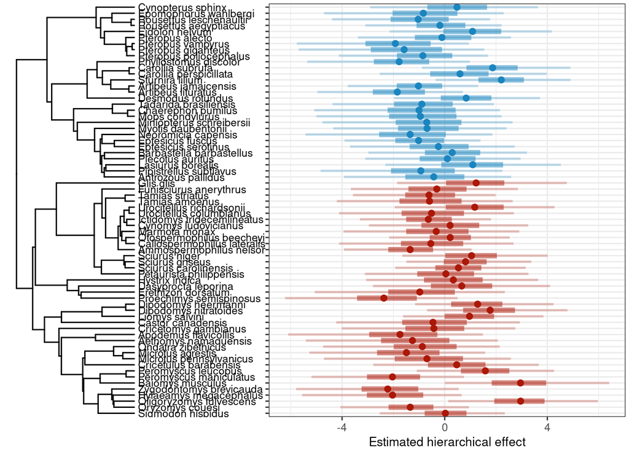

### Joint hierarchical effects plot (individual level full model)

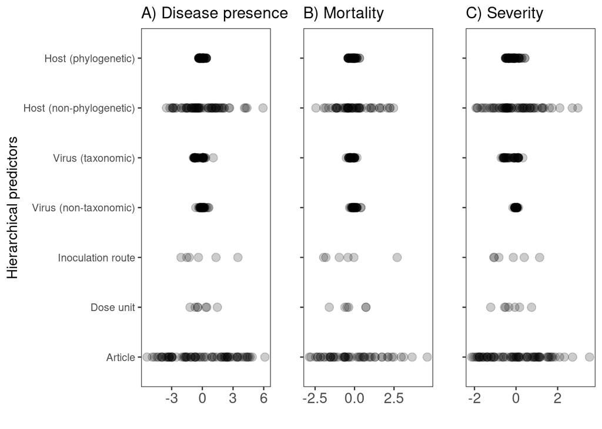

```r
re_all_indiv <-  egg::ggarrange(
        (re_dis +
        padding +
        ggtitle("A) Disease presence")+
        ylab("Hierarchical predictors") +
        xlab("") +
        theme_bw() +
        theme(legend.position = "none",
              axis.title.y=element_text(size=12),
              axis.text.x=element_text(size=12),
              panel.grid.major = element_blank(),
              panel.grid.minor = element_blank())),

        (re_mort +
        padding +
        ggtitle("B) Mortality")+
        ylab("") +
        xlab("") +
        theme_bw() +
        theme(legend.position = "none",
              axis.text.x=element_text(size=12),
              axis.text.y=element_blank(),
              panel.grid.major = element_blank(),
              panel.grid.minor = element_blank())),

        (re_severity +
        padding +
        ggtitle("C) Severity")+
        ylab("") +
        xlab("") +
        theme_bw() +
        theme(legend.position = "none",
              axis.text.x=element_text(size=12),
              axis.text.y=element_blank(),
              panel.grid.major = element_blank(),
              panel.grid.minor = element_blank())),
        ncol=3, padding=0.5)
```

```r
ggsave("../plots_tables/hierarchical_effects_indiv_all.pdf", re_all_indiv, width=9, height=4)
```

## Individual level models (reservoir match - no HEI)

### Presence of disease (reservoir match - no HEI)

```r
if (!file.exists("../fit_models/indiv_disease_resMatch_alone.rds")) {

  disease_resMatch_alone <- brm(Disease_YN ~ Host_order +
                      Reservoir_match +
                      ses_pd +
                      Dose_mass + (1|Dose_unit) +
                      (1|PaperID) +
                      (1|Host_name) + (1|Virus_name) +
                      (1|Host_Upham) + (1|Virus_ICTV) +
                      (1|Route_type),
    data=dat_dis, family=bernoulli(link = "logit"),
    prior=custom_prior,
    iter=5000, thin=1, cov_ranef = list(Host_Upham = host_cov, Virus_ICTV=virus_cov),
    control=list(adapt_delta=0.98, max_treedepth=12), cores=4,
    save_pars=save_pars(all=TRUE))

  saveRDS(disease_resMatch_alone, "../fit_models/indiv_disease_resMatch_alone.rds")

} else { disease_resMatch_alone <- readRDS("../fit_models/indiv_disease_resMatch_alone.rds")}

model <- disease_resMatch_alone
# summary(model, prob=0.9)

# save memory
rm(disease_resMatch_alone)

# pp <- brms::posterior_predict(model)
# ppc_dens_overlay(y=model$data$Disease_YN, pp[1:500, ])

param_tab(model)
```

| Parameter | Effects | Mean | CI | CI_low | CI_high | Rhat | Group |
| --- | --- | --- | --- | --- | --- | --- | --- |
| b_Intercept | fixed | -0.21 | 0.90 | -2.30 | 1.86 | 1.00 |  |
| b_Host_orderChiroptera | fixed | -0.80 | 0.90 | -2.66 | 1.05 | 1.00 |  |
| b_Reservoir_match | fixed | 1.26 | 0.90 | -0.23 | 2.73 | 1.00 |  |
| b_ses_pd | fixed | -0.46 | 0.90 | -2.01 | 1.09 | 1.00 |  |
| b_Dose_mass | fixed | 0.70 | 0.90 | 0.11 | 1.29 | 1.00 |  |
| sd_Dose_unit__Intercept | random | 1.12 | 0.90 | 0.11 | 2.39 | 1.00 | Dose_unit |
| sd_Host_name__Intercept | random | 2.65 | 0.90 | 1.93 | 3.42 | 1.00 | Host_name |
| sd_Host_Upham__Intercept | random | 0.87 | 0.90 | 0.07 | 2.14 | 1.00 | Host_Upham |
| sd_PaperID__Intercept | random | 3.34 | 0.90 | 2.57 | 4.15 | 1.00 | PaperID |
| sd_Route_type__Intercept | random | 1.89 | 0.90 | 1.22 | 2.72 | 1.00 | Route_type |
| sd_Virus_ICTV__Intercept | random | 0.97 | 0.90 | 0.08 | 2.23 | 1.00 | Virus_ICTV |
| sd_Virus_name__Intercept | random | 0.73 | 0.90 | 0.06 | 1.86 | 1.00 | Virus_name |

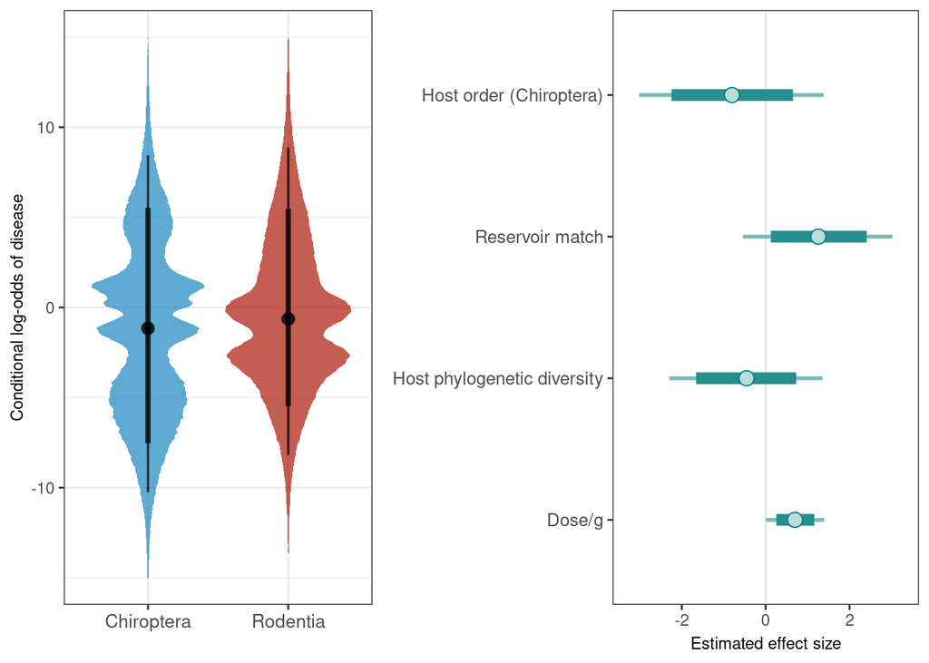

```r
p1 <- cond_eff_plot(model) + scale_y_continuous(lim=c(-15,15)) +
      ylab("Conditional log-odds of disease") + xlab("") +
      theme(axis.title=element_text(size=9),axis.text.x=element_text(size=10)) +
      scale_x_discrete(limits = c("Chiroptera","Rodentia"))

ar1 <- intervals_plot(model)

plot_grid(p1, ar1, align="h", rel_widths =c(0.7,1))
```

```r
# ggsave("../plots_tables/individual_level_disease_resMatch_alone_comboplot.pdf", width=8, height=3)
```

Sample size: 1920

### Mortality (reservoir match - no HEI)

```r
if (!file.exists("../fit_models/indiv_mortality_resMatch_alone.rds")) {

  mortality_resMatch_alone <- brm(Mortality_YN ~ Host_order +
                      Reservoir_match +
                      ses_pd +
                       Dose_mass + (1|Dose_unit) +
                      (1|PaperID) +
                      (1|Host_name) + (1|Virus_name) +
                      (1|Host_Upham) + (1|Virus_ICTV) +
                      (1|Route_type),
    data=dat_mort, family=bernoulli(link = "logit"),
    prior=custom_prior,
    iter=5000, thin=1, cov_ranef = list(Host_Upham = host_cov, Virus_ICTV=virus_cov),
    control=list(adapt_delta=0.96, max_treedepth=12), cores=4,
    save_pars=save_pars(all=TRUE))

  saveRDS(mortality_resMatch_alone, "../fit_models/indiv_mortality_resMatch_alone.rds")

} else { mortality_resMatch_alone <- readRDS("../fit_models/indiv_mortality_resMatch_alone.rds")}

model <- mortality_resMatch_alone
# summary(model, prob=0.9)

# save memory
rm(mortality_resMatch_alone)

param_tab(model)
```

| Parameter | Effects | Mean | CI | CI_low | CI_high | Rhat | Group |
| --- | --- | --- | --- | --- | --- | --- | --- |
| b_Intercept | fixed | -0.92 | 0.90 | -2.96 | 1.11 | 1.00 |  |
| b_Host_orderChiroptera | fixed | 0.05 | 0.90 | -1.74 | 1.84 | 1.00 |  |
| b_Reservoir_match | fixed | 0.14 | 0.90 | -1.44 | 1.74 | 1.00 |  |
| b_ses_pd | fixed | -1.67 | 0.90 | -3.21 | -0.13 | 1.00 |  |
| b_Dose_mass | fixed | 0.74 | 0.90 | 0.09 | 1.40 | 1.00 |  |
| sd_Dose_unit__Intercept | random | 1.30 | 0.90 | 0.29 | 2.34 | 1.00 | Dose_unit |
| sd_Host_name__Intercept | random | 1.78 | 0.90 | 1.14 | 2.48 | 1.00 | Host_name |
| sd_Host_Upham__Intercept | random | 0.70 | 0.90 | 0.06 | 1.71 | 1.00 | Host_Upham |
| sd_PaperID__Intercept | random | 2.35 | 0.90 | 1.61 | 3.18 | 1.00 | PaperID |
| sd_Route_type__Intercept | random | 1.72 | 0.90 | 1.07 | 2.57 | 1.00 | Route_type |
| sd_Virus_ICTV__Intercept | random | 0.73 | 0.90 | 0.05 | 1.81 | 1.00 | Virus_ICTV |
| sd_Virus_name__Intercept | random | 0.64 | 0.90 | 0.05 | 1.57 | 1.00 | Virus_name |

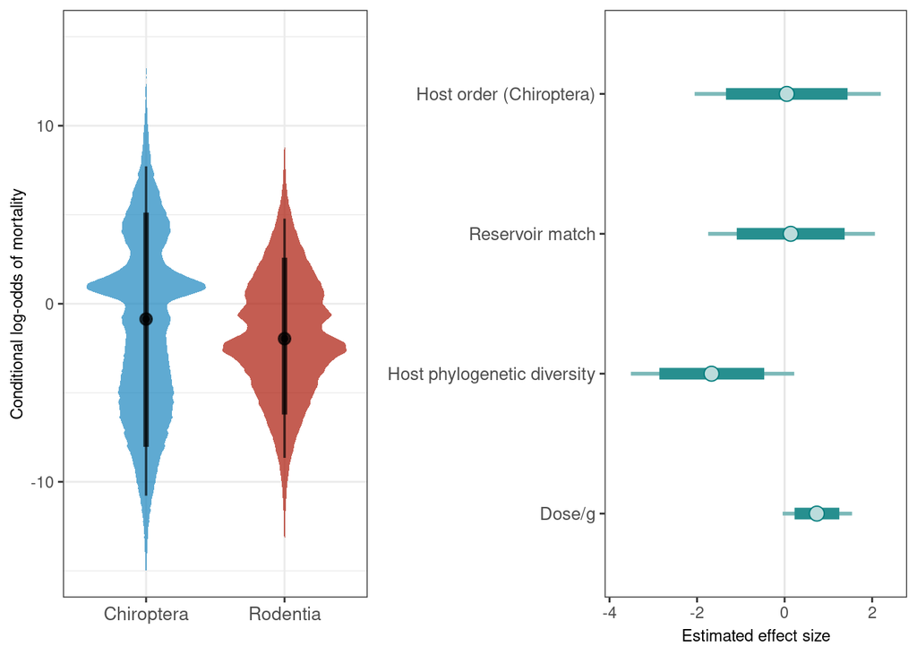

```r
# pp <- brms::posterior_predict(model)
# ppc_dens_overlay(y=model$data$Mortality_YN, pp[1:500, ])

p2 <- cond_eff_plot(model) + scale_y_continuous(lim=c(-15,15)) +
      ylab("Conditional log-odds of mortality") + xlab("") +
      theme(axis.title=element_text(size=9),axis.text.x=element_text(size=10)) +
      scale_x_discrete(limits = c("Chiroptera","Rodentia"))

ar2 <- intervals_plot(model)

plot_grid(p2, ar2, align="h", rel_widths =c(0.7,1))
```

```r
# ggsave("../plots_tables/individual_level_mortality_resMatch_alone_comboplot.pdf", width=8, height=3)
```

Sample size: 1088

### Severity (reservoir match - no HEI)

```r
if (!file.exists("../fit_models/indiv_severity_resMatch_alone.rds")) {

  severity_resMatch_alone <- brm(severity_rank ~ Host_order +
                      Reservoir_match +
                      ses_pd +
                      Dose_mass + (1|Dose_unit) +
                      (1|PaperID) +
                      (1|Host_name) + (1|Virus_name) +
                      (1|Host_Upham) + (1|Virus_ICTV) +
                      (1|Route_type),
    data=dat_severity, family=cumulative(probit),
    prior=custom_prior,
    iter=5000, thin=1, cov_ranef = list(Host_Upham = host_cov, Virus_ICTV=virus_cov),
    control=list(adapt_delta=0.98, max_treedepth=12), cores=4,
    save_pars=save_pars(all=TRUE))

  saveRDS(severity_resMatch_alone, "../fit_models/indiv_severity_resMatch_alone.rds")

} else { severity_resMatch_alone <- readRDS("../fit_models/indiv_severity_resMatch_alone.rds")}

model <- severity_resMatch_alone
# summary(model, prob=0.9)

# save memory
rm(severity_resMatch_alone)

# pp <- brms::posterior_predict(model)
# ppc_dens_overlay(y=model$data$severity_rank, pp[1:500, ])

param_tab(model)
```

| Parameter | Effects | Mean | CI | CI_low | CI_high | Rhat | Group |
| --- | --- | --- | --- | --- | --- | --- | --- |
| b_Intercept[1] | fixed | -0.07 | 0.90 | -1.41 | 1.23 | 1.00 |  |
| b_Intercept[2] | fixed | 0.37 | 0.90 | -0.97 | 1.67 | 1.00 |  |
| b_Intercept[3] | fixed | 0.77 | 0.90 | -0.56 | 2.08 | 1.00 |  |
| b_Intercept[4] | fixed | 1.26 | 0.90 | -0.08 | 2.56 | 1.00 |  |
| b_Host_orderChiroptera | fixed | -0.08 | 0.90 | -1.41 | 1.31 | 1.00 |  |
| b_Reservoir_match | fixed | 0.56 | 0.90 | -0.36 | 1.44 | 1.00 |  |
| b_ses_pd | fixed | -0.59 | 0.90 | -1.52 | 0.32 | 1.00 |  |
| b_Dose_mass | fixed | 0.55 | 0.90 | 0.31 | 0.79 | 1.00 |  |
| sd_Dose_unit__Intercept | random | 0.92 | 0.90 | 0.09 | 1.97 | 1.00 | Dose_unit |
| sd_Host_name__Intercept | random | 1.50 | 0.90 | 1.04 | 1.99 | 1.00 | Host_name |
| sd_Host_Upham__Intercept | random | 0.70 | 0.90 | 0.05 | 1.75 | 1.01 | Host_Upham |
| sd_PaperID__Intercept | random | 1.66 | 0.90 | 1.25 | 2.12 | 1.00 | PaperID |
| sd_Route_type__Intercept | random | 1.04 | 0.90 | 0.59 | 1.71 | 1.00 | Route_type |
| sd_Virus_ICTV__Intercept | random | 0.64 | 0.90 | 0.06 | 1.46 | 1.00 | Virus_ICTV |
| sd_Virus_name__Intercept | random | 0.34 | 0.90 | 0.02 | 0.89 | 1.00 | Virus_name |

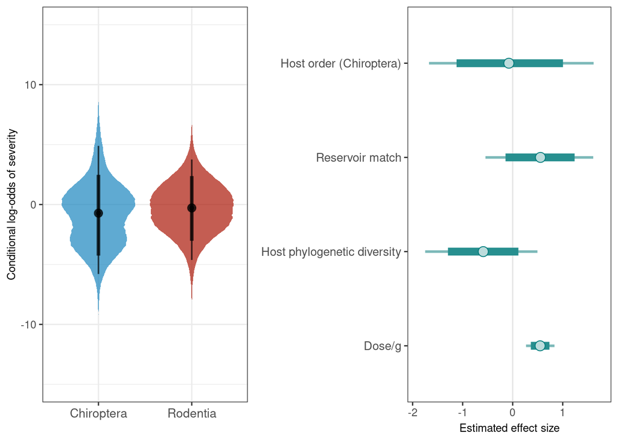

```r
p3 <- cond_eff_plot(model) + scale_y_continuous(lim=c(-15,15)) +
      ylab("Conditional log-odds of severity") + xlab("") +
      theme(axis.title=element_text(size=9),axis.text.x=element_text(size=10)) +
      scale_x_discrete(limits = c("Chiroptera","Rodentia"))

ar3 <- intervals_plot(model)

plot_grid(p3, ar3, align="h", rel_widths =c(0.7,1))
```

```r
# ggsave("../plots_tables/individual_level_severity_resMatch_alone_comboplot.pdf", width=8, height=3)
```

Sample size: 1920

### Joint results plots (reservoir match - no HEI)

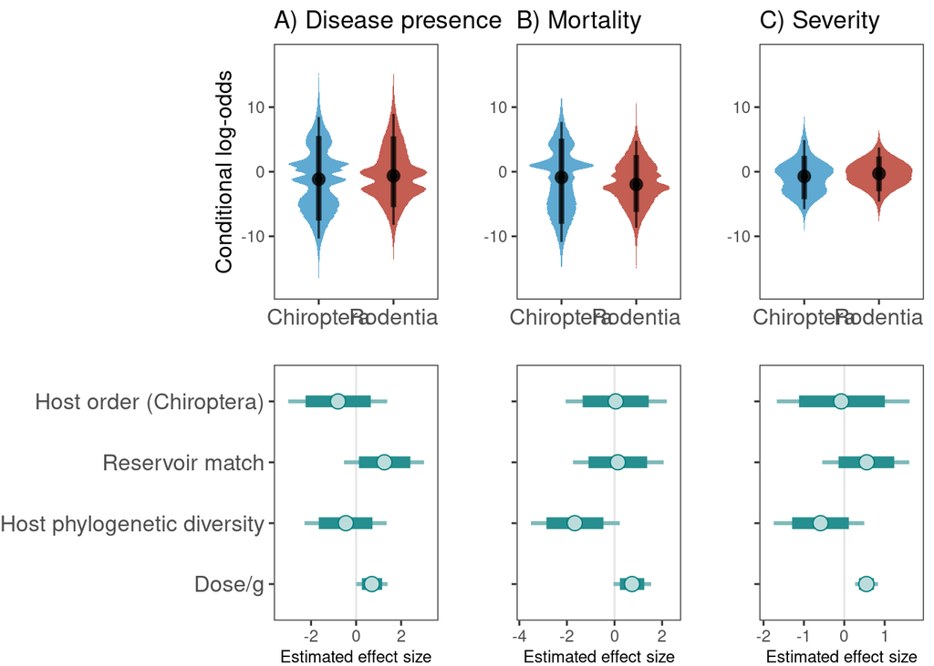

```r
## Joint plot
global_ylim <-  scale_y_continuous(lim=c(-18,18))
padding <- theme(plot.margin = unit(c(t=0, r=-3, b=0, l=0), "cm"))

joint_plot <- joint_conditionals_intervals(p1,p2,p3,global_ylim,padding,ar1,ar2,ar3)
```

```r
ggsave("../plots_tables/individual_level_conditionals_intervals_resMatch_alone.pdf", joint_plot, width=10.5, height=5.5)
```

## Individual level models (reservoir match - with HEI)

### Presence of disease (reservoir match - with HEI)

```r
if (!file.exists("../fit_models/indiv_disease_resMatch.rds")) {

  disease_resMatch <- brm(Disease_YN ~ Host_order + Reservoir_match +
                      ses_pd + EvoIso +
                       Dose_mass + (1|Dose_unit) +
                      (1|PaperID) +
                      (1|Host_name) + (1|Virus_name) +
                      (1|Host_Upham) + (1|Virus_ICTV) +
                      (1|Route_type),
    data=dat_dis, family=bernoulli(link = "logit"),
    prior=custom_prior,
    iter=5000, thin=1, cov_ranef = list(Host_Upham = host_cov, Virus_ICTV=virus_cov),
    control=list(adapt_delta=0.98, max_treedepth=12), cores=4,
    save_pars=save_pars(all=TRUE))

  saveRDS(disease_resMatch, "../fit_models/indiv_disease_resMatch.rds")

} else { disease_resMatch <- readRDS("../fit_models/indiv_disease_resMatch.rds")}

model <- disease_resMatch
# summary(model, prob=0.9)

# save memory
rm(disease_resMatch)

# pp <- brms::posterior_predict(model)
# ppc_dens_overlay(y=model$data$Disease_YN, pp[1:500, ])

param_tab(model)
```

| Parameter | Effects | Mean | CI | CI_low | CI_high | Rhat | Group |
| --- | --- | --- | --- | --- | --- | --- | --- |
| b_Intercept | fixed | -0.20 | 0.90 | -2.28 | 1.87 | 1.00 |  |
| b_Host_orderChiroptera | fixed | -0.80 | 0.90 | -2.65 | 1.07 | 1.00 |  |
| b_Reservoir_match | fixed | 1.25 | 0.90 | -0.24 | 2.73 | 1.00 |  |
| b_ses_pd | fixed | -0.43 | 0.90 | -2.06 | 1.14 | 1.00 |  |
| b_EvoIso | fixed | 0.10 | 0.90 | -1.15 | 1.39 | 1.00 |  |
| b_Dose_mass | fixed | 0.69 | 0.90 | 0.13 | 1.27 | 1.00 |  |
| sd_Dose_unit__Intercept | random | 1.14 | 0.90 | 0.11 | 2.42 | 1.00 | Dose_unit |
| sd_Host_name__Intercept | random | 2.65 | 0.90 | 1.95 | 3.41 | 1.00 | Host_name |
| sd_Host_Upham__Intercept | random | 0.86 | 0.90 | 0.07 | 2.11 | 1.00 | Host_Upham |
| sd_PaperID__Intercept | random | 3.33 | 0.90 | 2.55 | 4.17 | 1.00 | PaperID |
| sd_Route_type__Intercept | random | 1.90 | 0.90 | 1.24 | 2.71 | 1.00 | Route_type |
| sd_Virus_ICTV__Intercept | random | 1.00 | 0.90 | 0.09 | 2.32 | 1.00 | Virus_ICTV |
| sd_Virus_name__Intercept | random | 0.76 | 0.90 | 0.06 | 1.88 | 1.00 | Virus_name |

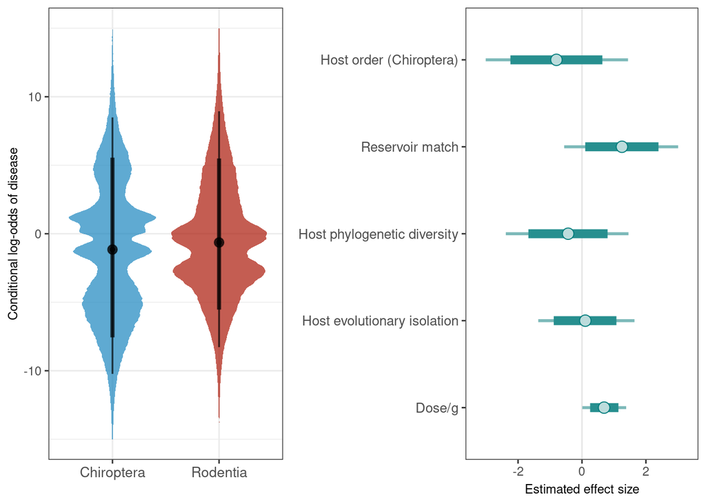

```r
p1 <- cond_eff_plot(model) + scale_y_continuous(lim=c(-15,15)) +
      ylab("Conditional log-odds of disease") + xlab("") +
      theme(axis.title=element_text(size=9),axis.text.x=element_text(size=10)) +
      scale_x_discrete(limits = c("Chiroptera","Rodentia"))

ar1 <- intervals_plot(model)

plot_grid(p1, ar1, align="h", rel_widths =c(0.7,1))
```

```r
# ggsave("../plots_tables/individual_level_disease_resMatch_comboplot.pdf", width=8, height=3)
```

Sample size: 1920

### Mortality (reservoir match - with HEI)

```r
if (!file.exists("../fit_models/indiv_mortality_resMatch.rds")) {

  mortality_resMatch <- brm(Mortality_YN ~ Host_order + Reservoir_match +
                      ses_pd + EvoIso +
                       Dose_mass + (1|Dose_unit) +
                      (1|PaperID) +
                      (1|Host_name) + (1|Virus_name) +
                      (1|Host_Upham) + (1|Virus_ICTV) +
                      (1|Route_type),
    data=dat_mort, family=bernoulli(link = "logit"),
    prior=custom_prior,
    iter=5000, thin=1, cov_ranef = list(Host_Upham = host_cov, Virus_ICTV=virus_cov),
    control=list(adapt_delta=0.95, max_treedepth=12), cores=4,
    save_pars=save_pars(all=TRUE))

  saveRDS(mortality_resMatch, "../fit_models/indiv_mortality_resMatch.rds")

} else { mortality_resMatch <- readRDS("../fit_models/indiv_mortality_resMatch.rds")}

model <- mortality_resMatch
# summary(model, prob=0.9)

# save memory
rm(mortality_resMatch)

param_tab(model)
```

| Parameter | Effects | Mean | CI | CI_low | CI_high | Rhat | Group |
| --- | --- | --- | --- | --- | --- | --- | --- |
| b_Intercept | fixed | -1.09 | 0.90 | -3.07 | 0.96 | 1.00 |  |
| b_Host_orderChiroptera | fixed | 0.16 | 0.90 | -1.61 | 1.98 | 1.00 |  |
| b_Reservoir_match | fixed | 0.28 | 0.90 | -1.38 | 1.95 | 1.00 |  |
| b_ses_pd | fixed | -1.55 | 0.90 | -3.13 | 0.08 | 1.00 |  |
| b_EvoIso | fixed | 0.52 | 0.90 | -0.97 | 2.11 | 1.00 |  |
| b_Dose_mass | fixed | 0.73 | 0.90 | 0.07 | 1.39 | 1.00 |  |
| sd_Dose_unit__Intercept | random | 1.29 | 0.90 | 0.28 | 2.34 | 1.00 | Dose_unit |
| sd_Host_name__Intercept | random | 1.76 | 0.90 | 1.12 | 2.46 | 1.00 | Host_name |
| sd_Host_Upham__Intercept | random | 0.71 | 0.90 | 0.06 | 1.77 | 1.00 | Host_Upham |
| sd_PaperID__Intercept | random | 2.37 | 0.90 | 1.63 | 3.20 | 1.00 | PaperID |
| sd_Route_type__Intercept | random | 1.71 | 0.90 | 1.06 | 2.58 | 1.00 | Route_type |
| sd_Virus_ICTV__Intercept | random | 0.74 | 0.90 | 0.05 | 1.84 | 1.00 | Virus_ICTV |
| sd_Virus_name__Intercept | random | 0.66 | 0.90 | 0.05 | 1.62 | 1.00 | Virus_name |

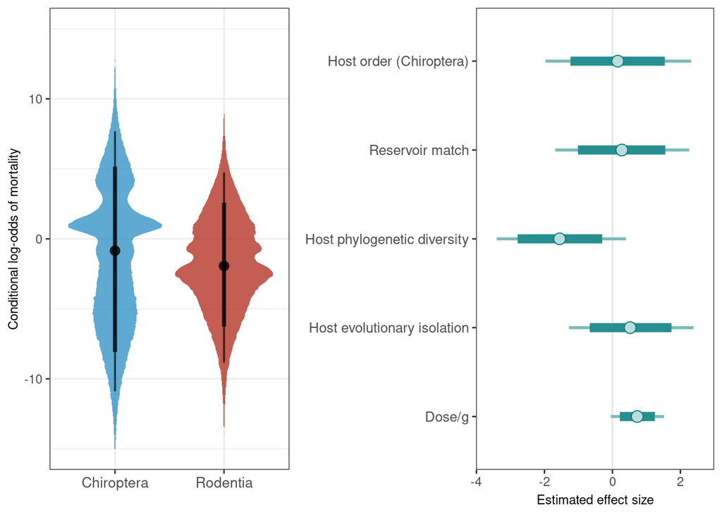

```r
# pp <- brms::posterior_predict(model)
# ppc_dens_overlay(y=model$data$Mortality_YN, pp[1:500, ])

p2 <- cond_eff_plot(model) + scale_y_continuous(lim=c(-15,15)) +
      ylab("Conditional log-odds of mortality") + xlab("") +
      theme(axis.title=element_text(size=9),axis.text.x=element_text(size=10)) +
      scale_x_discrete(limits = c("Chiroptera","Rodentia"))

ar2 <- intervals_plot(model)

plot_grid(p2, ar2, align="h", rel_widths =c(0.7,1))
```

```r
# ggsave("../plots_tables/individual_level_mortality_resMatch_comboplot.pdf", width=8, height=3)
```

Sample size: 1088

### Severity (reservoir match - with HEI)

```r
if (!file.exists("../fit_models/indiv_severity_resMatch.rds")) {

  severity_resMatch <- brm(severity_rank ~ Host_order + Reservoir_match +
                      ses_pd + EvoIso +
                       Dose_mass + (1|Dose_unit) +
                      (1|PaperID) +
                      (1|Host_name) + (1|Virus_name) +
                      (1|Host_Upham) + (1|Virus_ICTV) +
                      (1|Route_type),
    data=dat_severity, family=cumulative(probit),
    prior=custom_prior,
    iter=5000, thin=1, cov_ranef = list(Host_Upham = host_cov, Virus_ICTV=virus_cov),
    control=list(adapt_delta=0.98, max_treedepth=12), cores=4,
    save_pars=save_pars(all=TRUE))

  saveRDS(severity_resMatch, "../fit_models/indiv_severity_resMatch.rds")

} else { severity_resMatch <- readRDS("../fit_models/indiv_severity_resMatch.rds")}

model <- severity_resMatch
# summary(model, prob=0.9)

# save memory
rm(severity_resMatch)

# pp <- brms::posterior_predict(model)
# ppc_dens_overlay(y=model$data$severity_rank, pp[1:500, ])

param_tab(model)
```

| Parameter | Effects | Mean | CI | CI_low | CI_high | Rhat | Group |
| --- | --- | --- | --- | --- | --- | --- | --- |
| b_Intercept[1] | fixed | -0.07 | 0.90 | -1.46 | 1.28 | 1.00 |  |
| b_Intercept[2] | fixed | 0.37 | 0.90 | -1.02 | 1.72 | 1.00 |  |
| b_Intercept[3] | fixed | 0.77 | 0.90 | -0.61 | 2.11 | 1.00 |  |
| b_Intercept[4] | fixed | 1.25 | 0.90 | -0.13 | 2.60 | 1.00 |  |
| b_Host_orderChiroptera | fixed | -0.08 | 0.90 | -1.44 | 1.34 | 1.00 |  |
| b_Reservoir_match | fixed | 0.56 | 0.90 | -0.36 | 1.46 | 1.00 |  |
| b_ses_pd | fixed | -0.62 | 0.90 | -1.58 | 0.33 | 1.00 |  |
| b_EvoIso | fixed | -0.11 | 0.90 | -0.82 | 0.64 | 1.00 |  |
| b_Dose_mass | fixed | 0.55 | 0.90 | 0.31 | 0.79 | 1.00 |  |
| sd_Dose_unit__Intercept | random | 0.93 | 0.90 | 0.10 | 2.00 | 1.00 | Dose_unit |
| sd_Host_name__Intercept | random | 1.51 | 0.90 | 1.02 | 2.01 | 1.01 | Host_name |
| sd_Host_Upham__Intercept | random | 0.74 | 0.90 | 0.06 | 1.79 | 1.01 | Host_Upham |
| sd_PaperID__Intercept | random | 1.67 | 0.90 | 1.26 | 2.12 | 1.00 | PaperID |
| sd_Route_type__Intercept | random | 1.04 | 0.90 | 0.59 | 1.71 | 1.00 | Route_type |
| sd_Virus_ICTV__Intercept | random | 0.65 | 0.90 | 0.05 | 1.50 | 1.00 | Virus_ICTV |
| sd_Virus_name__Intercept | random | 0.36 | 0.90 | 0.03 | 0.94 | 1.00 | Virus_name |

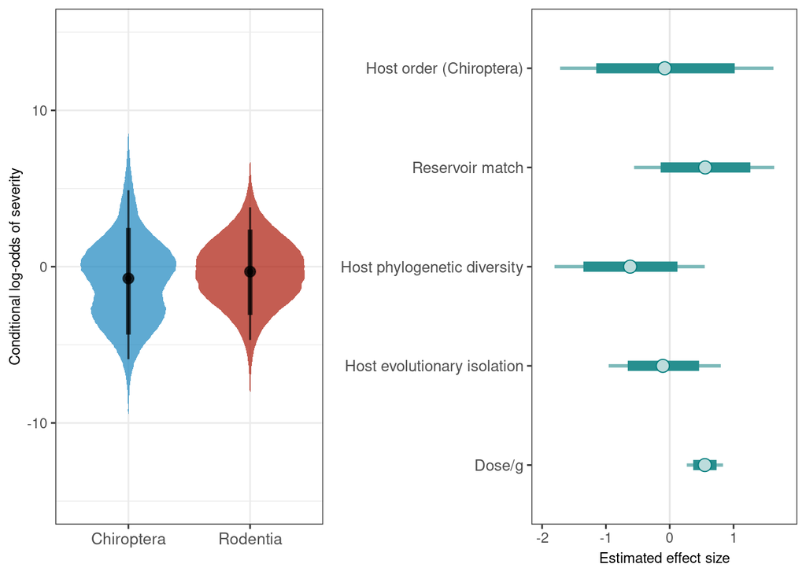

```r
p3 <- cond_eff_plot(model) + scale_y_continuous(lim=c(-15,15)) +
      ylab("Conditional log-odds of severity") + xlab("") +
      theme(axis.title=element_text(size=9),axis.text.x=element_text(size=10)) +
      scale_x_discrete(limits = c("Chiroptera","Rodentia"))

ar3 <- intervals_plot(model)

plot_grid(p3, ar3, align="h", rel_widths =c(0.7,1))
```

```r
# ggsave("../plots_tables/individual_level_severity_resMatch_comboplot.pdf", width=8, height=3)
```

Sample size: 1920

### Joint results plots (reservoir match - with HEI)

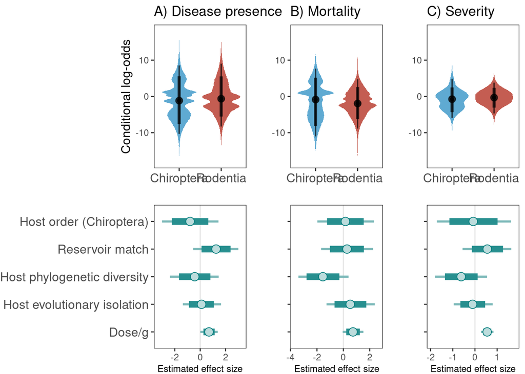

```r
## Joint plot
global_ylim <-  scale_y_continuous(lim=c(-18,18))
padding <- theme(plot.margin = unit(c(t=0, r=-3, b=0, l=0), "cm"))

joint_plot <- joint_conditionals_intervals(p1,p2,p3,global_ylim,padding,ar1,ar2,ar3)
```

```r
ggsave("../plots_tables/individual_level_conditionals_intervals_resMatch.pdf", joint_plot, width=10.5, height=5.5)
```

## Individual level models (reservoir match x order interaction)

### Presence of disease (reservoir match x order interaction)

```r
if (!file.exists("../fit_models/indiv_disease_resMatch_inter.rds")) {

  disease_resMatch_inter <- brm(Disease_YN ~ Host_order * Reservoir_match +
                      ses_pd + EvoIso +
                       Dose_mass + (1|Dose_unit) +
                      (1|PaperID) +
                      (1|Host_name) + (1|Virus_name) +
                      (1|Host_Upham) + (1|Virus_ICTV) +
                      (1|Route_type),
    data=dat_dis, family=bernoulli(link = "logit"),
    prior=custom_prior,
    iter=5000, thin=1, cov_ranef = list(Host_Upham = host_cov, Virus_ICTV=virus_cov),
    control=list(adapt_delta=0.95, max_treedepth=12), cores=4,
    save_pars=save_pars(all=TRUE))

  saveRDS(disease_resMatch_inter, "../fit_models/indiv_disease_resMatch_inter.rds")

} else { disease_resMatch_inter <- readRDS("../fit_models/indiv_disease_resMatch_inter.rds")}

model <- disease_resMatch_inter
# summary(model, prob=0.9)

# save memory
rm(disease_resMatch_inter)

# pp <- brms::posterior_predict(model)
# ppc_dens_overlay(y=model$data$Disease_YN, pp[1:500, ])

param_tab(model)
```

| Parameter | Effects | Mean | CI | CI_low | CI_high | Rhat | Group |
| --- | --- | --- | --- | --- | --- | --- | --- |
| b_Intercept | fixed | -0.27 | 0.90 | -2.42 | 1.84 | 1.00 |  |
| b_Host_orderChiroptera | fixed | -0.86 | 0.90 | -2.72 | 1.04 | 1.00 |  |
| b_Reservoir_match | fixed | 0.99 | 0.90 | -0.76 | 2.73 | 1.00 |  |
| b_ses_pd | fixed | -0.43 | 0.90 | -2.09 | 1.18 | 1.00 |  |
| b_EvoIso | fixed | 0.16 | 0.90 | -1.11 | 1.46 | 1.00 |  |
| b_Dose_mass | fixed | 0.70 | 0.90 | 0.12 | 1.28 | 1.00 |  |
| b_Host_orderChiroptera:Reservoir_match | fixed | 0.56 | 0.90 | -1.28 | 2.40 | 1.00 |  |
| sd_Dose_unit__Intercept | random | 1.19 | 0.90 | 0.12 | 2.47 | 1.00 | Dose_unit |
| sd_Host_name__Intercept | random | 2.66 | 0.90 | 1.96 | 3.43 | 1.00 | Host_name |
| sd_Host_Upham__Intercept | random | 0.85 | 0.90 | 0.06 | 2.07 | 1.00 | Host_Upham |
| sd_PaperID__Intercept | random | 3.29 | 0.90 | 2.52 | 4.13 | 1.00 | PaperID |
| sd_Route_type__Intercept | random | 1.89 | 0.90 | 1.24 | 2.69 | 1.00 | Route_type |
| sd_Virus_ICTV__Intercept | random | 1.01 | 0.90 | 0.08 | 2.31 | 1.00 | Virus_ICTV |
| sd_Virus_name__Intercept | random | 0.85 | 0.90 | 0.07 | 2.02 | 1.00 | Virus_name |

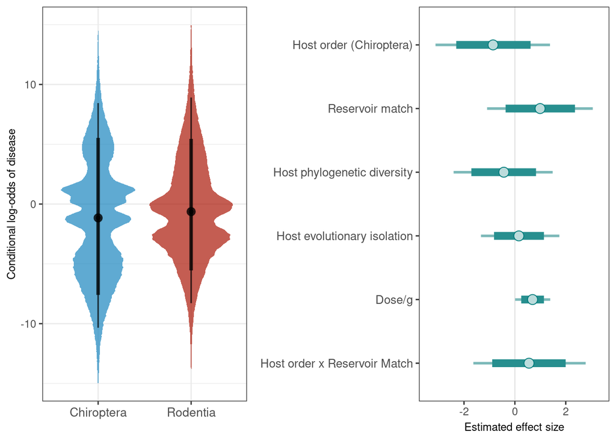

```r
# source('./scaling_plotting_functions.R')

# test <- plot_conditional_effects(model, "Conditional probabilty of disease presence")
# test

# ggsave("../plots_tables/disease_resMatch_inter_cond_effs.pdf", width=6.5, height=5)


p1 <- cond_eff_plot(model) + scale_y_continuous(lim=c(-15,15)) +
      ylab("Conditional log-odds of disease") + xlab("") +
      theme(axis.title=element_text(size=9),axis.text.x=element_text(size=10)) +
      scale_x_discrete(limits = c("Chiroptera","Rodentia"))

ar1 <- intervals_plot(model)

plot_grid(p1, ar1, align="h", rel_widths =c(0.7,1))
```

```r
ggsave("../plots_tables/individual_level_disease_resMatch_inter_comboplot.pdf", width=8, height=3)
```

Sample size: 1920

### Mortality (reservoir match x order interaction)

```r
if (!file.exists("../fit_models/indiv_mortality_resMatch_inter.rds")) {

  mortality_resMatch_inter <- brm(Mortality_YN ~ Host_order * Reservoir_match +
                      ses_pd + EvoIso +
                       Dose_mass + (1|Dose_unit) +
                      (1|PaperID) +
                      (1|Host_name) + (1|Virus_name) +
                      (1|Host_Upham) + (1|Virus_ICTV) +
                      (1|Route_type),
    data=dat_mort, family=bernoulli(link = "logit"),
    prior=custom_prior,
    iter=5000, thin=1, cov_ranef = list(Host_Upham = host_cov, Virus_ICTV=virus_cov),
    control=list(adapt_delta=0.95, max_treedepth=12), cores=4,
    save_pars=save_pars(all=TRUE))

  saveRDS(mortality_resMatch_inter, "../fit_models/indiv_mortality_resMatch_inter.rds")

} else { mortality_resMatch_inter <- readRDS("../fit_models/indiv_mortality_resMatch_inter.rds")}

model <- mortality_resMatch_inter
# summary(model, prob=0.9)

# save memory
rm(mortality_resMatch_inter)

param_tab(model)
```

| Parameter | Effects | Mean | CI | CI_low | CI_high | Rhat | Group |
| --- | --- | --- | --- | --- | --- | --- | --- |
| b_Intercept | fixed | -1.19 | 0.90 | -3.21 | 0.87 | 1.00 |  |
| b_Host_orderChiroptera | fixed | -0.03 | 0.90 | -1.88 | 1.81 | 1.00 |  |
| b_Reservoir_match | fixed | 0.08 | 0.90 | -1.61 | 1.80 | 1.00 |  |
| b_ses_pd | fixed | -1.56 | 0.90 | -3.13 | 0.03 | 1.00 |  |
| b_EvoIso | fixed | 0.64 | 0.90 | -0.91 | 2.25 | 1.00 |  |
| b_Dose_mass | fixed | 0.75 | 0.90 | 0.09 | 1.40 | 1.00 |  |
| b_Host_orderChiroptera:Reservoir_match | fixed | 0.76 | 0.90 | -1.18 | 2.71 | 1.00 |  |
| sd_Dose_unit__Intercept | random | 1.31 | 0.90 | 0.26 | 2.39 | 1.00 | Dose_unit |
| sd_Host_name__Intercept | random | 1.77 | 0.90 | 1.15 | 2.47 | 1.00 | Host_name |
| sd_Host_Upham__Intercept | random | 0.69 | 0.90 | 0.05 | 1.72 | 1.00 | Host_Upham |
| sd_PaperID__Intercept | random | 2.37 | 0.90 | 1.63 | 3.20 | 1.00 | PaperID |
| sd_Route_type__Intercept | random | 1.72 | 0.90 | 1.05 | 2.55 | 1.00 | Route_type |
| sd_Virus_ICTV__Intercept | random | 0.76 | 0.90 | 0.07 | 1.84 | 1.00 | Virus_ICTV |
| sd_Virus_name__Intercept | random | 0.65 | 0.90 | 0.05 | 1.62 | 1.00 | Virus_name |

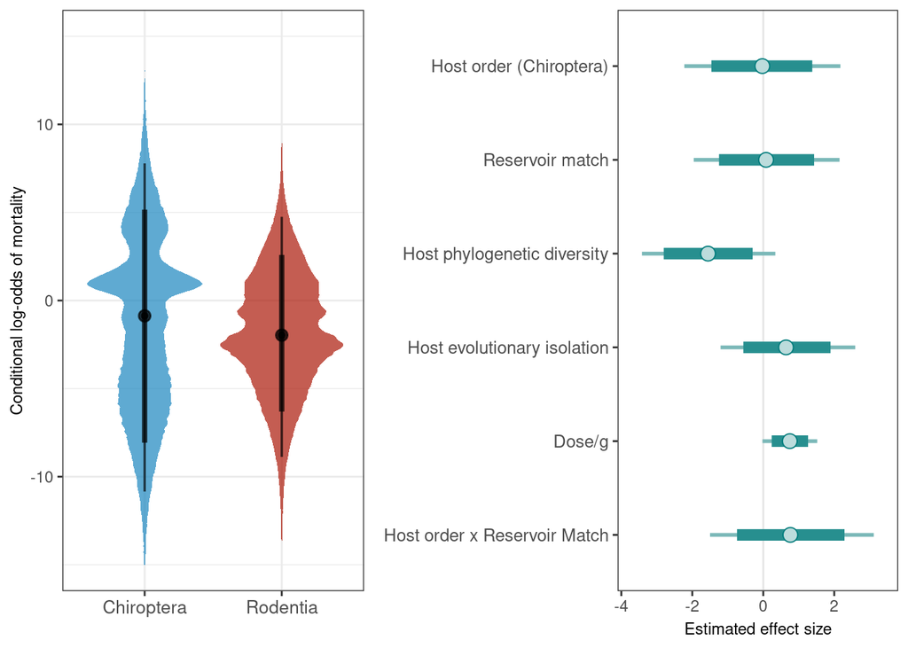

```r
# pp <- brms::posterior_predict(model)
# ppc_dens_overlay(y=model$data$Mortality_YN, pp[1:500, ])

p2 <- cond_eff_plot(model) + scale_y_continuous(lim=c(-15,15)) +
      ylab("Conditional log-odds of mortality") + xlab("") +
      theme(axis.title=element_text(size=9),axis.text.x=element_text(size=10)) +
      scale_x_discrete(limits = c("Chiroptera","Rodentia"))

ar2 <- intervals_plot(model)

plot_grid(p2, ar2, align="h", rel_widths =c(0.7,1))
```

```r
# ggsave("../plots_tables/individual_level_mortality_resMatch_inter_comboplot.pdf", width=8, height=3)
```

Sample size: 1088

### Severity (reservoir match x order interaction)

```r
if (!file.exists("../fit_models/indiv_severity_resMatch_inter.rds")) {

  severity_resMatch_inter <- brm(severity_rank ~ Host_order * Reservoir_match +
                      ses_pd + EvoIso +
                       Dose_mass + (1|Dose_unit) +
                      (1|PaperID) +
                      (1|Host_name) + (1|Virus_name) +
                      (1|Host_Upham) + (1|Virus_ICTV) +
                      (1|Route_type),
    data=dat_severity, family=cumulative(probit),
    prior=custom_prior,
    iter=5000, thin=1, cov_ranef = list(Host_Upham = host_cov, Virus_ICTV=virus_cov),
    control=list(adapt_delta=0.98, max_treedepth=12), cores=4,
    save_pars=save_pars(all=TRUE))

  saveRDS(severity_resMatch_inter, "../fit_models/indiv_severity_resMatch_inter.rds")

} else { severity_resMatch_inter <- readRDS("../fit_models/indiv_severity_resMatch_inter.rds")}

model <- severity_resMatch_inter
# summary(model, prob=0.9)

# save memory
rm(severity_resMatch_inter)

# pp <- brms::posterior_predict(model)
# ppc_dens_overlay(y=model$data$severity_rank, pp[1:500, ])

param_tab(model)
```

| Parameter | Effects | Mean | CI | CI_low | CI_high | Rhat | Group |
| --- | --- | --- | --- | --- | --- | --- | --- |
| b_Intercept[1] | fixed | -0.14 | 0.90 | -1.53 | 1.27 | 1.00 |  |
| b_Intercept[2] | fixed | 0.30 | 0.90 | -1.10 | 1.71 | 1.00 |  |
| b_Intercept[3] | fixed | 0.70 | 0.90 | -0.70 | 2.12 | 1.00 |  |
| b_Intercept[4] | fixed | 1.18 | 0.90 | -0.22 | 2.61 | 1.00 |  |
| b_Host_orderChiroptera | fixed | -0.21 | 0.90 | -1.63 | 1.33 | 1.00 |  |
| b_Reservoir_match | fixed | 0.20 | 0.90 | -1.08 | 1.52 | 1.00 |  |
| b_ses_pd | fixed | -0.66 | 0.90 | -1.63 | 0.30 | 1.00 |  |
| b_EvoIso | fixed | -0.10 | 0.90 | -0.80 | 0.64 | 1.00 |  |
| b_Dose_mass | fixed | 0.55 | 0.90 | 0.32 | 0.79 | 1.00 |  |
| b_Host_orderChiroptera:Reservoir_match | fixed | 0.53 | 0.90 | -0.91 | 1.94 | 1.00 |  |
| sd_Dose_unit__Intercept | random | 0.97 | 0.90 | 0.12 | 2.04 | 1.00 | Dose_unit |
| sd_Host_name__Intercept | random | 1.50 | 0.90 | 1.03 | 2.00 | 1.00 | Host_name |
| sd_Host_Upham__Intercept | random | 0.76 | 0.90 | 0.06 | 1.82 | 1.00 | Host_Upham |
| sd_PaperID__Intercept | random | 1.66 | 0.90 | 1.26 | 2.12 | 1.00 | PaperID |
| sd_Route_type__Intercept | random | 1.04 | 0.90 | 0.59 | 1.69 | 1.00 | Route_type |
| sd_Virus_ICTV__Intercept | random | 0.67 | 0.90 | 0.06 | 1.51 | 1.00 | Virus_ICTV |
| sd_Virus_name__Intercept | random | 0.38 | 0.90 | 0.03 | 0.98 | 1.00 | Virus_name |

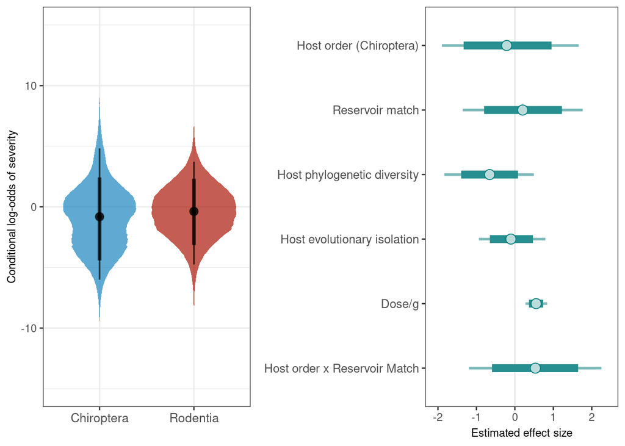

```r
p3 <- cond_eff_plot(model) + scale_y_continuous(lim=c(-15,15)) +
      ylab("Conditional log-odds of severity") + xlab("") +
      theme(axis.title=element_text(size=9),axis.text.x=element_text(size=10)) +
      scale_x_discrete(limits = c("Chiroptera","Rodentia"))

ar3 <- intervals_plot(model)

plot_grid(p3, ar3, align="h", rel_widths =c(0.7,1))
```

```r
# ggsave("../plots_tables/individual_level_severity_resMatch_inter_comboplot.pdf", width=8, height=3)
```

Sample size: 1920

### Joint results plots (reservoir match x order interaction)

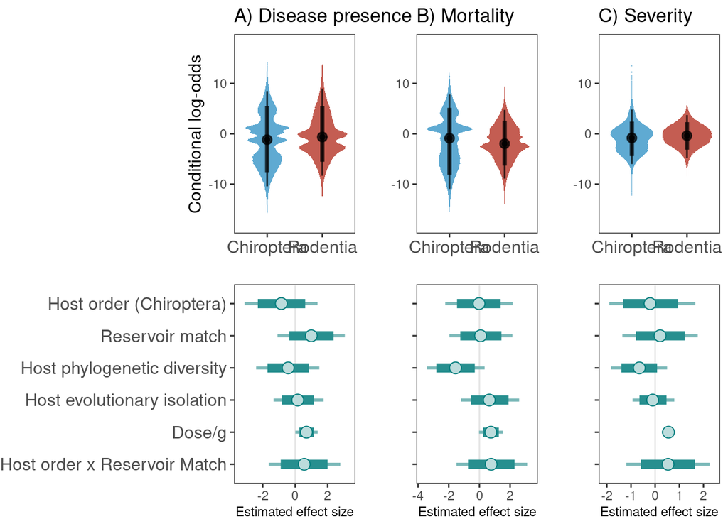

```r
## Joint plot
global_ylim <-  scale_y_continuous(lim=c(-18,18))
padding <- theme(plot.margin = unit(c(t=0, r=-3, b=0, l=0), "cm"))

joint_plot <- joint_conditionals_intervals(p1,p2,p3,global_ylim,padding,ar1,ar2,ar3)
```

```r
ggsave("../plots_tables/individual_level_conditionals_intervals_resMatch_inter.pdf", joint_plot, width=10.5, height=5.5)
```

## Individual level models (reservoir match - with HEI and removing lyssaviruses)

### Presence of disease (reservoir match - with HEI and removing lyssaviruses)

```r
lyssaviruses <- viruses$Virus_ICTV[viruses$genus=="Lyssavirus"] %>% unique()
dat_dis_nolys <- dat_dis[!dat_dis$Virus_ICTV%in%lyssaviruses,]

if (!file.exists("../fit_models/indiv_disease_resMatch_nolys.rds")) {

  disease_resMatch_nolys <- brm(Disease_YN ~ Host_order + Reservoir_match +
                      ses_pd + EvoIso +
                       Dose_mass + (1|Dose_unit) +
                      (1|PaperID) +
                      (1|Host_name) + (1|Virus_name) +
                      (1|Host_Upham) + (1|Virus_ICTV) +
                      (1|Route_type),
    data=dat_dis_nolys, family=bernoulli(link = "logit"),
    prior=custom_prior,
    iter=5000, thin=1, cov_ranef = list(Host_Upham = host_cov, Virus_ICTV=virus_cov),
    control=list(adapt_delta=0.97, max_treedepth=12), cores=4,
    save_pars=save_pars(all=TRUE))

  saveRDS(disease_resMatch_nolys, "../fit_models/indiv_disease_resMatch_nolys.rds")

} else { disease_resMatch_nolys <- readRDS("../fit_models/indiv_disease_resMatch_nolys.rds")}

model <- disease_resMatch_nolys
# summary(model, prob=0.9)

# save memory
rm(disease_resMatch_nolys)

# pp <- brms::posterior_predict(model)
# ppc_dens_overlay(y=model$data$Disease_YN, pp[1:500, ])

param_tab(model)
```

| Parameter | Effects | Mean | CI | CI_low | CI_high | Rhat | Group |
| --- | --- | --- | --- | --- | --- | --- | --- |
| b_Intercept | fixed | -0.12 | 0.90 | -2.17 | 1.92 | 1.00 |  |
| b_Host_orderChiroptera | fixed | -0.90 | 0.90 | -2.82 | 1.04 | 1.00 |  |
| b_Reservoir_match | fixed | 1.48 | 0.90 | -0.41 | 3.35 | 1.00 |  |
| b_ses_pd | fixed | -0.39 | 0.90 | -2.42 | 1.62 | 1.00 |  |
| b_EvoIso | fixed | 0.54 | 0.90 | -1.10 | 2.24 | 1.00 |  |
| b_Dose_mass | fixed | 1.33 | 0.90 | 0.40 | 2.33 | 1.00 |  |
| sd_Dose_unit__Intercept | random | 0.83 | 0.90 | 0.07 | 1.96 | 1.00 | Dose_unit |
| sd_Host_name__Intercept | random | 2.78 | 0.90 | 2.03 | 3.61 | 1.00 | Host_name |
| sd_Host_Upham__Intercept | random | 0.90 | 0.90 | 0.08 | 2.16 | 1.00 | Host_Upham |
| sd_PaperID__Intercept | random | 3.62 | 0.90 | 2.70 | 4.58 | 1.00 | PaperID |
| sd_Route_type__Intercept | random | 1.50 | 0.90 | 0.47 | 2.57 | 1.00 | Route_type |
| sd_Virus_ICTV__Intercept | random | 1.05 | 0.90 | 0.10 | 2.44 | 1.00 | Virus_ICTV |
| sd_Virus_name__Intercept | random | 1.43 | 0.90 | 0.16 | 2.86 | 1.00 | Virus_name |

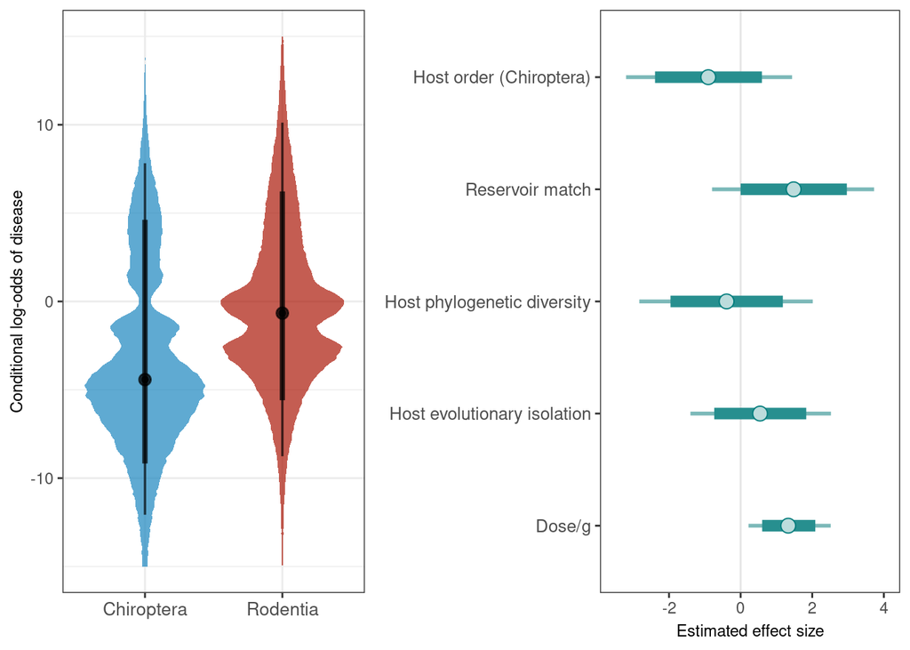

```r
p1 <- cond_eff_plot(model) + scale_y_continuous(lim=c(-15,15)) +
      ylab("Conditional log-odds of disease") + xlab("") +
      theme(axis.title=element_text(size=9),axis.text.x=element_text(size=10)) +
      scale_x_discrete(limits = c("Chiroptera","Rodentia"))

ar1 <- intervals_plot(model)

plot_grid(p1, ar1, align="h", rel_widths =c(0.7,1))
```

```r
# ggsave("../plots_tables/individual_level_disease_resMatch_nolys_comboplot.pdf", width=8, height=3)
```

Sample size: 1229

### Mortality (reservoir match - with HEI and removing lyssaviruses)

```r
lyssaviruses <- viruses$Virus_ICTV[viruses$genus=="Lyssavirus"] %>% unique()
dat_mort_nolys <- dat_mort[!dat_mort$Virus_ICTV%in%lyssaviruses,]

if (!file.exists("../fit_models/indiv_mortality_resMatch_nolys.rds")) {

  mortality_resMatch_nolys <- brm(Mortality_YN ~ Host_order + Reservoir_match +
                      ses_pd + EvoIso +
                       Dose_mass + (1|Dose_unit) +
                      (1|PaperID) +
                      (1|Host_name) + (1|Virus_name) +
                      (1|Host_Upham) + (1|Virus_ICTV) +
                      (1|Route_type),
    data=dat_mort_nolys, family=bernoulli(link = "logit"),
    prior=custom_prior,
    iter=5000, thin=1, cov_ranef = list(Host_Upham = host_cov, Virus_ICTV=virus_cov),
    control=list(adapt_delta=0.97, max_treedepth=12), cores=4,
    save_pars=save_pars(all=TRUE))

  saveRDS(mortality_resMatch_nolys, "../fit_models/indiv_mortality_resMatch_nolys.rds")

} else { mortality_resMatch_nolys <- readRDS("../fit_models/indiv_mortality_resMatch_nolys.rds")}

model <- mortality_resMatch_nolys
# summary(model, prob=0.9)

# save memory
rm(mortality_resMatch_nolys)

param_tab(model)
```

| Parameter | Effects | Mean | CI | CI_low | CI_high | Rhat | Group |
| --- | --- | --- | --- | --- | --- | --- | --- |
| b_Intercept | fixed | -0.36 | 0.90 | -2.30 | 1.59 | 1.00 |  |
| b_Host_orderChiroptera | fixed | -0.94 | 0.90 | -2.88 | 1.04 | 1.00 |  |
| b_Reservoir_match | fixed | -0.42 | 0.90 | -2.17 | 1.34 | 1.00 |  |
| b_ses_pd | fixed | -0.83 | 0.90 | -2.70 | 1.08 | 1.00 |  |
| b_EvoIso | fixed | 1.32 | 0.90 | -0.50 | 3.25 | 1.00 |  |
| b_Dose_mass | fixed | 0.99 | 0.90 | -0.06 | 2.04 | 1.00 |  |
| sd_Dose_unit__Intercept | random | 0.97 | 0.90 | 0.09 | 2.19 | 1.00 | Dose_unit |
| sd_Host_name__Intercept | random | 1.57 | 0.90 | 0.95 | 2.28 | 1.00 | Host_name |
| sd_Host_Upham__Intercept | random | 0.81 | 0.90 | 0.06 | 1.94 | 1.00 | Host_Upham |
| sd_PaperID__Intercept | random | 2.32 | 0.90 | 1.47 | 3.26 | 1.00 | PaperID |
| sd_Route_type__Intercept | random | 1.58 | 0.90 | 0.71 | 2.56 | 1.00 | Route_type |
| sd_Virus_ICTV__Intercept | random | 0.93 | 0.90 | 0.07 | 2.21 | 1.00 | Virus_ICTV |
| sd_Virus_name__Intercept | random | 0.79 | 0.90 | 0.07 | 1.84 | 1.00 | Virus_name |

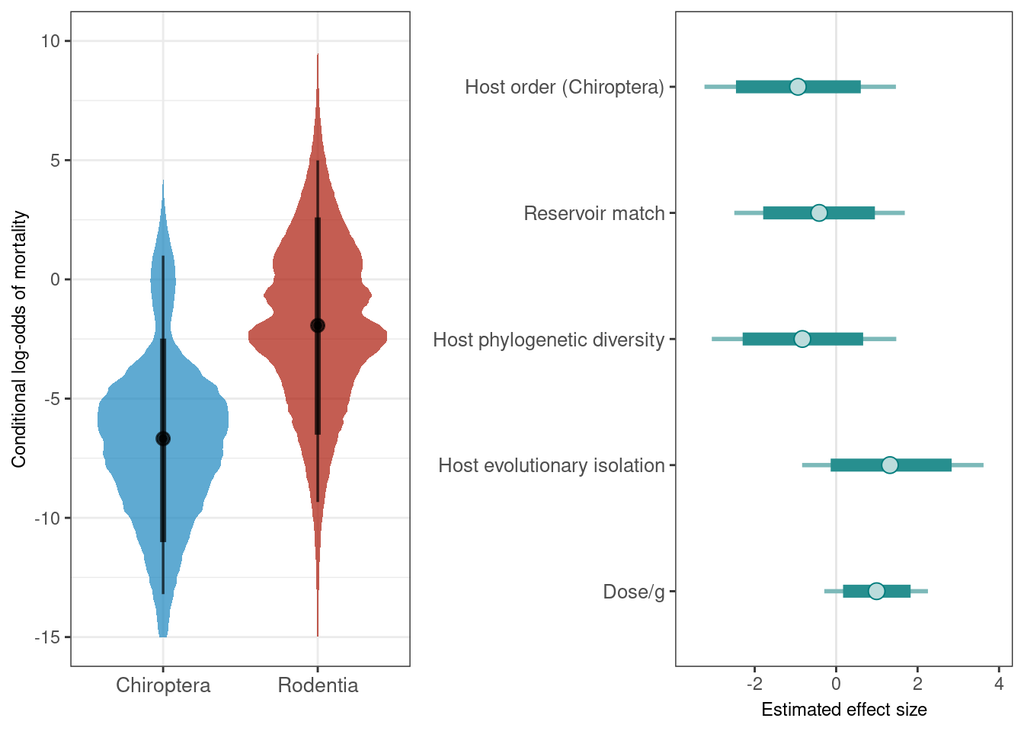

```r
# pp <- brms::posterior_predict(model)
# ppc_dens_overlay(y=model$data$Mortality_YN, pp[1:500, ])

p2 <- cond_eff_plot(model) + scale_y_continuous(lim=c(-15,10)) +
      ylab("Conditional log-odds of mortality") + xlab("") +
      theme(axis.title=element_text(size=9),axis.text.x=element_text(size=10)) +
      scale_x_discrete(limits = c("Chiroptera","Rodentia"))

ar2 <- intervals_plot(model)

plot_grid(p2, ar2, align="h", rel_widths =c(0.7,1))
```

```r
# ggsave("../plots_tables/individual_level_mortality_resMatch_nolys_comboplot.pdf", width=8, height=3)
```

Sample size: 602

### Severity (reservoir match - with HEI and removing lyssaviruses)

```r
lyssaviruses <- viruses$Virus_ICTV[viruses$genus=="Lyssavirus"] %>% unique()
dat_severity_nolys <- dat_severity[!dat_severity$Virus_ICTV%in%lyssaviruses,]

if (!file.exists("../fit_models/indiv_severity_resMatch_nolys.rds")) {

  severity_resMatch_nolys <- brm(severity_rank ~ Host_order + Reservoir_match +
                      ses_pd + EvoIso +
                       Dose_mass + (1|Dose_unit) +
                      (1|PaperID) +
                      (1|Host_name) + (1|Virus_name) +
                      (1|Host_Upham) + (1|Virus_ICTV) +
                      (1|Route_type),
    data=dat_severity_nolys, family=cumulative(probit),
    prior=custom_prior,
    iter=5000, thin=1, cov_ranef = list(Host_Upham = host_cov, Virus_ICTV=virus_cov),
    control=list(adapt_delta=0.98, max_treedepth=12), cores=4,
    save_pars=save_pars(all=TRUE))

  saveRDS(severity_resMatch_nolys, "../fit_models/indiv_severity_resMatch_nolys.rds")


} else { severity_resMatch_nolys <- readRDS("../fit_models/indiv_severity_resMatch_nolys.rds")}

model <- severity_resMatch_nolys
# summary(model, prob=0.9)

# save memory
rm(severity_resMatch_nolys)

# pp <- brms::posterior_predict(model)
# ppc_dens_overlay(y=model$data$severity_rank, pp[1:500, ])

param_tab(model)
```

| Parameter | Effects | Mean | CI | CI_low | CI_high | Rhat | Group |
| --- | --- | --- | --- | --- | --- | --- | --- |
| b_Intercept[1] | fixed | -0.95 | 0.90 | -2.40 | 0.47 | 1.00 |  |
| b_Intercept[2] | fixed | -0.06 | 0.90 | -1.51 | 1.36 | 1.00 |  |
| b_Intercept[3] | fixed | 0.41 | 0.90 | -1.05 | 1.84 | 1.00 |  |
| b_Intercept[4] | fixed | 1.05 | 0.90 | -0.41 | 2.48 | 1.00 |  |
| b_Host_orderChiroptera | fixed | -0.57 | 0.90 | -2.19 | 1.11 | 1.00 |  |
| b_Reservoir_match | fixed | 0.80 | 0.90 | -0.58 | 2.17 | 1.00 |  |
| b_ses_pd | fixed | -0.47 | 0.90 | -1.94 | 0.98 | 1.00 |  |
| b_EvoIso | fixed | 0.37 | 0.90 | -0.76 | 1.59 | 1.00 |  |
| b_Dose_mass | fixed | 0.72 | 0.90 | 0.38 | 1.07 | 1.00 |  |
| sd_Dose_unit__Intercept | random | 0.71 | 0.90 | 0.06 | 1.70 | 1.00 | Dose_unit |
| sd_Host_name__Intercept | random | 1.84 | 0.90 | 1.31 | 2.42 | 1.00 | Host_name |
| sd_Host_Upham__Intercept | random | 0.89 | 0.90 | 0.08 | 2.04 | 1.00 | Host_Upham |
| sd_PaperID__Intercept | random | 1.93 | 0.90 | 1.39 | 2.56 | 1.00 | PaperID |
| sd_Route_type__Intercept | random | 1.45 | 0.90 | 0.79 | 2.28 | 1.00 | Route_type |
| sd_Virus_ICTV__Intercept | random | 0.80 | 0.90 | 0.06 | 1.88 | 1.00 | Virus_ICTV |
| sd_Virus_name__Intercept | random | 0.75 | 0.90 | 0.06 | 1.72 | 1.00 | Virus_name |

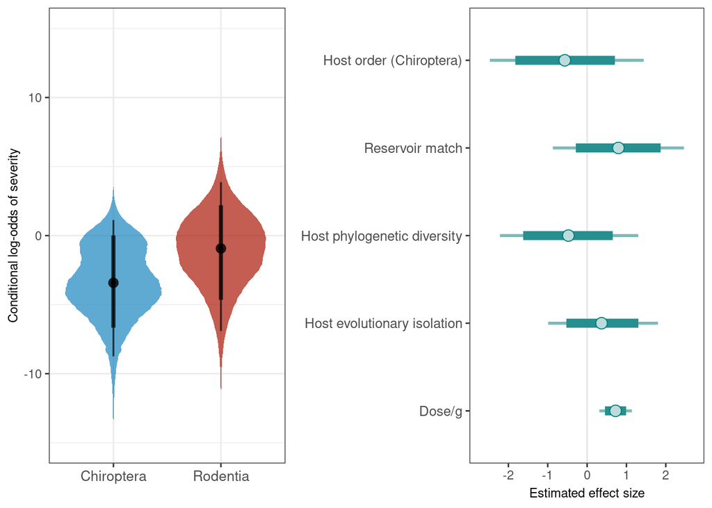

```r
p3 <- cond_eff_plot(model) + scale_y_continuous(lim=c(-15,15)) +
      ylab("Conditional log-odds of severity") + xlab("") +
      theme(axis.title=element_text(size=9),axis.text.x=element_text(size=10)) +
      scale_x_discrete(limits = c("Chiroptera","Rodentia"))

ar3 <- intervals_plot(model)

plot_grid(p3, ar3, align="h", rel_widths =c(0.7,1))
```

```r
# ggsave("../plots_tables/individual_level_severity_resMatch_nolys_comboplot.pdf", width=8, height=3)
```

Sample size: 1229

### Joint results plots (reservoir match - with HEI and removing lyssaviruses)

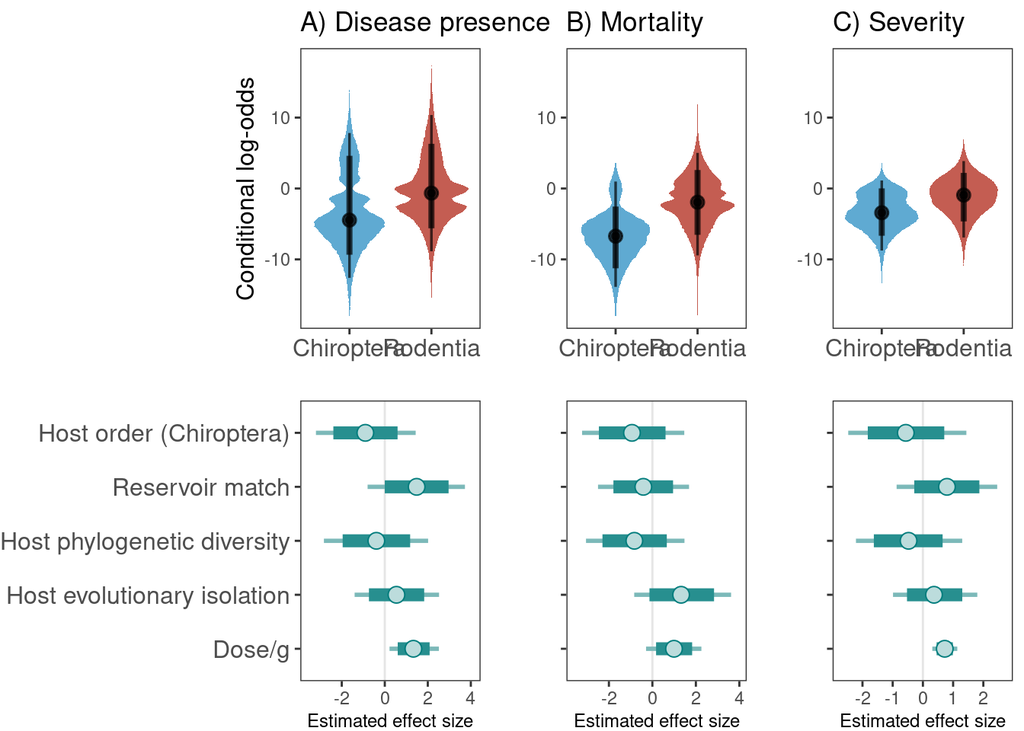

```r
## Joint plot
global_ylim <-  scale_y_continuous(lim=c(-18,18))
padding <- theme(plot.margin = unit(c(t=0, r=-3, b=0, l=0), "cm"))

joint_plot <- joint_conditionals_intervals(p1,p2,p3,global_ylim,padding,ar1,ar2,ar3)
```

```r
ggsave("../plots_tables/individual_level_conditionals_intervals_resMatch_nolys.pdf", joint_plot, width=10.5, height=5.5)
```

## Individual level models (excluding Lyssaviruses)

### Presence of disease (excluding Lyssaviruses)

```r
lyssaviruses <- viruses$Virus_ICTV[viruses$genus=="Lyssavirus"] %>% unique()
dat_dis_nolys <- dat_dis[!dat_dis$Virus_ICTV%in%lyssaviruses,]

if (!file.exists("../fit_models/indiv_disease_nolys.rds")) {

  disease_nolys <- brm(Disease_YN ~ Host_order +
                      ses_pd + EvoIso +
                       Dose_mass + (1|Dose_unit) +
                      (1|PaperID) +
                      (1|Host_name) + (1|Virus_name) +
                      (1|Host_Upham) + (1|Virus_ICTV) +
                      (1|Route_type),
    data=dat_dis_nolys, family=bernoulli(link = "logit"),
    prior=custom_prior,
    iter=5000, thin=1, cov_ranef = list(Host_Upham = host_cov, Virus_ICTV=virus_cov),
    control=list(adapt_delta=0.95, max_treedepth=12), cores=4,
    save_pars=save_pars(all=TRUE))

  saveRDS(disease_nolys, "../fit_models/indiv_disease_nolys.rds")

} else { disease_nolys <- readRDS("../fit_models/indiv_disease_nolys.rds")}

model <- disease_nolys
# summary(model, prob=0.9)

# save memory
rm(disease_nolys)

# pp <- brms::posterior_predict(model)
# ppc_dens_overlay(y=model$data$Disease_YN, pp[1:500, ])

param_tab(model)
```

| Parameter | Effects | Mean | CI | CI_low | CI_high | Rhat | Group |
| --- | --- | --- | --- | --- | --- | --- | --- |
| b_Intercept | fixed | 0.31 | 0.90 | -1.57 | 2.17 | 1.00 |  |
| b_Host_orderChiroptera | fixed | -0.68 | 0.90 | -2.63 | 1.29 | 1.00 |  |
| b_ses_pd | fixed | -0.60 | 0.90 | -2.63 | 1.44 | 1.00 |  |
| b_EvoIso | fixed | 0.46 | 0.90 | -1.09 | 2.06 | 1.00 |  |
| b_Dose_mass | fixed | 1.38 | 0.90 | 0.44 | 2.35 | 1.00 |  |
| sd_Dose_unit__Intercept | random | 0.93 | 0.90 | 0.09 | 2.10 | 1.00 | Dose_unit |
| sd_Host_name__Intercept | random | 2.83 | 0.90 | 2.06 | 3.65 | 1.00 | Host_name |
| sd_Host_Upham__Intercept | random | 0.87 | 0.90 | 0.07 | 2.16 | 1.00 | Host_Upham |
| sd_PaperID__Intercept | random | 3.80 | 0.90 | 2.89 | 4.77 | 1.00 | PaperID |
| sd_Route_type__Intercept | random | 1.42 | 0.90 | 0.43 | 2.46 | 1.00 | Route_type |
| sd_Virus_ICTV__Intercept | random | 1.09 | 0.90 | 0.09 | 2.51 | 1.00 | Virus_ICTV |
| sd_Virus_name__Intercept | random | 1.36 | 0.90 | 0.13 | 2.83 | 1.00 | Virus_name |

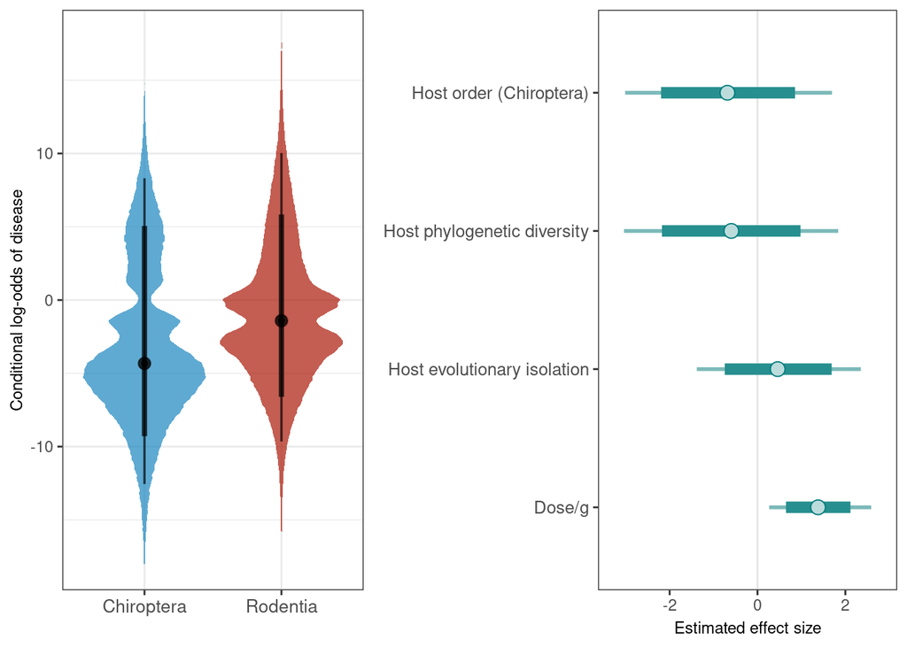

```r
p1 <- cond_eff_plot(model) + scale_y_continuous(lim=c(-18,18)) +
      ylab("Conditional log-odds of disease") + xlab("") +
      theme(axis.title=element_text(size=9),axis.text.x=element_text(size=10)) +
      scale_x_discrete(limits = c("Chiroptera","Rodentia"))

ar1 <- intervals_plot(model)

plot_grid(p1, ar1, align="h", rel_widths =c(0.7,1))
```

```r
# ggsave("../plots_tables/individual_level_disease_nolys_comboplot.pdf", width=8, height=3)
```

Sample size: 1308

### Mortality (excluding Lyssaviruses)

```r
lyssaviruses <- viruses$Virus_ICTV[viruses$genus=="Lyssavirus"] %>% unique()
dat_mort_nolys <- dat_mort[!dat_mort$Virus_ICTV%in%lyssaviruses,]

if (!file.exists("../fit_models/indiv_mortality_nolys.rds")) {

  mort_nolys <- brm(Mortality_YN ~ Host_order +
                      ses_pd + EvoIso +
                       Dose_mass + (1|Dose_unit) +
                      (1|PaperID) +
                      (1|Host_name) + (1|Virus_name) +
                      (1|Host_Upham) + (1|Virus_ICTV) +
                      (1|Route_type),
    data=dat_mort_nolys, family=bernoulli(link = "logit"),
    prior=custom_prior,
    iter=5000, thin=1, cov_ranef = list(Host_Upham = host_cov, Virus_ICTV=virus_cov),
    control=list(adapt_delta=0.90, max_treedepth=12), cores=4,
    save_pars=save_pars(all=TRUE))

  saveRDS(mort_nolys, "../fit_models/indiv_mortality_nolys.rds")

} else { mort_nolys <- readRDS("../fit_models/indiv_mortality_nolys.rds")}

model <- mort_nolys
# summary(model, prob=0.9)

# save memory
rm(mort_nolys)

# pp <- brms::posterior_predict(model)
# ppc_dens_overlay(y=model$data$Disease_YN, pp[1:500, ])

param_tab(model)
```

| Parameter | Effects | Mean | CI | CI_low | CI_high | Rhat | Group |
| --- | --- | --- | --- | --- | --- | --- | --- |
| b_Intercept | fixed | -0.72 | 0.90 | -2.37 | 1.00 | 1.00 |  |
| b_Host_orderChiroptera | fixed | -0.77 | 0.90 | -2.74 | 1.23 | 1.00 |  |
| b_ses_pd | fixed | -1.04 | 0.90 | -2.84 | 0.79 | 1.00 |  |
| b_EvoIso | fixed | 1.42 | 0.90 | -0.34 | 3.24 | 1.00 |  |
| b_Dose_mass | fixed | 0.96 | 0.90 | -0.08 | 2.02 | 1.00 |  |
| sd_Dose_unit__Intercept | random | 0.93 | 0.90 | 0.08 | 2.16 | 1.00 | Dose_unit |
| sd_Host_name__Intercept | random | 1.61 | 0.90 | 0.96 | 2.35 | 1.00 | Host_name |
| sd_Host_Upham__Intercept | random | 0.83 | 0.90 | 0.07 | 1.98 | 1.00 | Host_Upham |
| sd_PaperID__Intercept | random | 2.37 | 0.90 | 1.52 | 3.32 | 1.00 | PaperID |
| sd_Route_type__Intercept | random | 1.49 | 0.90 | 0.70 | 2.45 | 1.00 | Route_type |
| sd_Virus_ICTV__Intercept | random | 0.91 | 0.90 | 0.07 | 2.14 | 1.00 | Virus_ICTV |
| sd_Virus_name__Intercept | random | 0.73 | 0.90 | 0.06 | 1.78 | 1.00 | Virus_name |

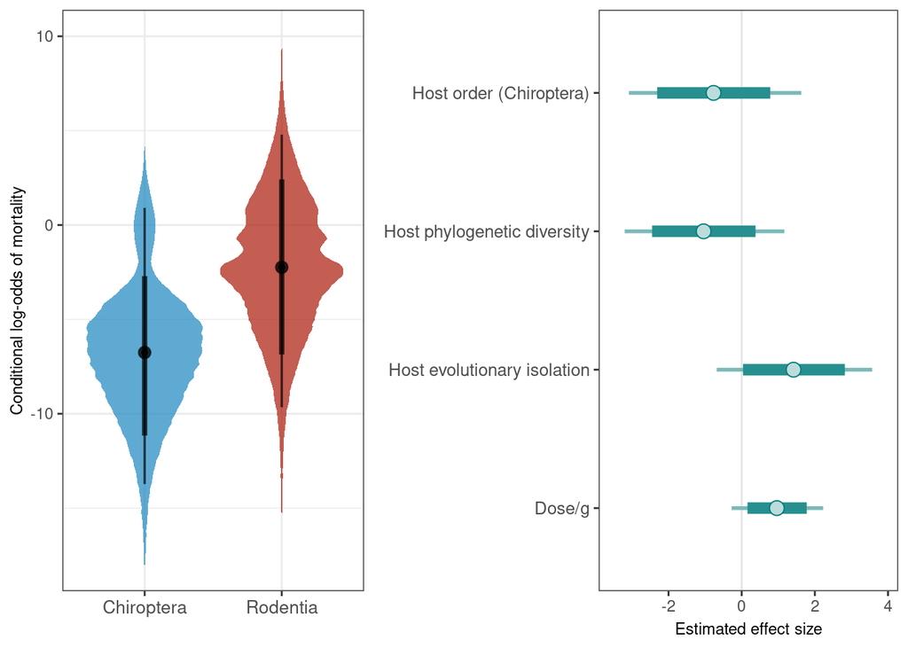

```r
p2 <- cond_eff_plot(model) + scale_y_continuous(lim=c(-18,10)) +
      ylab("Conditional log-odds of mortality") + xlab("") +
      theme(axis.title=element_text(size=9),axis.text.x=element_text(size=10)) +
      scale_x_discrete(limits = c("Chiroptera","Rodentia"))

ar2 <- intervals_plot(model)

plot_grid(p2, ar2, align="h", rel_widths =c(0.7,1))
```

```r
# ggsave("../plots_tables/individual_level_mortality_nolys_comboplot.pdf", width=8, height=3)
```

Sample size: 648

### Severity (excluding Lyssaviruses)

```r
lyssaviruses <- viruses$Virus_ICTV[viruses$genus=="Lyssavirus"] %>% unique()
dat_severity_nolys <- dat_severity[!dat_severity$Virus_ICTV%in%lyssaviruses,]

if (!file.exists("../fit_models/indiv_severity_nolys.rds")) {

  severity_nolys <- brm(severity_rank ~ Host_order +
                      ses_pd + EvoIso +
                       Dose_mass + (1|Dose_unit) +
                      (1|PaperID) +
                      (1|Host_name) + (1|Virus_name) +
                      (1|Host_Upham) + (1|Virus_ICTV) +
                      (1|Route_type),
    data=dat_severity_nolys, family=cumulative(probit),
    prior=custom_prior,
    iter=5000, thin=1, cov_ranef = list(Host_Upham = host_cov, Virus_ICTV=virus_cov),
    control=list(adapt_delta=0.98, max_treedepth=12), cores=4,
    save_pars=save_pars(all=TRUE))

  saveRDS(severity_nolys, "../fit_models/indiv_severity_nolys.rds")

} else { severity_nolys <- readRDS("../fit_models/indiv_severity_nolys.rds")}

model <- severity_nolys
# summary(model, prob=0.9)

# save memory
rm(severity_nolys)

# pp <- brms::posterior_predict(model)
# ppc_dens_overlay(y=model$data$Disease_YN, pp[1:500, ])

param_tab(model)
```

| Parameter | Effects | Mean | CI | CI_low | CI_high | Rhat | Group |
| --- | --- | --- | --- | --- | --- | --- | --- |
| b_Intercept[1] | fixed | -1.26 | 0.90 | -2.51 | -0.01 | 1.00 |  |
| b_Intercept[2] | fixed | -0.28 | 0.90 | -1.52 | 0.97 | 1.00 |  |
| b_Intercept[3] | fixed | 0.17 | 0.90 | -1.07 | 1.42 | 1.00 |  |
| b_Intercept[4] | fixed | 0.78 | 0.90 | -0.47 | 2.04 | 1.00 |  |
| b_Host_orderChiroptera | fixed | -0.51 | 0.90 | -2.08 | 1.09 | 1.00 |  |
| b_ses_pd | fixed | -0.67 | 0.90 | -2.01 | 0.66 | 1.00 |  |
| b_EvoIso | fixed | 0.23 | 0.90 | -0.55 | 1.03 | 1.00 |  |
| b_Dose_mass | fixed | 0.73 | 0.90 | 0.38 | 1.07 | 1.00 |  |
| sd_Dose_unit__Intercept | random | 0.77 | 0.90 | 0.08 | 1.75 | 1.00 | Dose_unit |
| sd_Host_name__Intercept | random | 1.89 | 0.90 | 1.36 | 2.46 | 1.00 | Host_name |
| sd_Host_Upham__Intercept | random | 0.86 | 0.90 | 0.07 | 2.00 | 1.00 | Host_Upham |
| sd_PaperID__Intercept | random | 2.05 | 0.90 | 1.50 | 2.66 | 1.00 | PaperID |
| sd_Route_type__Intercept | random | 1.37 | 0.90 | 0.74 | 2.16 | 1.00 | Route_type |
| sd_Virus_ICTV__Intercept | random | 0.72 | 0.90 | 0.06 | 1.68 | 1.00 | Virus_ICTV |
| sd_Virus_name__Intercept | random | 0.43 | 0.90 | 0.03 | 1.15 | 1.00 | Virus_name |

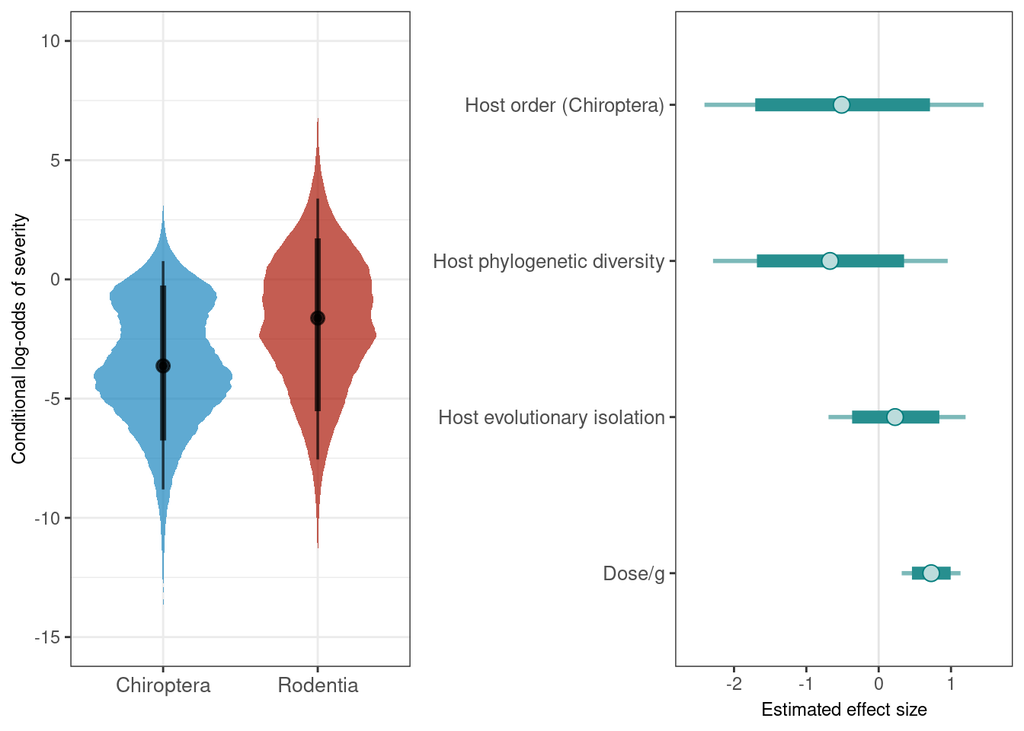

```r
p3 <- cond_eff_plot(model) + scale_y_continuous(lim=c(-15,10)) +
      ylab("Conditional log-odds of severity") + xlab("") +
      theme(axis.title=element_text(size=9),axis.text.x=element_text(size=10)) +
      scale_x_discrete(limits = c("Chiroptera","Rodentia"))

ar3 <- intervals_plot(model)

plot_grid(p3, ar3, align="h", rel_widths =c(0.7,1))
```

```r
# ggsave("../plots_tables/individual_level_severity_nolys_comboplot.pdf", width=8, height=3)
```

Sample size: 1308

### Joint results plots (excluding Lyssaviruses)

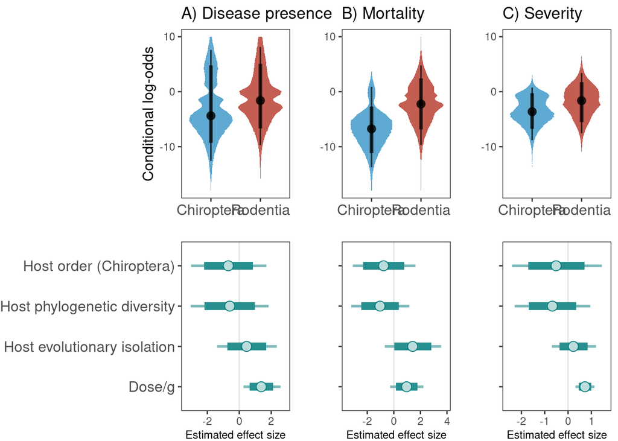

```r
## Joint plot
global_ylim <-  scale_y_continuous(lim=c(-18,10))
padding <- theme(plot.margin = unit(c(t=0, r=-3, b=0, l=0), "cm"))

joint_plot <- joint_conditionals_intervals(p1,p2,p3,global_ylim,padding,ar1,ar2,ar3)
```

```r
ggsave("../plots_tables/individual_level_conditionals_intervals_nolys.pdf", joint_plot, width=10.5, height=5.5)
```

## Individual level models (only heterologous hosts)

### Presence of disease (heterologous hosts)

```r
dat_dis_heteros <- dat_dis[dat_dis$Reservoir_match%in%0,]

if (!file.exists("../fit_models/indiv_disease_heteroHosts.rds")) {

  disease_heteros <- brm(Disease_YN ~ Host_order +
                      ses_pd + EvoIso +
                       Dose_mass + (1|Dose_unit) +
                      (1|PaperID) +
                      (1|Host_name) + (1|Virus_name) +
                      (1|Host_Upham) + (1|Virus_ICTV) +
                      (1|Route_type),
    data=dat_dis_heteros, family=bernoulli(link = "logit"),
    prior=custom_prior,
    iter=5000, thin=1, cov_ranef = list(Host_Upham = host_cov, Virus_ICTV=virus_cov),
    control=list(adapt_delta=0.95, max_treedepth=12), cores=4,
    save_pars=save_pars(all=TRUE))

  saveRDS(disease_heteros, "../fit_models/indiv_disease_heteroHosts.rds")

} else { disease_heteros <- readRDS("../fit_models/indiv_disease_heteroHosts.rds")}

model <- disease_heteros
# summary(model, prob=0.9)

# save memory
rm(disease_heteros)

# pp <- brms::posterior_predict(model)
# ppc_dens_overlay(y=model$data$Disease_YN, pp[1:500, ])

param_tab(model)
```

| Parameter | Effects | Mean | CI | CI_low | CI_high | Rhat | Group |
| --- | --- | --- | --- | --- | --- | --- | --- |
| b_Intercept | fixed | 0.07 | 0.90 | -1.83 | 1.98 | 1.00 |  |
| b_Host_orderChiroptera | fixed | -1.33 | 0.90 | -3.08 | 0.46 | 1.00 |  |
| b_ses_pd | fixed | -0.20 | 0.90 | -2.35 | 1.95 | 1.00 |  |
| b_EvoIso | fixed | 1.09 | 0.90 | -0.60 | 2.96 | 1.00 |  |
| b_Dose_mass | fixed | 1.73 | 0.90 | 0.83 | 2.66 | 1.00 |  |
| sd_Dose_unit__Intercept | random | 1.21 | 0.90 | 0.17 | 2.36 | 1.00 | Dose_unit |
| sd_Host_name__Intercept | random | 2.50 | 0.90 | 1.77 | 3.30 | 1.00 | Host_name |
| sd_Host_Upham__Intercept | random | 0.79 | 0.90 | 0.07 | 1.92 | 1.00 | Host_Upham |
| sd_PaperID__Intercept | random | 0.85 | 0.90 | 0.07 | 1.99 | 1.00 | PaperID |
| sd_Route_type__Intercept | random | 1.81 | 0.90 | 1.06 | 2.71 | 1.00 | Route_type |
| sd_Virus_ICTV__Intercept | random | 0.78 | 0.90 | 0.06 | 1.94 | 1.00 | Virus_ICTV |
| sd_Virus_name__Intercept | random | 0.82 | 0.90 | 0.07 | 1.93 | 1.00 | Virus_name |

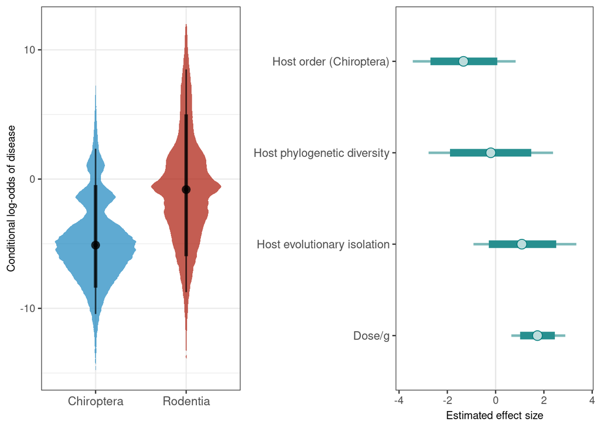

```r
p1 <- cond_eff_plot(model) + scale_y_continuous(lim=c(-15,12)) +
      ylab("Conditional log-odds of disease") + xlab("") +
      theme(axis.title=element_text(size=9),axis.text.x=element_text(size=10)) +
      scale_x_discrete(limits = c("Chiroptera","Rodentia"))

ar1 <- intervals_plot(model)

plot_grid(p1, ar1, align="h", rel_widths =c(0.7,1))
```

```r
# ggsave("../plots_tables/individual_level_disease_heteroHosts_comboplot.pdf", width=8, height=3)
```

Sample size: 806

### Mortality (heterologous hosts)

```r
dat_mort_heteros <- dat_mort[dat_mort$Reservoir_match%in%0,]

if (!file.exists("../fit_models/indiv_mortality_heteroHosts.rds")) {

  mort_heteros <- brm(Mortality_YN ~ Host_order  +
                      ses_pd + EvoIso +
                       Dose_mass + (1|Dose_unit) +
                      (1|PaperID) +
                      (1|Host_name) + (1|Virus_name) +
                      (1|Host_Upham) + (1|Virus_ICTV) +
                      (1|Route_type),
    data=dat_mort_heteros, family=bernoulli(link = "logit"),
    prior=custom_prior,
    iter=5000, thin=1,
    cov_ranef = list(Host_Upham = host_cov, Virus_ICTV=virus_cov),
    control=list(adapt_delta=0.95, max_treedepth=12), cores=4,
    save_pars=save_pars(all=TRUE))

  saveRDS(mort_heteros, "../fit_models/indiv_mortality_heteroHosts.rds")

} else { mort_heteros <- readRDS("../fit_models/indiv_mortality_heteroHosts.rds")}

model <- mort_heteros
# summary(model, prob=0.9)

# save memory
rm(mort_heteros)

# pp <- brms::posterior_predict(model)
# ppc_dens_overlay(y=model$data$Disease_YN, pp[1:500, ])

param_tab(model)
```

| Parameter | Effects | Mean | CI | CI_low | CI_high | Rhat | Group |
| --- | --- | --- | --- | --- | --- | --- | --- |
| b_Intercept | fixed | -0.88 | 0.90 | -2.69 | 0.93 | 1.00 |  |
| b_Host_orderChiroptera | fixed | -0.59 | 0.90 | -2.52 | 1.38 | 1.00 |  |
| b_ses_pd | fixed | 0.07 | 0.90 | -2.12 | 2.30 | 1.00 |  |
| b_EvoIso | fixed | 1.07 | 0.90 | -0.80 | 3.06 | 1.00 |  |
| b_Dose_mass | fixed | 0.62 | 0.90 | -0.41 | 1.68 | 1.00 |  |
| sd_Dose_unit__Intercept | random | 0.99 | 0.90 | 0.09 | 2.18 | 1.00 | Dose_unit |
| sd_Host_name__Intercept | random | 1.29 | 0.90 | 0.37 | 2.25 | 1.00 | Host_name |
| sd_Host_Upham__Intercept | random | 0.89 | 0.90 | 0.08 | 2.02 | 1.00 | Host_Upham |
| sd_PaperID__Intercept | random | 1.60 | 0.90 | 0.29 | 2.84 | 1.00 | PaperID |
| sd_Route_type__Intercept | random | 1.49 | 0.90 | 0.57 | 2.50 | 1.00 | Route_type |
| sd_Virus_ICTV__Intercept | random | 0.80 | 0.90 | 0.06 | 1.99 | 1.00 | Virus_ICTV |
| sd_Virus_name__Intercept | random | 0.84 | 0.90 | 0.07 | 1.98 | 1.00 | Virus_name |

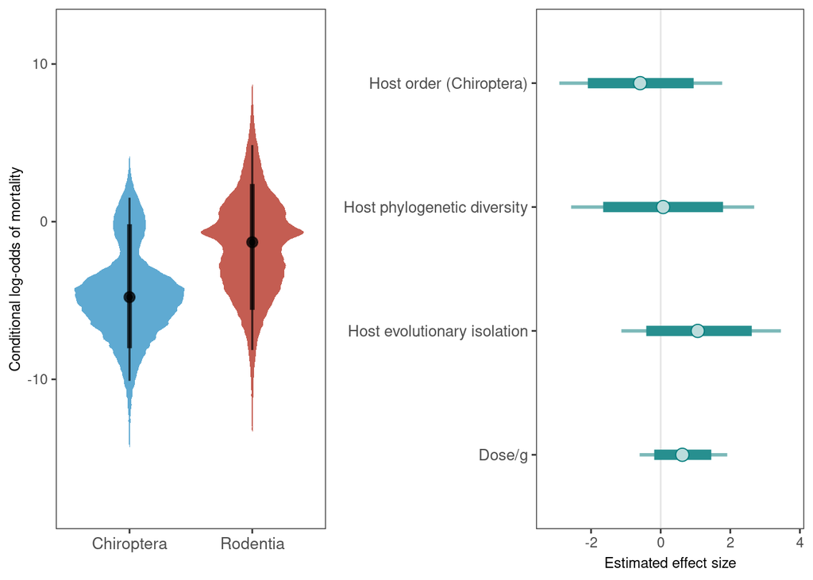

```r
p2 <- cond_eff_plot(model) + scale_y_continuous(lim=c(-18,12)) +
      ylab("Conditional log-odds of mortality") + xlab("") +
      theme(axis.title=element_text(size=9),axis.text.x=element_text(size=10),
            panel.grid.major = element_blank(),
            panel.grid.minor = element_blank())+
      scale_x_discrete(limits = c("Chiroptera","Rodentia"))

ar2 <- intervals_plot(model)

plot_grid(p2, ar2, align="h", rel_widths =c(0.7,1))
```

```r
# ggsave("../plots_tables/individual_level_mortality_heteroHosts_comboplot.pdf", width=8, height=3)
```

Sample size: 315

### Severity (heterologous hosts)

```r
dat_severity_heteros <- dat_severity[dat_severity$Reservoir_match%in%0,]

if (!file.exists("../fit_models/indiv_severity_heteroHosts.rds")) {

  severity_heteros <- brm(severity_rank ~ Host_order  +
                      ses_pd + EvoIso +
                       Dose_mass + (1|Dose_unit) +
                      (1|PaperID) +
                      (1|Host_name) + (1|Virus_name) +
                      (1|Host_Upham) + (1|Virus_ICTV) +
                      (1|Route_type),
    data=dat_severity_heteros, family=cumulative(probit),
    prior=custom_prior,
    iter=5000, thin=1, cov_ranef = list(Host_Upham = host_cov, Virus_ICTV=virus_cov),
    control=list(adapt_delta=0.98, max_treedepth=12), cores=4,
    save_pars=save_pars(all=TRUE))

  saveRDS(severity_heteros, "../fit_models/indiv_severity_heteroHosts.rds")

} else { severity_heteros <- readRDS("../fit_models/indiv_severity_heteroHosts.rds")}

model <- severity_heteros
# summary(model, prob=0.9)

# save memory
rm(severity_heteros)

# pp <- brms::posterior_predict(model)
# ppc_dens_overlay(y=model$data$Disease_YN, pp[1:500, ])

param_tab(model)
```

| Parameter | Effects | Mean | CI | CI_low | CI_high | Rhat | Group |
| --- | --- | --- | --- | --- | --- | --- | --- |
| b_Intercept[1] | fixed | -0.46 | 0.90 | -1.85 | 0.90 | 1.00 |  |
| b_Intercept[2] | fixed | -0.24 | 0.90 | -1.63 | 1.12 | 1.00 |  |
| b_Intercept[3] | fixed | 0.12 | 0.90 | -1.26 | 1.48 | 1.00 |  |
| b_Intercept[4] | fixed | 0.70 | 0.90 | -0.68 | 2.06 | 1.00 |  |
| b_Host_orderChiroptera | fixed | -0.68 | 0.90 | -2.09 | 0.80 | 1.00 |  |
| b_ses_pd | fixed | -0.22 | 0.90 | -2.04 | 1.59 | 1.00 |  |
| b_EvoIso | fixed | 0.82 | 0.90 | -0.57 | 2.39 | 1.00 |  |
| b_Dose_mass | fixed | 0.66 | 0.90 | 0.31 | 1.00 | 1.00 |  |
| sd_Dose_unit__Intercept | random | 0.64 | 0.90 | 0.05 | 1.56 | 1.00 | Dose_unit |
| sd_Host_name__Intercept | random | 1.19 | 0.90 | 0.68 | 1.72 | 1.00 | Host_name |
| sd_Host_Upham__Intercept | random | 0.70 | 0.90 | 0.05 | 1.66 | 1.00 | Host_Upham |
| sd_PaperID__Intercept | random | 1.10 | 0.90 | 0.52 | 1.73 | 1.00 | PaperID |
| sd_Route_type__Intercept | random | 1.27 | 0.90 | 0.64 | 2.09 | 1.00 | Route_type |
| sd_Virus_ICTV__Intercept | random | 0.69 | 0.90 | 0.06 | 1.68 | 1.00 | Virus_ICTV |
| sd_Virus_name__Intercept | random | 0.64 | 0.90 | 0.06 | 1.50 | 1.00 | Virus_name |

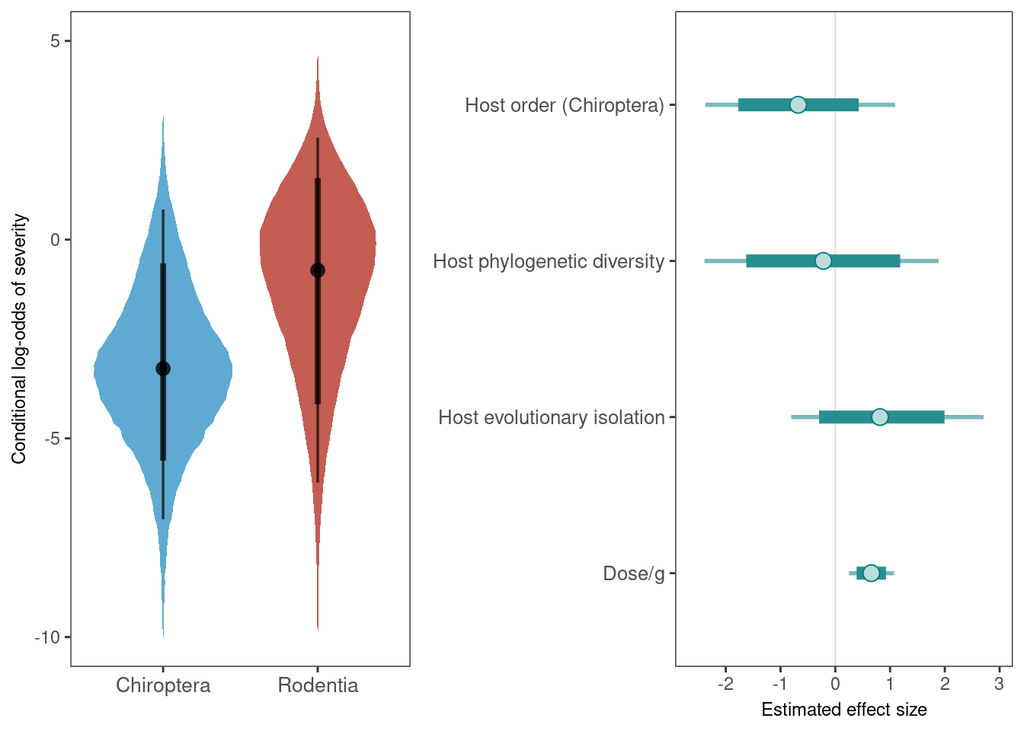

```r
p3 <- cond_eff_plot(model) + scale_y_continuous(lim=c(-10,5)) +
      ylab("Conditional log-odds of severity") + xlab("") +
      theme(axis.title=element_text(size=9),axis.text.x=element_text(size=10),
            panel.grid.major = element_blank(),
            panel.grid.minor = element_blank())+
      scale_x_discrete(limits = c("Chiroptera","Rodentia"))

ar3 <- intervals_plot(model)

plot_grid(p3, ar3, align="h", rel_widths =c(0.7,1))
```

```r
# ggsave("../plots_tables/individual_level_severity_heteroHosts_comboplot.pdf", width=8, height=3)
```

Sample size: 806

### Joint results plots (individual level heterologous host models)

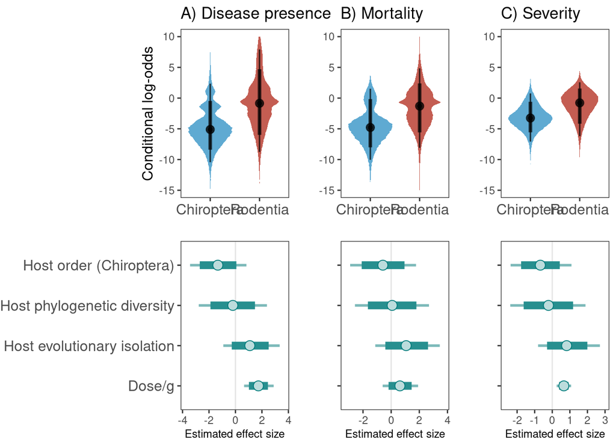

```r
## Joint plot
global_ylim <-  scale_y_continuous(lim=c(-15,10))
padding <- theme(plot.margin = unit(c(t=0, r=-3, b=0, l=0), "cm"))

joint_plot <- joint_conditionals_intervals(p1,p2,p3,global_ylim,padding,ar1,ar2,ar3)
```

```r
ggsave("../plots_tables/individual_level_conditionals_intervals_heteroHosts.pdf", joint_plot, width=10.5, height=5.5)
```

## Individual level models (only homologous hosts)

### Presence of disease (homologous hosts)

```r
dat_dis_homos <- dat_dis[dat_dis$Reservoir_match%in%1,]

if (!file.exists("../fit_models/indiv_disease_homoHosts.rds")) {

  disease_homos <- brm(Disease_YN ~ Host_order +
                      ses_pd + EvoIso +
                       Dose_mass + (1|Dose_unit) +
                      (1|PaperID) +
                      (1|Host_name) + (1|Virus_name) +
                      (1|Host_Upham) + (1|Virus_ICTV) +
                      (1|Route_type),
    data=dat_dis_homos, family=bernoulli(link = "logit"),
    prior=custom_prior,
    iter=5000, thin=1, cov_ranef = list(Host_Upham = host_cov, Virus_ICTV=virus_cov),
    control=list(adapt_delta=0.98, max_treedepth=12), cores=4,
    save_pars=save_pars(all=TRUE))

  saveRDS(disease_homos, "../fit_models/indiv_disease_homoHosts.rds")

} else { disease_homos <- readRDS("../fit_models/indiv_disease_homoHosts.rds")}

model <- disease_homos
# summary(model, prob=0.9)

# save memory
rm(disease_homos)

# pp <- brms::posterior_predict(model)
# ppc_dens_overlay(y=model$data$Disease_YN, pp[1:500, ])

param_tab(model)
```

| Parameter | Effects | Mean | CI | CI_low | CI_high | Rhat | Group |
| --- | --- | --- | --- | --- | --- | --- | --- |
| b_Intercept | fixed | 0.35 | 0.90 | -1.82 | 2.50 | 1.00 |  |
| b_Host_orderChiroptera | fixed | -0.44 | 0.90 | -2.53 | 1.68 | 1.00 |  |
| b_ses_pd | fixed | -0.61 | 0.90 | -2.26 | 1.08 | 1.00 |  |
| b_EvoIso | fixed | 0.25 | 0.90 | -1.25 | 1.74 | 1.00 |  |
| b_Dose_mass | fixed | -0.29 | 0.90 | -1.02 | 0.42 | 1.00 |  |
| sd_Dose_unit__Intercept | random | 0.99 | 0.90 | 0.08 | 2.29 | 1.00 | Dose_unit |
| sd_Host_name__Intercept | random | 2.63 | 0.90 | 1.69 | 3.63 | 1.00 | Host_name |
| sd_Host_Upham__Intercept | random | 0.89 | 0.90 | 0.07 | 2.13 | 1.00 | Host_Upham |
| sd_PaperID__Intercept | random | 2.79 | 0.90 | 2.00 | 3.69 | 1.00 | PaperID |
| sd_Route_type__Intercept | random | 1.87 | 0.90 | 1.20 | 2.71 | 1.00 | Route_type |
| sd_Virus_ICTV__Intercept | random | 1.10 | 0.90 | 0.10 | 2.43 | 1.00 | Virus_ICTV |
| sd_Virus_name__Intercept | random | 0.67 | 0.90 | 0.05 | 1.72 | 1.00 | Virus_name |

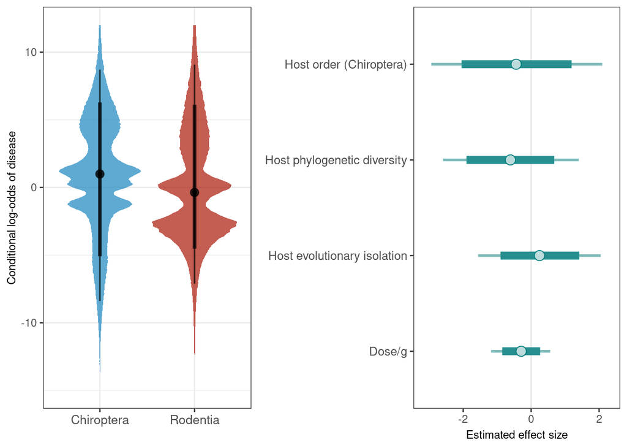

```r
p1 <- cond_eff_plot(model) + scale_y_continuous(lim=c(-15,12)) +
      ylab("Conditional log-odds of disease") + xlab("") +
      theme(axis.title=element_text(size=9),axis.text.x=element_text(size=10)) +
      scale_x_discrete(limits = c("Chiroptera","Rodentia"))

ar1 <- intervals_plot(model)

plot_grid(p1, ar1, align="h", rel_widths =c(0.7,1))
```

```r
# ggsave("../plots_tables/individual_level_disease_homoHosts_comboplot.pdf", width=8, height=3)
```

Sample size: 1114

### Mortality (homologous hosts)

```r
dat_mort_homos <- dat_mort[dat_mort$Reservoir_match%in%1,]

if (!file.exists("../fit_models/indiv_mortality_homoHosts.rds")) {

  mort_homos <- brm(Mortality_YN ~ Host_order  +
                      ses_pd + EvoIso +
                       Dose_mass + (1|Dose_unit) +
                      (1|PaperID) +
                      (1|Host_name) + (1|Virus_name) +
                      (1|Host_Upham) + (1|Virus_ICTV) +
                      (1|Route_type),
    data=dat_mort_homos, family=bernoulli(link = "logit"),
    prior=custom_prior,
    iter=5000, thin=1,
    cov_ranef = list(Host_Upham = host_cov, Virus_ICTV=virus_cov),
    control=list(adapt_delta=0.95, max_treedepth=12), cores=4,
    save_pars=save_pars(all=TRUE))

  saveRDS(mort_homos, "../fit_models/indiv_mortality_homoHosts.rds")

} else { mort_homos <- readRDS("../fit_models/indiv_mortality_homoHosts.rds")}

model <- mort_homos
# summary(model, prob=0.9)

# save memory
rm(mort_homos)

# pp <- brms::posterior_predict(model)
# ppc_dens_overlay(y=model$data$Disease_YN, pp[1:500, ])

param_tab(model)
```

| Parameter | Effects | Mean | CI | CI_low | CI_high | Rhat | Group |
| --- | --- | --- | --- | --- | --- | --- | --- |
| b_Intercept | fixed | -1.07 | 0.90 | -2.98 | 0.84 | 1.00 |  |
| b_Host_orderChiroptera | fixed | 0.55 | 0.90 | -1.48 | 2.55 | 1.00 |  |
| b_ses_pd | fixed | -1.70 | 0.90 | -3.36 | -4.00e-03 | 1.00 |  |
| b_EvoIso | fixed | 0.34 | 0.90 | -1.36 | 2.08 | 1.00 |  |
| b_Dose_mass | fixed | 0.62 | 0.90 | -0.14 | 1.37 | 1.00 |  |
| sd_Dose_unit__Intercept | random | 1.21 | 0.90 | 0.19 | 2.34 | 1.00 | Dose_unit |
| sd_Host_name__Intercept | random | 1.86 | 0.90 | 1.13 | 2.67 | 1.00 | Host_name |
| sd_Host_Upham__Intercept | random | 0.73 | 0.90 | 0.06 | 1.80 | 1.00 | Host_Upham |
| sd_PaperID__Intercept | random | 2.08 | 0.90 | 1.34 | 2.93 | 1.00 | PaperID |
| sd_Route_type__Intercept | random | 1.61 | 0.90 | 0.98 | 2.41 | 1.00 | Route_type |
| sd_Virus_ICTV__Intercept | random | 0.81 | 0.90 | 0.07 | 1.97 | 1.00 | Virus_ICTV |
| sd_Virus_name__Intercept | random | 0.74 | 0.90 | 0.07 | 1.80 | 1.00 | Virus_name |

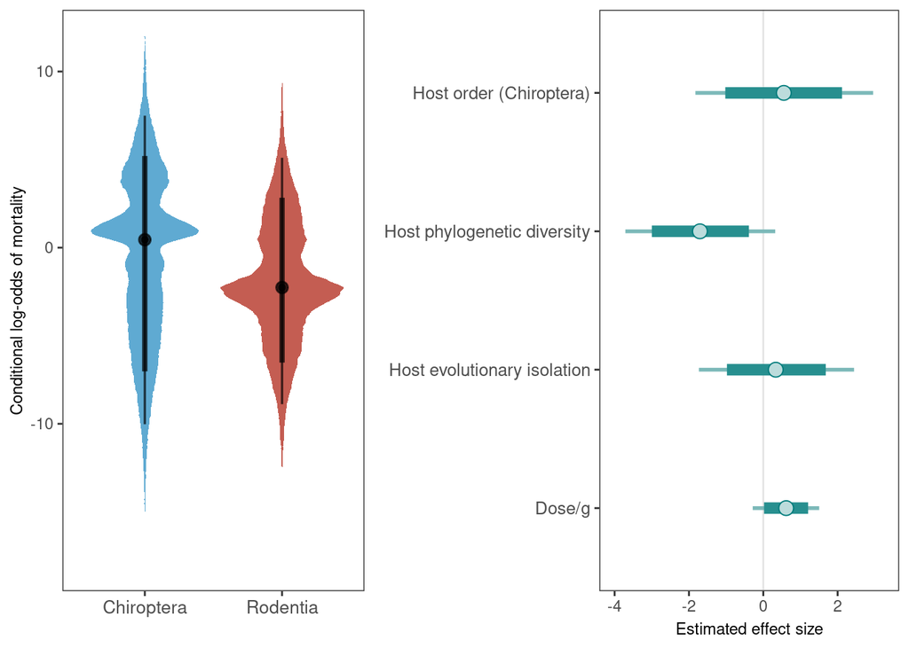

```r
p2 <- cond_eff_plot(model) + scale_y_continuous(lim=c(-18,12)) +
      ylab("Conditional log-odds of mortality") + xlab("") +
      theme(axis.title=element_text(size=9),axis.text.x=element_text(size=10),
            panel.grid.major = element_blank(),
            panel.grid.minor = element_blank())+
      scale_x_discrete(limits = c("Chiroptera","Rodentia"))

ar2 <- intervals_plot(model)

plot_grid(p2, ar2, align="h", rel_widths =c(0.7,1))
```

```r
# ggsave("../plots_tables/individual_level_mortality_homoHosts_comboplot.pdf", width=8, height=3)
```

Sample size: 773

### Severity (homologous hosts)

```r
dat_severity_homos <- dat_severity[dat_severity$Reservoir_match%in%1,]

if (!file.exists("../fit_models/indiv_severity_homoHosts.rds")) {

  severity_homos <- brm(severity_rank ~ Host_order  +
                      ses_pd + EvoIso +
                       Dose_mass + (1|Dose_unit) +
                      (1|PaperID) +
                      (1|Host_name) + (1|Virus_name) +
                      (1|Host_Upham) + (1|Virus_ICTV) +
                      (1|Route_type),
    data=dat_severity_homos, family=cumulative(probit),
    prior=custom_prior,
    iter=5000, thin=1, cov_ranef = list(Host_Upham = host_cov, Virus_ICTV=virus_cov),
    control=list(adapt_delta=0.98, max_treedepth=12), cores=4,
    save_pars=save_pars(all=TRUE))

  saveRDS(severity_homos, "../fit_models/indiv_severity_homoHosts.rds")

} else { severity_homos <- readRDS("../fit_models/indiv_severity_homoHosts.rds")}

model <- severity_homos
# summary(model, prob=0.9)

# save memory
rm(severity_homos)

# pp <- brms::posterior_predict(model)
# ppc_dens_overlay(y=model$data$Disease_YN, pp[1:500, ])

param_tab(model)
```

| Parameter | Effects | Mean | CI | CI_low | CI_high | Rhat | Group |
| --- | --- | --- | --- | --- | --- | --- | --- |
| b_Intercept[1] | fixed | 0.15 | 0.90 | -1.38 | 1.73 | 1.00 |  |
| b_Intercept[2] | fixed | 0.67 | 0.90 | -0.84 | 2.26 | 1.00 |  |
| b_Intercept[3] | fixed | 1.09 | 0.90 | -0.42 | 2.68 | 1.00 |  |
| b_Intercept[4] | fixed | 1.54 | 0.90 | 0.03 | 3.13 | 1.00 |  |
| b_Host_orderChiroptera | fixed | 0.62 | 0.90 | -1.11 | 2.42 | 1.00 |  |
| b_ses_pd | fixed | -0.81 | 0.90 | -1.79 | 0.17 | 1.00 |  |
| b_EvoIso | fixed | 0.07 | 0.90 | -0.80 | 0.93 | 1.00 |  |
| b_Dose_mass | fixed | 0.29 | 0.90 | -0.05 | 0.64 | 1.00 |  |
| sd_Dose_unit__Intercept | random | 1.19 | 0.90 | 0.14 | 2.41 | 1.00 | Dose_unit |
| sd_Host_name__Intercept | random | 1.86 | 0.90 | 1.26 | 2.59 | 1.00 | Host_name |
| sd_Host_Upham__Intercept | random | 0.67 | 0.90 | 0.05 | 1.66 | 1.00 | Host_Upham |
| sd_PaperID__Intercept | random | 1.26 | 0.90 | 0.85 | 1.76 | 1.00 | PaperID |
| sd_Route_type__Intercept | random | 1.02 | 0.90 | 0.56 | 1.69 | 1.00 | Route_type |
| sd_Virus_ICTV__Intercept | random | 0.57 | 0.90 | 0.05 | 1.39 | 1.00 | Virus_ICTV |
| sd_Virus_name__Intercept | random | 0.29 | 0.90 | 0.02 | 0.76 | 1.00 | Virus_name |

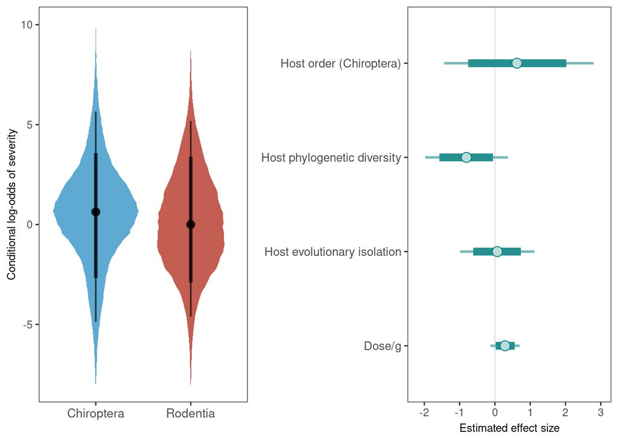

```r
p3 <- cond_eff_plot(model) + scale_y_continuous(lim=c(-8,10)) +
      ylab("Conditional log-odds of severity") + xlab("") +
      theme(axis.title=element_text(size=9),axis.text.x=element_text(size=10),
            panel.grid.major = element_blank(),
            panel.grid.minor = element_blank())+
      scale_x_discrete(limits = c("Chiroptera","Rodentia"))

ar3 <- intervals_plot(model)

plot_grid(p3, ar3, align="h", rel_widths =c(0.7,1))
```

```r
# ggsave("../plots_tables/individual_level_severity_homoHosts_comboplot.pdf", width=8, height=3)
```

Sample size: 1114

### Joint results plots (individual level homologous host models)

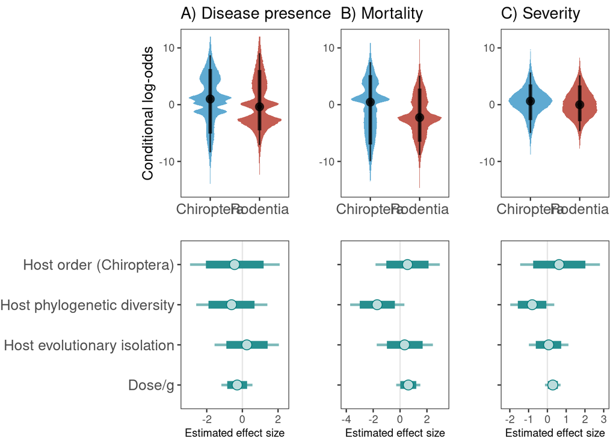

```r
## Joint plot
global_ylim <-  scale_y_continuous(lim=c(-15,12))
padding <- theme(plot.margin = unit(c(t=0, r=-3, b=0, l=0), "cm"))

joint_plot <- joint_conditionals_intervals(p1,p2,p3,global_ylim,padding,ar1,ar2,ar3)
```

```r
ggsave("../plots_tables/individual_level_conditionals_intervals_homoHosts.pdf", joint_plot, width=10.5, height=5.5)
```

## Joint results plots - species and individual models combined

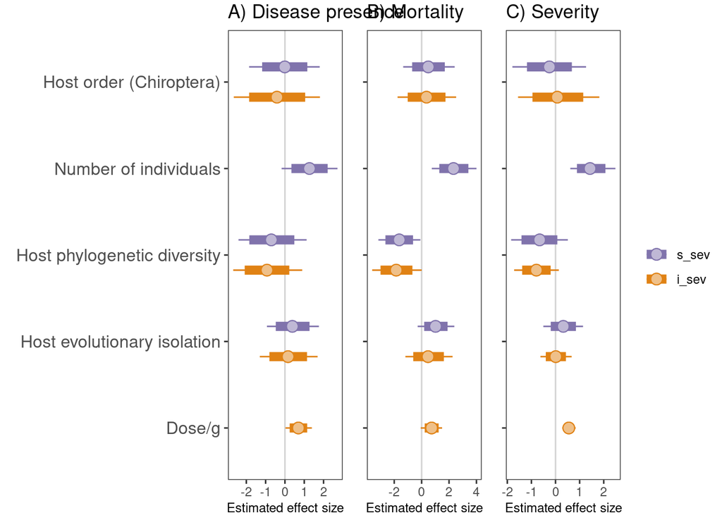

```r
s_dis <- readRDS("../fit_models/spec_disease_full.rds")
s_mort <- readRDS("../fit_models/spec_mort_full.rds")
s_sev <- readRDS("../fit_models/spec_severity_full.rds")

i_dis <- readRDS("../fit_models/indiv_disease_full.rds")
i_mort <- readRDS("../fit_models/indiv_mort_full.rds")
i_sev <- readRDS("../fit_models/indiv_severity_full.rds")


padding <- theme(plot.margin = unit(c(t=0.1, r=0.1, b=0, l=0), "cm"))

cp <-  egg::ggarrange(
        (compare_posteriors(s_dis, i_dis) + padding + theme(axis.text.y=element_text(size=12)) + ggtitle("A) Disease presence")),
        (compare_posteriors(s_mort, i_mort) + padding + theme(axis.text.y=element_blank()) + ggtitle("B) Mortality")),
        (compare_posteriors(s_sev, i_sev) + padding + theme(axis.text.y=element_blank(), legend.position = "right") + ggtitle("C) Severity")),
         ncol=3, padding=0.5)
```

```r
ggsave("../plots_tables/combined_species_individual_intervals.pdf", cp, width=11.5, height=3.5)
```

## Individual level models (no body mass correction)

### Presence of disease - full model with dose uncorrected for body mass

```r
if (!file.exists("../fit_models/indiv_disease_dose_amount.rds")) {

  disease_dose_amount <- brm(Disease_YN ~ Host_order +
                      ses_pd + EvoIso +
                       Dose_amount + (1|Dose_unit) +
                      (1|PaperID) +
                      (1|Host_name) + (1|Virus_name) +
                      (1|Host_Upham) + (1|Virus_ICTV) +
                      (1|Route_type),
    data=dat_dis, family=bernoulli(link = "logit"),
    prior=custom_prior,
    iter=5000, thin=1, cov_ranef = list(Host_Upham = host_cov, Virus_ICTV=virus_cov),
    control=list(adapt_delta=0.98, max_treedepth=12), cores=4,
    save_pars=save_pars(all=TRUE))

  saveRDS(disease_dose_amount, "../fit_models/indiv_disease_dose_amount.rds")

} else { disease_dose_amount <- readRDS("../fit_models/indiv_disease_dose_amount.rds")}

model <- disease_dose_amount
# summary(model, prob=0.9)

# save memory
rm(disease_full)

# pp <- brms::posterior_predict(model)
# ppc_dens_overlay(y=model$data$Disease_YN, pp[1:500, ])

param_tab(model)
```

| Parameter | Effects | Mean | CI | CI_low | CI_high | Rhat | Group |
| --- | --- | --- | --- | --- | --- | --- | --- |
| b_Intercept | fixed | 0.15 | 0.90 | -1.74 | 2.04 | 1.00 |  |
| b_Host_orderChiroptera | fixed | -0.34 | 0.90 | -2.20 | 1.53 | 1.00 |  |
| b_ses_pd | fixed | -0.88 | 0.90 | -2.38 | 0.60 | 1.00 |  |
| b_EvoIso | fixed | 0.19 | 0.90 | -1.01 | 1.44 | 1.00 |  |
| b_Dose_amount | fixed | 0.42 | 0.90 | -0.11 | 0.95 | 1.00 |  |
| sd_Dose_unit__Intercept | random | 1.23 | 0.90 | 0.15 | 2.50 | 1.00 | Dose_unit |
| sd_Host_name__Intercept | random | 2.72 | 0.90 | 2.00 | 3.51 | 1.00 | Host_name |
| sd_Host_Upham__Intercept | random | 0.85 | 0.90 | 0.07 | 2.08 | 1.00 | Host_Upham |
| sd_PaperID__Intercept | random | 3.53 | 0.90 | 2.76 | 4.37 | 1.00 | PaperID |
| sd_Route_type__Intercept | random | 1.86 | 0.90 | 1.21 | 2.65 | 1.00 | Route_type |
| sd_Virus_ICTV__Intercept | random | 1.05 | 0.90 | 0.10 | 2.32 | 1.00 | Virus_ICTV |
| sd_Virus_name__Intercept | random | 0.70 | 0.90 | 0.05 | 1.77 | 1.00 | Virus_name |

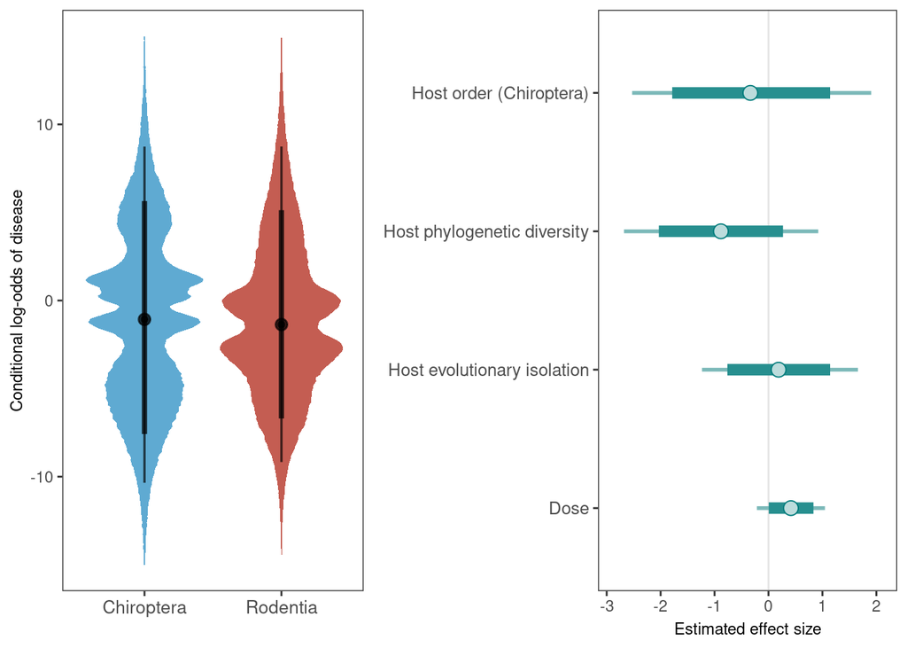

```r
p1 <- cond_eff_plot(model) + scale_y_continuous(lim=c(-15,15)) +
      ylab("Conditional log-odds of disease") + xlab("") +
      theme(axis.title=element_text(size=9),axis.text.x=element_text(size=10),
            panel.grid.major = element_blank(),
            panel.grid.minor = element_blank()) +
      scale_x_discrete(limits = c("Chiroptera","Rodentia"))

ar1 <- intervals_plot(model)

plot_grid(p1, ar1, align="h", rel_widths =c(0.7,1))
```

```r
# ggsave("../plots_tables/individual_level_disease_dose_amount_comboplot.pdf", width=8, height=3)
```

Sample size: 1999

### Mortality - full model with dose uncorrected for body mass

```r
if (!file.exists("../fit_models/indiv_mortality_dose_amount.rds")) {

  mort_dose_amount <- brm(Mortality_YN ~ Host_order +
                      ses_pd + EvoIso +
                       Dose_amount + (1|Dose_unit) +
                      (1|PaperID) +
                      (1|Host_name) + (1|Virus_name) +
                      (1|Host_Upham) + (1|Virus_ICTV) +
                      (1|Route_type),
    data=dat_mort, family=bernoulli(link = "logit"),
    prior=custom_prior,
    iter=5000, thin=1,
    cov_ranef = list(Host_Upham = host_cov, Virus_ICTV=virus_cov),
    control=list(adapt_delta=0.95, max_treedepth=12), cores=4,
    save_pars=save_pars(all=TRUE))

  saveRDS(mort_dose_amount, "../fit_models/indiv_mortality_dose_amount.rds")

} else { mort_dose_amount <- readRDS("../fit_models/indiv_mortality_dose_amount.rds")}

model <- mort_dose_amount
# summary(model, prob=0.9)

# save memory
rm(mort_dose_amount_mass)

# pp <- brms::posterior_predict(model)
# ppc_dens_overlay(y=model$data$Mortality_YN, pp[1:500, ])

param_tab(model)
```

| Parameter | Effects | Mean | CI | CI_low | CI_high | Rhat | Group |
| --- | --- | --- | --- | --- | --- | --- | --- |
| b_Intercept | fixed | -1.11 | 0.90 | -2.78 | 0.57 | 1.00 |  |
| b_Host_orderChiroptera | fixed | 0.47 | 0.90 | -1.31 | 2.28 | 1.00 |  |
| b_ses_pd | fixed | -1.84 | 0.90 | -3.35 | -0.31 | 1.00 |  |
| b_EvoIso | fixed | 0.51 | 0.90 | -0.93 | 2.01 | 1.00 |  |
| b_Dose_amount | fixed | 0.56 | 0.90 | -0.10 | 1.22 | 1.00 |  |
| sd_Dose_unit__Intercept | random | 1.23 | 0.90 | 0.20 | 2.34 | 1.00 | Dose_unit |
| sd_Host_name__Intercept | random | 1.86 | 0.90 | 1.21 | 2.57 | 1.00 | Host_name |
| sd_Host_Upham__Intercept | random | 0.77 | 0.90 | 0.06 | 1.85 | 1.00 | Host_Upham |
| sd_PaperID__Intercept | random | 2.39 | 0.90 | 1.64 | 3.23 | 1.00 | PaperID |
| sd_Route_type__Intercept | random | 1.70 | 0.90 | 1.04 | 2.56 | 1.00 | Route_type |
| sd_Virus_ICTV__Intercept | random | 0.73 | 0.90 | 0.05 | 1.81 | 1.00 | Virus_ICTV |
| sd_Virus_name__Intercept | random | 0.61 | 0.90 | 0.05 | 1.50 | 1.00 | Virus_name |

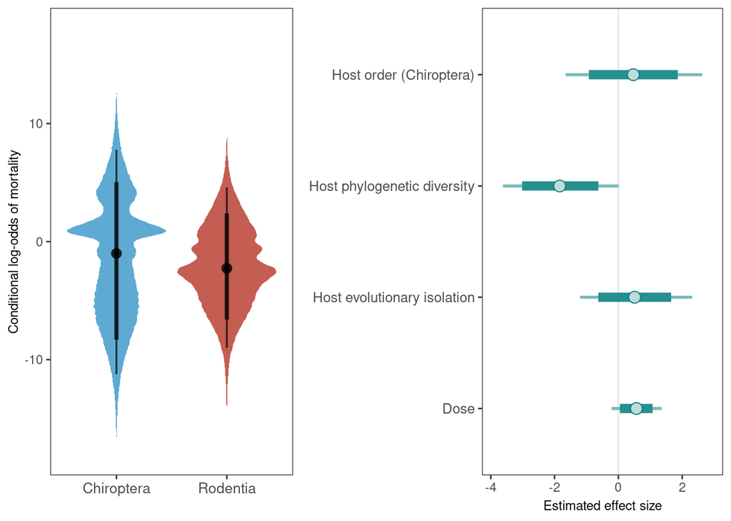

```r
p2 <- cond_eff_plot(model) + scale_y_continuous(lim=c(-18,18)) +
      ylab("Conditional log-odds of mortality") + xlab("") +
      theme(axis.title=element_text(size=9),axis.text.x=element_text(size=10),
            panel.grid.major = element_blank(),
            panel.grid.minor = element_blank())+
      scale_x_discrete(limits = c("Chiroptera","Rodentia"))

ar2 <- intervals_plot(model)

plot_grid(p2, ar2, align="h", rel_widths =c(0.7,1))
```

```r
# ggsave("../plots_tables/individual_level_mortality_dose_amount_comboplot.pdf", width=8, height=3)
```

Sample size: 1134